## Fairness and Accuracy of Residential Assessments in Cook County

By Jason Grotto  
Chicago Tribune  
June 1, 2017

## Introduction

The purpose of this analysis was to examine the fairness and accuracy of assessments and estimated market values produced by the Cook County Assessor’s Office (CCAO) across time, geographic location and property classification. Property tax assessments in Cook County have long been controversial, with accusations of unfairness and inaccuracies dating back to the late 1970s. To better understand the assessment system and to shed more light on the practices of the assessor’s office, the Tribune conducted sales ratio studies for residential properties over 14 tax years, using standards, methods and statistical tests recommended by the International Association of Assessing Officers. Results were calculated for all major classifications of non-incentive properties. For the time being, only results from the residential analysis are presented.

## Methodology

Sales ratio studies compare values derived from mass appraisals to actual arm's-length sales. For this analysis, assessment data from the CCAO were matched to real estate transfer declaration data (PTAX) from the Illinois Department of Revenue (IDOR) using Property Identification Numbers (PINs), the tax year of the assessment, and the deed year from the transfer declarations.

For each tax year, the CCAO's mass appraisals represent the assessed and market values of properties as of Jan. 1. Only sales that occurred within a year after that date were matched. Simple ratios were then calculated by dividing the CCAO's assessment and estimated market values by sale prices, minus the value of any personal property included in the purchase price. (See below for more information on sales selection and outlier trimming.)

For ratios calculated on market value, any ratio above 1 indicate that the mass appraisal overvalued a property; a result below 1 indicates the appraisal undervalued it. For assessment ratios, any assessment level above 0.10 for tax years 2009 through 2015 or above 0.16 for tax years 2002 through 2008 means the property was overassessed. Values below 0.10 or 0.16 means the properties were underassessed.

In Cook County, properties are reassessed every three years, depending on where in the county homes are located. To be as fair as possible, the stories that accompany this study cite only the results of sales ratio studies based on calendar years in which triennial reassessments took place. Also, though some data from 2002 were included in this analysis, the stories focus on the period from 2003 through 2015, in order to begin and end with the same triennial reassessment area. The city of Chicago was reassessed in both those years.

Because no mass appraisal model is perfect, these studies also measure how close the ratios are to the median ratio (the middle ratio when all ratios are sorted). Assessing experts favor the median over the average or weighted mean as a measure of central tendency, or the typical value in a distribution of numbers.

These statistics help test a bedrock principle of mass appraisals: uniformity. The assessor may not produce perfect results, but the values produced by the assessor should treat properties the same. Large variances in and around the median indicate flaws in assessments.

One of the most important statistics produced is called the coefficient of dispersion, or COD. The COD measures the distribution of the ratios relative to the median and produces a score that approximates the average percentage error. The International Association of Assessing Officers' Standard on Ratio Studies states CODs for residential properties should fall between 5 and 15. The COD measures random, or “horizontal,” dispersion among the ratios in that it does not account for factors that may have influenced the errors, such as property value.

Another important measure is price-related differential, or PRD. This statistic measures regressivity, or "vertical" inequities in a mass appraisal. Regressivity occurs when higher-priced properties are undervalued and lower-priced ones are overvalued. The IAAO standards say PRDs should fall between 0.98 and 1.03. Any number above 1.03 shows undervaluation of higher-priced properties and overvaluation of lower-priced ones.

To further examine regressivity, the Tribune also calculated the price-related bias, or PRB, for each township. This test uses regression analysis to measure regressivity in assessments. The analysis produces values known as coefficients, which quantify the relationship between property values and assessment ratios as well as the statistical significance of that relationship. In general, a coefficient will show how many percentage points a ratio will rise or fall relative to an increase in price. Assessing experts say coefficients that fall below -0.03 indicates regressivity, with a 3 percent decrease in the ratio for every doubling of value. Coefficients that fall below -0.05 should raise serious concerns -- as long as they are statistically significant (See The Fundamentals of Mass Appraisal, Appendix B).

PRB and PRD test assessment bias by measuring inaccuracies in relation to a specific cause, the value of property. Other biases also can explain inaccuracies, including the size of homes, their age, location, etc.

Together, the COD, PRD and PRB indicate how well the tax burden is distributed. Numbers that fall outside of the IAAO standards indicate the distribution of the tax burden is unfair.

In addition to the median, the study also calculated several other measures of central tendency, including means (or average), weighted means and the median absolute deviation, or MAD, which is another way of measuring how spread out ratios are from the median. All of these measures were calculated on a variety of stratifications based on geography, property classification and year.

### I. Sales selection and validation

Sales that qualify as arm's-length transactions were selected by using the IAAO's Standard on Ratio Studies and Standard on Verification and Adjustment of Sales as a guide.

Sales were selected using information reported in the PTAX-203 Illinois Real Estate Transfer Declaration forms, which are required for most transfers of real estate in Illinois. Information about the nature of the sales is included among the variables in the declarations data.

Sales in which the seller did not advertise that the property was for sale were eliminated, as were sales between relatives or other related parties as well as all foreclosure, auction, judicial and short sales. Sales involving financial institutions, pension funds or Real Estate Investment Trusts (REITs) were excluded. Sales that included significant physical changes such as remodeling or demolition were also eliminated from the pool because they are not considered the best representation of arm's-length transactions.

In addition, the analysis used only sales involving warranty and trustee's deeds, the most common deed types for residential property. Sales that involved other types of deeds -- including executor's, quit claim, beneficial, judicial, administrative, limited warranty and guardian deeds -- were thrown out.

Finally, any sale for less than \$10,000 was eliminated from the analysis, as extremely low-priced properties are difficult to value.

Of the roughly 1.5 million property transfers that took place in Cook County between 2002 and 2015, the analysis included 775,795 sales, or roughly 52 percent of all transfer declarations during the study period.

Here is a breakdown of the sales used by year:

```r
format(ddply(ptax_final_am, "DeedYear", function(x) c(count=nrow(x))), big.mark = ",")
```

| DeedYear | count |
| --- | --- |
| 2002 | 84,117 |
| 2003 | 84,770 |
| 2004 | 90,802 |
| 2005 | 91,986 |
| 2006 | 80,739 |
| 2007 | 60,008 |
| 2008 | 37,452 |
| 2009 | 31,037 |
| 2010 | 32,257 |
| 2011 | 26,270 |
| 2012 | 33,667 |
| 2013 | 46,131 |
| 2014 | 38,086 |
| 2015 | 38,473 |

This is a breakdown of the data used by deed type, where

- W = Warranty Deed
- T = Trustee's Deed

```r
format(arrange(ddply(ptax_final_am, "deed", function(x) c(count=nrow(x))), desc(count)), big.mark = ",")
```

| deed | count |
| --- | --- |
| W | 668,517 |
| T | 107,278 |

### II. CCAO assessment data

The CCAO provided the Tribune with data corresponding to each of the three "passes" used by the office to value property. The data sets include both market and assessed values for each segment of a property (land, buildings, additions, etc.).

The three passes relate to different valuations before and after the appeals process. The 1st Pass is the intitial assessment and estimated market value produced by the assessor's office. The 2nd Pass includes any changes made as a result of a successful appeal. The BOR Pass includes any changes made after successful appeals to the Cook County Board of Review, a three-member panel that certifies assessments. Any assessment that did not include an appeal was carried forward from 1st Pass through the BOR Pass.

To determine the total value the CCAO applied to each property, the segments must be combined and the individual segment values aggregated. Each segment has a pro rata share of the total market and assessed values for the parcel. The total market value in this data set (which comes off a mainframe) was repeated for each segment of a property, and a percentage of that value is assigned to each segment.

In some cases, the CCAO used replacement cost -- the cost to rebuild a building from scratch -- instead of the market value to calculate the assessed values.

As a check on the aggregated market values, the Tribune also produced a market value by dividing the CCAO assessed values by the assessment levels. In rare cases, these values did not match the aggregations of segment data because the CCAO removed value from parcels that received a homeowner improvement exemption or because the CCAO appears to have used something other than the segment data to determine the assessment value.

Prior to aggregating the CCAO data, parcels that matched the sales data were selected by comparing PINs and deed dates from sales to the CCAO data. Because all assessments and market valuations are based on the tax year as of Jan. 1, only sales that occurred within a year after the CCAO assessment date were matched. So, for example, in tax year 2015 only sales with deed dates in 2015 were matched to the assessment records.

Because of inaccurate PINs in the IDOR PTAX file, not all of the sales could be matched to the CCAO records. An examination of 100+ non-matches showed that PINs in the PTAX data did not match those from the actual deeds.

The 2nd Pass data had over 10,000 more mismatches than the BOR and 1st Pass data. This appears to be due to flaws in the CCAO's 2nd Pass data, which had hundreds of thousands of fewer records than both BOR and 1st Pass. Because of the smaller number of matches, the study did not attempt to measure the results for 2nd Pass.

Here is a breakdown of the number of matches by year:

```r
bor_yr <-ddply(bor, "taxyear", function(x) c(count=nrow(x)))
names(bor_yr)[2] <- "BOR Count"

pass1_yr <- ddply(pass1, "taxyear", function(x) c(count=nrow(x)))
names(pass1_yr)[2] <- "Pass1 Count"

cnt <- merge(bor_yr, pass1_yr, by = "taxyear")
format(cnt, big.mark=",")
```

| taxyear | BOR Count | Pass1 Count |
| --- | --- | --- |
| 2002 | 84,442 | 84,452 |
| 2003 | 88,365 | 88,350 |
| 2004 | 93,186 | 93,187 |
| 2005 | 94,926 | 94,981 |
| 2006 | 79,334 | 79,335 |
| 2007 | 62,079 | 62,066 |
| 2008 | 40,423 | 40,423 |
| 2009 | 37,427 | 37,429 |
| 2010 | 36,992 | 36,992 |
| 2011 | 32,889 | 32,889 |
| 2012 | 38,036 | 38,037 |
| 2013 | 52,080 | 52,083 |
| 2014 | 42,114 | 42,116 |
| 2015 | 41,763 | 41,763 |

### III. Geographic data

Because a goal of this analysis was to examine the fairness of assessments and market valuations by geographic location, a database of PIN locations going back to 2002 was developed.

Cook County often changes PINs, especially when properties are redeveloped, and the county says it does not keep track of these changes. Compounding that difficulty, the CCAO has virtually no GIS capabilities, although the CCAO was able to provide GIS maps of neighborhoods used in the assessment process.

To capture geographic location data for the sales that were matched to CCAO data, the newspaper obtained from the county's technology department GIS shape files of all Property Identification Numbers in the county for each study year, 2002 through 2015. Using QGIS software, the newspaper located PINs that had changed by matching PINs that did not show up in the 2015 maps to the 2014 maps. PINs that weren't in the 2014 maps were matched to the 2013 maps and so on.

After mappping the PINs as points, the newspaper used spatial joins to capture PINs inside neighborhoods, wards as well as state House and Senate districts.

In all, the Tribune compiled a database of more than 1.4 million PINs with GIS information attached, including township, neighborhood and ward as well as state House and state Senate districts.

Not every sale could be matched to that geographic database. For both the BOR Pass and 1st Pass matches to the sales data, 3,190 records did not match. The vast majority of the missing records (78 percent) are in tax years 2002 and 2008. Tax year 2002 accounts for just under half of the records that did not match.

After all the joins were complete, the study retained about 96 percent of the total number of sales for both BOR Pass and 1st Pass.

Here's a breakdown of the final record counts used in the study:

- BOR Pass = 748,605 (96.5 percent of all sales)
- 1st Pass = 748,642 (96.5 percent of all sales)

Here is a breakdown of the data by year for BOR Pass:

```r
bor_join <- ddply(bor_ptax_geo, "taxyear", function(x) c(count=nrow(x)))
names(bor_join)[2] <- "BOR Joins"

pass1_join <- ddply(pass1_ptax_geo, "taxyear", function(x) c(count=nrow(x)))
names(pass1_join)[2] <- "Pass 1 Joins"

join_cnts <- merge(bor_join, pass1_join, by = "taxyear")
format(join_cnts, big.mark = ",")
```

| taxyear | BOR Joins | Pass 1 Joins |
| --- | --- | --- |
| 2002 | 78,125 | 78,133 |
| 2003 | 82,710 | 82,694 |
| 2004 | 87,323 | 87,325 |
| 2005 | 89,438 | 89,491 |
| 2006 | 75,082 | 75,083 |
| 2007 | 57,581 | 57,568 |
| 2008 | 35,689 | 35,689 |
| 2009 | 30,610 | 30,610 |
| 2010 | 31,468 | 31,468 |
| 2011 | 25,773 | 25,773 |
| 2012 | 33,233 | 33,233 |
| 2013 | 45,567 | 45,567 |
| 2014 | 37,814 | 37,816 |
| 2015 | 38,192 | 38,192 |

### IV. Calculating ratios

Once the records were matched, ratios were calculated for both the market valuations and the assessments. In each case, the study divided the CCAO valuation -- estimated market or assessment -- by the sales price. The sales price used eliminates any personal property that is included in the sale. For example, if a high-rise makes money on cell phone antennas on the roof, the value of those antennas is eliminated from the sales price. Or if a homeowner sells furniture with a home, the price of the furniture is backed out of the final sale price. This is possible because transfer taxes on property are calculated on the value of real property only, not personal property. So the declarations capture the value minus personal property, known as the net nonsideration.

Before calculating the ratios, the study further narrowed the number of sales used by focusing only on the five types of major property classifications: residential, apartment buildings, commercial, industrial and vacant land. Other classifications of property, such as incentive properties, income-producing properties owned by non-profits and low-income residential housing were thrown out.

Here's a breakdown of the final BOR records by class, where:

- 2 = Residential
- 5 = Commercial/industrial
- 1 = Vacant land
- 3 = Apartment building (more than six units)

Here is a breakdown of final BOR records by class:

```r
format(arrange(ddply(bor_ptax_geo_final, "bor_majclass", function(x)
  c(count=nrow(x))),desc(count)), big.mark = ",")
```

| bor_majclass | count |
| --- | --- |
| 2 | 706,386 |
| 5 | 18,807 |
| 1 | 15,085 |
| 3 | 7,717 |

Here is a breakdown of BOR by class and year:

```r
table(bor_ptax_geo_final$taxyear, bor_ptax_geo_final$bor_majclass)
```

```
           1     2     3     5
  2002  2055 73180   905  1952
  2003  2171 77160  1125  2213
  2004  2061 81837  1137  2225
  2005  2182 83913  1036  2224
  2006  1904 70034  1001  2069
  2007  1288 53768   556  1889
  2008   697 33395   289  1265
  2009   375 29373   157   675
  2010   385 30038   188   827
  2011   381 24519   176   679
  2012   418 31757   238   799
  2013   575 43694   336   916
  2014   307 36624   295   559
  2015   286 37094   278   515
```

Here is a breakdown of final 1st Pass by class:

```r
format(arrange(ddply(pass1_ptax_geo_final, "p1_majclass", function(x)
  c(count=nrow(x))),desc(count)), big.mark = ",")
```

| p1_majclass | count |
| --- | --- |
| 2 | 706,281 |
| 5 | 19,032 |
| 1 | 14,989 |
| 3 | 7,879 |

Here is a breakdown of 1st Pass by class and year:

```r
table(pass1_ptax_geo_final$taxyear, pass1_ptax_geo_final$p1_majclass)
```

```
           1     2     3     5
  2002  2045 73082  1000  1986
  2003  2142 77108  1178  2238
  2004  2029 81819  1175  2257
  2005  2201 83914  1060  2250
  2006  1886 70036  1025  2083
  2007  1282 53728   566  1918
  2008   696 33401   284  1281
  2009   378 29380   155   677
  2010   381 30040   189   838
  2011   378 24524   175   682
  2012   410 31766   233   806
  2013   574 43725   303   929
  2014   303 36662   263   561
  2015   284 37096   273   526
```

### V. Trimming outliers

To ensure the statistics produced are valid, the studies followed steps in the IAAO's "Standards on Ratio Studies, Appendix B., Outlier Trimming Guidelines," to trim outliers. Specifically, the studies calculated the interquartile range (IQR) and established lower and upper boundaries by multiplying the IQR by 1.5. Because the focus of this analysis is residential properties, the review of outliers was based on residential properties only.

After trimming outliers, the BOR Pass study had a total record count for residential properties of 621,431. That's 84,955 fewer records.

Below is a breakdown of the records trimmed by year.

```r
format(trim_yr, big.mark = ',')
```

| taxyear | Before_trim | After_trim | diff | pct_diff | pct_total |
| --- | --- | --- | --- | --- | --- |
| 2002 | 73,180 | 67,096 | 6,084 | 9.07 | 0.86 |
| 2003 | 77,160 | 68,444 | 8,716 | 12.73 | 1.23 |
| 2004 | 81,837 | 73,094 | 8,743 | 11.96 | 1.24 |
| 2005 | 83,913 | 75,776 | 8,137 | 10.74 | 1.15 |
| 2006 | 70,034 | 61,082 | 8,952 | 14.66 | 1.27 |
| 2007 | 53,768 | 46,541 | 7,227 | 15.53 | 1.02 |
| 2008 | 33,395 | 27,751 | 5,644 | 20.34 | 0.80 |
| 2009 | 29,373 | 24,399 | 4,974 | 20.39 | 0.70 |
| 2010 | 30,038 | 24,479 | 5,559 | 22.71 | 0.79 |
| 2011 | 24,519 | 20,911 | 3,608 | 17.25 | 0.51 |
| 2012 | 31,757 | 27,007 | 4,750 | 17.59 | 0.67 |
| 2013 | 43,694 | 36,859 | 6,835 | 18.54 | 0.97 |
| 2014 | 36,624 | 33,695 | 2,929 | 8.69 | 0.41 |
| 2015 | 37,094 | 34,297 | 2,797 | 8.16 | 0.40 |

```r
format(trim_class, big.mark = ',')
```

| bor_class | diff | pct_total | pct_trim |
| --- | --- | --- | --- |
| 299 | 40,594 | 5.42 | 47.78 |
| 211 | 9,127 | 1.22 | 10.74 |
| 203 | 9,092 | 1.21 | 10.7 |
| 202 | 5,627 | 0.75 | 6.62 |
| 241 | 4,902 | 0.65 | 5.77 |
| 201 | 2,084 | 0.28 | 2.45 |
| 297 | 2,117 | 0.28 | 2.49 |
| 295 | 1,719 | 0.23 | 2.02 |
| 205 | 1,625 | 0.22 | 1.91 |
| 278 | 1,591 | 0.21 | 1.87 |
| 234 | 1,389 | 0.19 | 1.63 |
| 212 | 993 | 0.13 | 1.17 |
| 204 | 886 | 0.12 | 1.04 |
| 207 | 825 | 0.11 | 0.97 |
| 206 | 501 | 0.07 | 0.59 |
| 208 | 378 | 0.05 | 0.44 |
| 210 | 411 | 0.05 | 0.48 |
| 290 | 361 | 0.05 | 0.42 |
| 209 | 206 | 0.03 | 0.24 |
| 239 | 202 | 0.03 | 0.24 |
| 200 | 53 | 0.01 | 0.06 |
| 213 | 73 | 0.01 | 0.09 |
| 218 | 55 | 0.01 | 0.06 |
| 288 | 53 | 0.01 | 0.06 |
| 219 | 24 | 0.00 | 0.03 |
| 220 | 26 | 0.00 | 0.03 |
| 221 | 8 | 0.00 | 0.01 |
| 224 | 10 | 0.00 | 0.01 |
| 225 | 5 | 0.00 | 0.01 |
| 236 | 18 | 0.00 | 0.02 |
| 294 | 0 | 0.00 | 0 |

### VI. Data

Four datasets were used to conduct the sales ratio studies. The data can be matched by Property Identification Number, or PIN.

- **PTAX** - This data set from the Illinois Department of Revenue (IDOR) includes records from real estate transfer declarations. The data include variables that identify arm's-length transactions as well as sales price and property classification. It was culled from a larger data set of all property transfers between 2002 and 2015. See I. Sales selection and validation for information on sales selection and validation.
  - *Record count: 1,457,172*
- **BOR Detail** - This data set from the CCAO is a record of the Board of Review (BOR) certified values. These are the values used to calculate tax bills. The values come after appeals to the BOR and the CCAO. The data include values for each segment of the property (i.e. land, improvements, garage, etc.).
  - *Record count: 50,931,629*
- **Pass1 & Pass2 Detail** - These data sets are also from the CCAO. The Pass1 Detail file consists of the results of the assessor's mass appraisal models plus modifications made through "hand checks" and "machine changes." The CCAO has refused to provide information about how it uses hand checks and machine changes or how many properties are affected. The Pass2 Detail file reflects values that have been changed as a result of appeals made directly to the CCAO. Both files have the same structure as the BOR Detail file.
  - *Record count (Pass1): 51,189,407*
  - *Record count (Pass2): 50,727,375*

## Results

The results of this analysis include various measures of uniformity and bias as well as median assessment levels by year for residential properties in Cook County. Results are stratified by triennial area, townships within triennial areas, neighborhoods and property classification, such as big houses, small houses and apartment buildings.

The study also produced confidence intervals on the median market value ratios. Although 1st Pass ratios were examined, only BOR values are presented here.

### I. Median assessment levels

Median assessment levels were far below those required under county ordinances from 2002 to 2008 (Fig. 1). Assessment levels are based on a percentage of estimated market value. Prior to 2009, residential assessment levels were set at 16 percent. Commercial properties had an assessment level of 38 percent during that period while the level for industrial properties was 36 percent.

In September 2008, the Cook County Board of Commissioners passed an ordinance that led to sweeping changes in the assessment levels, collapsing a half-dozen or so levels for various classes into two: 10 percent for residential properties, vacant land and various incentive properties and 25 percent for business properties.

Results after 2008 show assessments became dramatically disparate depending in large part on geography and home value. Beginning in 2009, the triennial reassessment year for the City of Chicago, the CCAO began overassessing some townships while underassessing others (Fig. 2). A drill down into neighborhoods shows even more dramatic cases of disparities in assessment levels.

The CCAO improved the disparities in 2015. The reassessment of Chicago, for example, has assessment levels that are more uniform and fair, although they fail to reach assessment levels required in county ordinances. In some cases, specific neighborhoods appear to have assessment levels that are higher or lower than other parts of the county.

Certain townships in the south and west suburbs (triennial area 3) as well as the South and West Sides of Chicago tended to see higher assessments levels than other parts of the county, especially between 2009 and 2014 (Fig. 2 and Fig. 4). Townships in the north suburbs (triennial area 2) and more affluent areas of Chicago benefited from lower assessment levels (Fig. 2 and Fig. 3).

*(Dashed lines represent the legal assessment level. Note that in 2009, the legal assessment level dropped from 16 percent to 10 percent.)*

**All triennial areas -- Chicago, North, South/West**  
*Includes residential properties only*

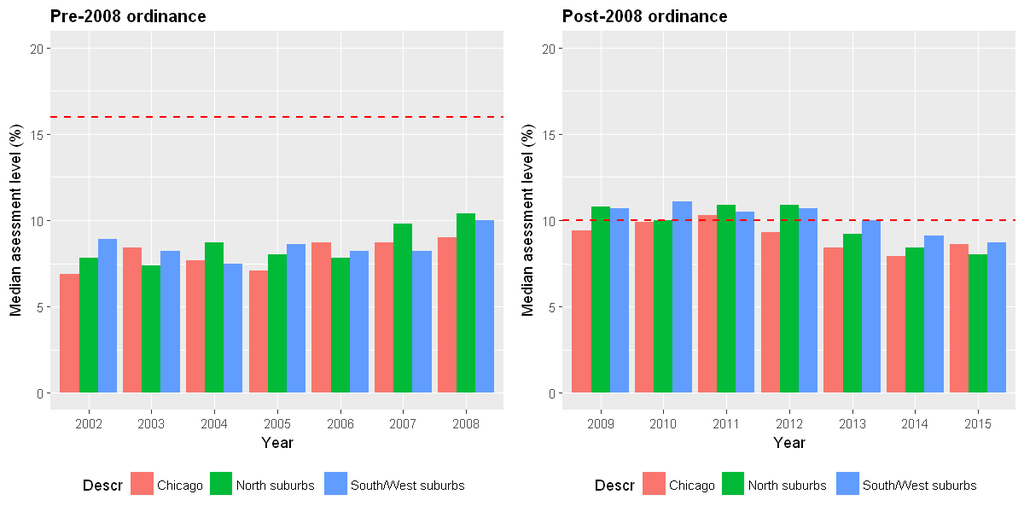

```r
# Fig. 1
source("C:/Users/jgrotto/Dropbox/PropTax/Data/Code/FINAL CODE/Results - All Tri Township Median Assessment.r")
```

**Triennial area 1 reassessments (City of Chicago)**

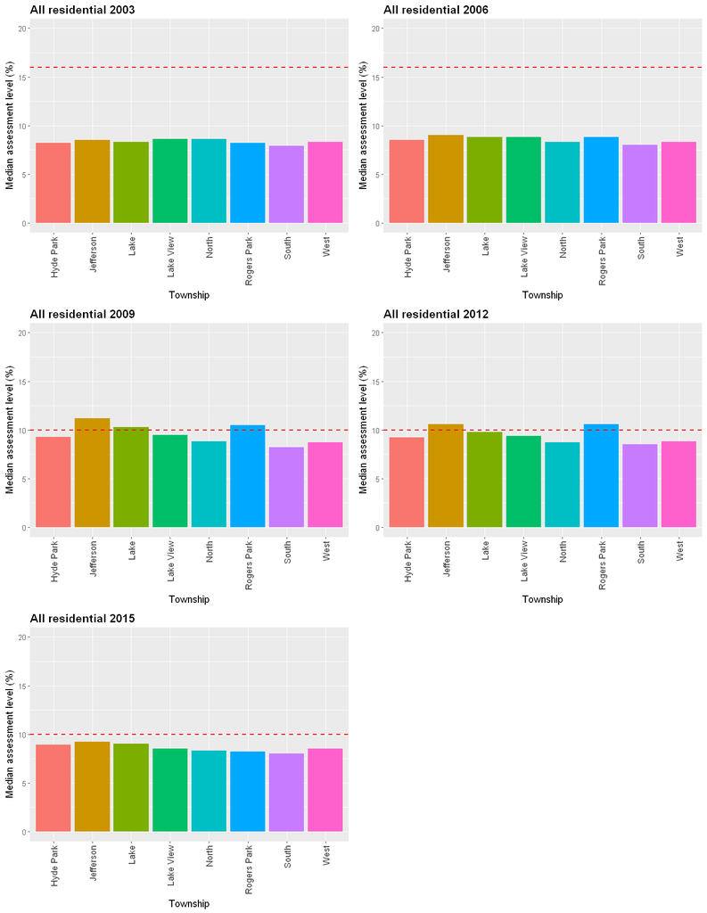

```r
# Fig. 2
source("C:/Users/jgrotto/Dropbox/PropTax/Data/Code/FINAL CODE/Results - Tri 1 Township Median Assessment.r")
```

**Triennial area 2 reassessments (north suburbs)**

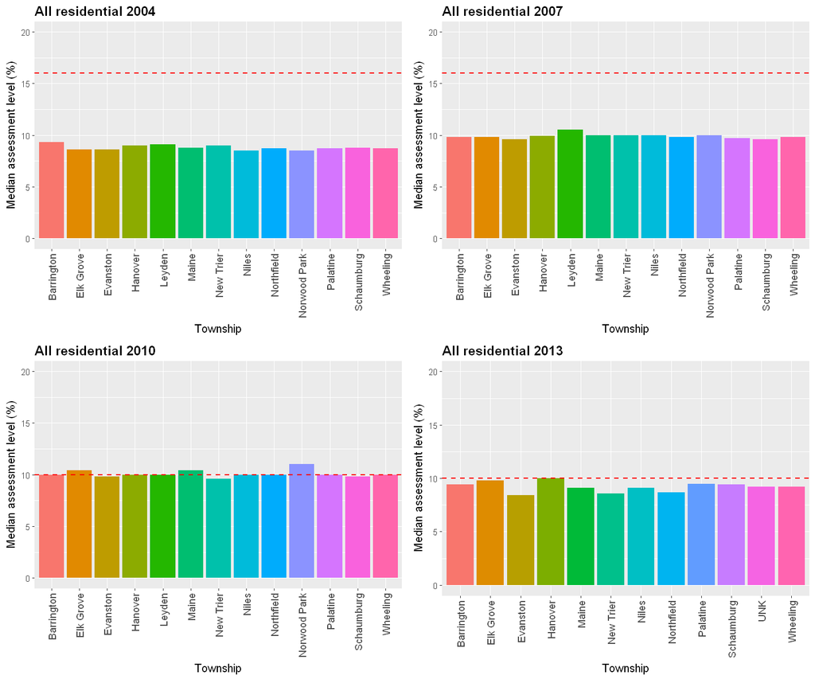

```r
# Fig. 3
source("C:/Users/jgrotto/Dropbox/PropTax/Data/Code/FINAL CODE/Results - Tri 2 Township Median Assessment.r")
```

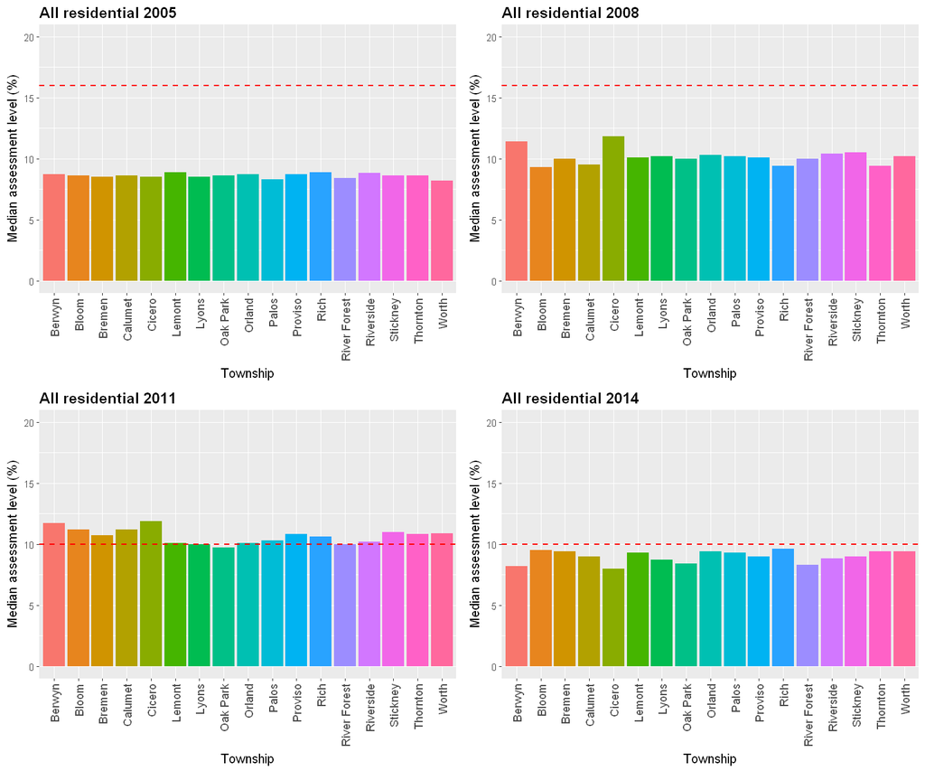

```r
# Fig. 4
source("C:/Users/jgrotto/Dropbox/PropTax/Data/Code/FINAL CODE/Results - Tri 3 Township Median Assessment.r")
```

### II. Uniformity

The analysis shows that during the past six years the county's assessment system has failed to meet uniformity standards set out by the IAAO. In general, residential assessments should have a coefficient of dispersion (COD) in the range of 5 to 15, a range that indicates average percentage error rates between 5 and 15 percent. Between 2008 and 2015, however, the county has far exceeded those standards, with some townships experiencing CODs of over 20.

*The shaded area represents the COD levels considered acceptable by IAAO.*

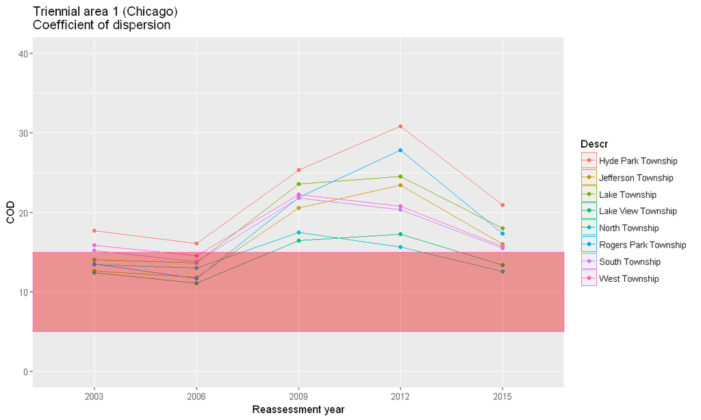

```r
# Fig. 5
source("C:/Users/jgrotto/Dropbox/PropTax/Data/Code/FINAL CODE/Results - Tri 1 COD by Year and Township.r")
COD_line
```

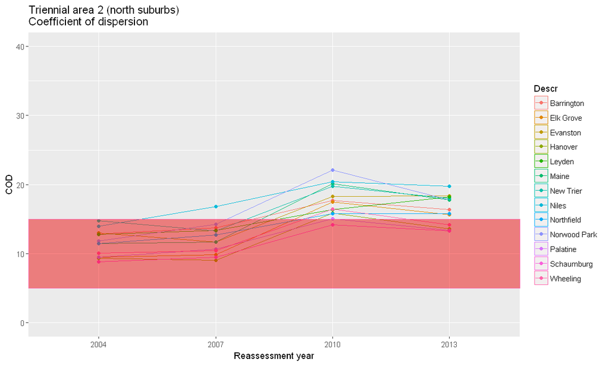

```r
# Fig. 6
source("C:/Users/jgrotto/Dropbox/PropTax/Data/Code/FINAL CODE/Results - Tri 2 COD by Year and Township.r")
COD_line
```

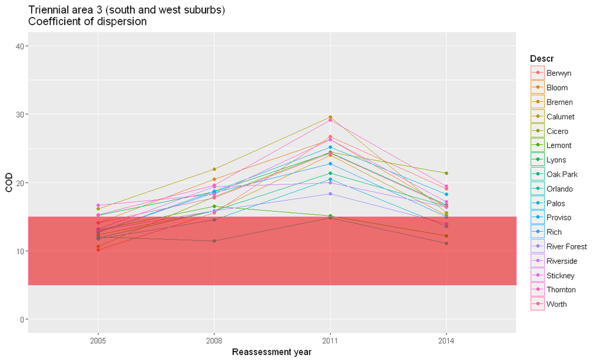

```r
# Fig. 7
source("C:/Users/jgrotto/Dropbox/PropTax/Data/Code/FINAL CODE/Results - Tri 3 COD by Year and Township.r")
COD_line
```

**Uniformity by classification**  
The classification of property also appears to affect measures of uniformity. Among the most glaring examples of this are condominiums, which had lower median assessment levels than other residential properties. Condos also tended to have lower COD and PRD scores than other types of properties.

In Chicago's West township, for example, the median assessment level in 2015 for all residential property was 8.5 percent (Table 1). The legal level is 10 percent. The COD was 16, which is just above what the IAAO considers acceptable. The PRD was 1.04, also just above the recommended level. When condos were excluded (Table 2), the median assessment level rose to 8.8, the COD rose to 20 and the PRD increased to 1.08 -- both exceed what would be considered fair. Condos examined alone had a COD of 13 and a PRD of 1.01, both within acceptable levels, while the median assessment level fell to 8.4 percent (Table 3).

The superior valuation of condos is important because condos are not valued using the assessor's regression models (Table 4). Instead, condo buildings are valued based on sales within the same buliding. In general, this approach appears to produce assessments that are more fair and accurate than the CCAO's regression models.

Below is a table of results for the 2015 reassessment of the City of Chicago (triennial area 1).

*Results for all residential properties, including condos.*

```r
# Table 1
source("C:/Users/jgrotto/Dropbox/PropTax/Data/Code/FINAL CODE/Results - uniform tables.R")
tri1_15
```

| Town | Township | N | mv_sum | netcon | median_sales | median_ass | mad | mean | weighted | prd | cod |
| --- | --- | --- | --- | --- | --- | --- | --- | --- | --- | --- | --- |
| 71 | Jefferson | 3344 | 940305075 | 1061925781 | 0.921 | 0.092 | 0.18 | 0.92 | 0.89 | 1.04 | 16 |
| 72 | Lake | 1510 | 259964190 | 292796439 | 0.905 | 0.090 | 0.22 | 0.91 | 0.89 | 1.03 | 18 |
| 70 | Hyde Park | 741 | 145447865 | 174261592 | 0.892 | 0.089 | 0.24 | 0.90 | 0.83 | 1.08 | 21 |
| 77 | West | 2948 | 1061410480 | 1287133970 | 0.851 | 0.085 | 0.17 | 0.85 | 0.82 | 1.04 | 16 |
| 73 | Lake View | 4059 | 1522709174 | 1834467589 | 0.846 | 0.085 | 0.13 | 0.85 | 0.83 | 1.02 | 13 |
| 74 | North | 2623 | 1247055572 | 1527088756 | 0.828 | 0.083 | 0.12 | 0.83 | 0.82 | 1.02 | 13 |
| 75 | Rogers Park | 453 | 96076640 | 115364766 | 0.817 | 0.082 | 0.17 | 0.83 | 0.83 | 1.00 | 17 |
| 76 | South | 1290 | 418229225 | 527561863 | 0.804 | 0.080 | 0.15 | 0.82 | 0.79 | 1.03 | 16 |

*Results for residential properties without condos.*

```r
# Table 2
tri1_15_noconods
```

| Town | Township | N | mv_sum | netcon | median_sales | median_ass | mad | mean | weighted | prd | cod |
| --- | --- | --- | --- | --- | --- | --- | --- | --- | --- | --- | --- |
| 76 | South | 247 | 88588128 | 96438526 | 0.967 | 0.097 | 0.15 | 0.94 | 0.92 | 1.02 | 15 |
| 71 | Jefferson | 2557 | 803885639 | 907160761 | 0.932 | 0.093 | 0.18 | 0.93 | 0.89 | 1.05 | 16 |
| 72 | Lake | 1478 | 256969346 | 289325639 | 0.907 | 0.090 | 0.22 | 0.91 | 0.89 | 1.03 | 18 |
| 70 | Hyde Park | 490 | 102942211 | 124889804 | 0.903 | 0.090 | 0.26 | 0.91 | 0.82 | 1.10 | 22 |
| 74 | North | 201 | 242878768 | 293861184 | 0.887 | 0.089 | 0.17 | 0.87 | 0.83 | 1.05 | 15 |
| 77 | West | 989 | 437977819 | 545622479 | 0.886 | 0.088 | 0.21 | 0.87 | 0.80 | 1.08 | 20 |
| 75 | Rogers Park | 166 | 56822254 | 66355459 | 0.879 | 0.088 | 0.18 | 0.90 | 0.86 | 1.05 | 16 |
| 73 | Lake View | 833 | 618229523 | 766261311 | 0.833 | 0.083 | 0.18 | 0.84 | 0.81 | 1.05 | 17 |

*Results limited to condos only.*

```r
# Table 3
tri1_15_conods
```

| Town | Township | N | mv_sum | netcon | median_sales | median_ass | mad | mean | weighted | prd | cod |
| --- | --- | --- | --- | --- | --- | --- | --- | --- | --- | --- | --- |
| 71 | Jefferson | 787 | 136419436 | 154765020 | 0.890 | 0.089 | 0.17 | 0.89 | 0.88 | 1.01 | 16 |
| 70 | Hyde Park | 251 | 42505654 | 49371788 | 0.869 | 0.087 | 0.20 | 0.88 | 0.86 | 1.03 | 19 |
| 72 | Lake | 32 | 2994844 | 3470800 | 0.849 | 0.085 | 0.15 | 0.88 | 0.86 | 1.02 | 16 |
| 73 | Lake View | 3226 | 904479651 | 1068206278 | 0.848 | 0.085 | 0.13 | 0.85 | 0.85 | 1.00 | 13 |
| 77 | West | 1959 | 623432661 | 741511491 | 0.842 | 0.084 | 0.14 | 0.85 | 0.84 | 1.01 | 13 |
| 74 | North | 2422 | 1004176804 | 1233227572 | 0.826 | 0.083 | 0.12 | 0.83 | 0.81 | 1.02 | 12 |
| 75 | Rogers Park | 287 | 39254386 | 49009307 | 0.787 | 0.079 | 0.16 | 0.79 | 0.80 | 0.99 | 17 |
| 76 | South | 1043 | 329641097 | 431123337 | 0.782 | 0.078 | 0.13 | 0.79 | 0.76 | 1.03 | 14 |

*Analysis of all classifications. The condo classification code is 299.*

```r
# Table 4
tri1_15_class
```

|  | bor_class | N | mv_sum | netcon | median_sales | median_ass | mad | mean | weighted | prd | cod |
| --- | --- | --- | --- | --- | --- | --- | --- | --- | --- | --- | --- |
| 1 | 212 | 94 | 42833753 | 50130000 | 1.000 | 0.100 | 0.31 | 0.95 | 0.85 | 1.11 | 21 |
| 2 | 211 | 1650 | 677015085 | 803514271 | 0.931 | 0.093 | 0.22 | 0.92 | 0.84 | 1.09 | 19 |
| 3 | 204 | 161 | 54944098 | 64064900 | 0.930 | 0.093 | 0.23 | 0.92 | 0.86 | 1.07 | 18 |
| 4 | 207 | 148 | 57790505 | 66205838 | 0.930 | 0.093 | 0.16 | 0.91 | 0.87 | 1.04 | 16 |
| 5 | 295 | 509 | 259760280 | 283068635 | 0.930 | 0.093 | 0.11 | 0.94 | 0.92 | 1.02 | 10 |
| 6 | 234 | 90 | 21728139 | 24020791 | 0.923 | 0.092 | 0.18 | 0.94 | 0.90 | 1.04 | 15 |
| 8 | 203 | 2083 | 476207353 | 549107145 | 0.903 | 0.090 | 0.20 | 0.91 | 0.87 | 1.04 | 17 |
| 9 | 205 | 619 | 206697388 | 242509929 | 0.894 | 0.089 | 0.17 | 0.90 | 0.85 | 1.05 | 16 |
| 10 | 202 | 733 | 130518809 | 156451292 | 0.878 | 0.088 | 0.22 | 0.88 | 0.83 | 1.06 | 20 |
| 11 | 210 | 109 | 50085051 | 61243288 | 0.862 | 0.086 | 0.23 | 0.87 | 0.82 | 1.06 | 21 |
| 12 | 278 | 456 | 386900805 | 477314869 | 0.845 | 0.084 | 0.19 | 0.84 | 0.81 | 1.03 | 18 |
| 13 | 206 | 231 | 154590116 | 201498815 | 0.843 | 0.084 | 0.20 | 0.84 | 0.77 | 1.10 | 19 |
| 14 | 208 | 26 | 50218735 | 63345356 | 0.843 | 0.084 | 0.22 | 0.80 | 0.79 | 1.01 | 18 |
| 15 | 299 | 10007 | 3082904533 | 3730685593 | 0.835 | 0.084 | 0.14 | 0.84 | 0.83 | 1.02 | 14 |

**Uniformity at the neighborhood level**  
While CODs and PRDs at the triennial area level have seen improvement of late, breaking the results down by neighborhood reveals continued problems with uniformity.

```r
# Table 5
neigh15_tri1
```

| Town | Township | NeighNum | N | mv_sum | netcon | median_sales | median_ass | mad | mean | weighted | prd | cod |
| --- | --- | --- | --- | --- | --- | --- | --- | --- | --- | --- | --- | --- |
| 70 | Hyde Park | 070 | 36 | 5605292 | 7904400 | 0.755 | 0.076 | 0.37 | 0.82 | 0.71 | 1.15 | 35 |
| 77 | West | 020 | 56 | 10044884 | 13349700 | 0.828 | 0.083 | 0.29 | 0.84 | 0.75 | 1.12 | 28 |
| 70 | Hyde Park | 010 | 116 | 22846260 | 29932150 | 0.796 | 0.080 | 0.29 | 0.82 | 0.76 | 1.07 | 26 |
| 70 | Hyde Park | 030 | 43 | 6860599 | 7682475 | 0.866 | 0.087 | 0.28 | 0.91 | 0.89 | 1.02 | 25 |
| 72 | Lake | 274 | 38 | 7856948 | 9632900 | 0.837 | 0.084 | 0.27 | 0.85 | 0.82 | 1.04 | 22 |
| 73 | Lake View | 011 | 76 | 18647817 | 21655900 | 0.853 | 0.085 | 0.22 | 0.89 | 0.86 | 1.04 | 22 |
| 77 | West | 151 | 30 | 10466878 | 15703890 | 0.766 | 0.077 | 0.16 | 0.76 | 0.67 | 1.13 | 22 |
| 72 | Lake | 200 | 107 | 14348657 | 17436280 | 0.838 | 0.084 | 0.25 | 0.86 | 0.82 | 1.04 | 21 |
| 77 | West | 141 | 57 | 13130036 | 15598604 | 0.906 | 0.091 | 0.21 | 0.90 | 0.84 | 1.07 | 21 |

The same can be said of the triennial area covering the south and west suburbs.

```r
# Table 6
neigh14_Tri3
```

| Town | Township | NeighNum | N | mv_sum | netcon | median_sales | median_ass | mad | mean | weighted | prd | cod |
| --- | --- | --- | --- | --- | --- | --- | --- | --- | --- | --- | --- | --- |
| 11 | Berwyn | 020 | 47 | 5925877 | 7869125 | 0.724 | 0.072 | 0.18 | 0.82 | 0.75 | 1.09 | 26 |
| 37 | Thornton | 033 | 46 | 4305936 | 5356555 | 0.790 | 0.078 | 0.25 | 0.84 | 0.80 | 1.04 | 25 |
| 13 | Bremen | 240 | 34 | 2855684 | 3960760 | 0.693 | 0.069 | 0.12 | 0.76 | 0.72 | 1.06 | 23 |
| 15 | Cicero | 080 | 34 | 3662544 | 4436750 | 0.880 | 0.088 | 0.30 | 0.88 | 0.83 | 1.06 | 23 |
| 31 | Proviso | 092 | 47 | 8472909 | 10150150 | 0.830 | 0.083 | 0.19 | 0.89 | 0.83 | 1.07 | 23 |
| 13 | Bremen | 260 | 31 | 2570088 | 3385596 | 0.748 | 0.075 | 0.16 | 0.81 | 0.76 | 1.07 | 22 |
| 15 | Cicero | 030 | 72 | 7662568 | 10373900 | 0.716 | 0.072 | 0.17 | 0.78 | 0.74 | 1.05 | 22 |
| 31 | Proviso | 020 | 53 | 5181260 | 6701200 | 0.739 | 0.074 | 0.17 | 0.82 | 0.77 | 1.06 | 22 |
| 11 | Berwyn | 050 | 40 | 5579402 | 7184200 | 0.790 | 0.078 | 0.20 | 0.83 | 0.78 | 1.07 | 21 |
| 15 | Cicero | 065 | 30 | 3383687 | 4162299 | 0.772 | 0.076 | 0.16 | 0.86 | 0.81 | 1.06 | 21 |
| 21 | Lyons | 012 | 61 | 31557834 | 42301766 | 0.784 | 0.078 | 0.24 | 0.81 | 0.75 | 1.09 | 21 |
| 31 | Proviso | 032 | 25 | 2499048 | 2985500 | 0.899 | 0.090 | 0.23 | 0.88 | 0.84 | 1.06 | 21 |
| 37 | Thornton | 061 | 33 | 2589508 | 2793392 | 0.997 | 0.100 | 0.26 | 0.97 | 0.93 | 1.04 | 21 |
| 37 | Thornton | 053 | 43 | 4517985 | 5178191 | 0.895 | 0.090 | 0.29 | 0.91 | 0.87 | 1.04 | 21 |
| 39 | Worth | 310 | 26 | 3343903 | 3941480 | 0.852 | 0.085 | 0.21 | 0.91 | 0.85 | 1.07 | 21 |

### III. Regressivity

**Price-related differential**  
Between 2008 and 2015, Cook County has experienced extreme swings in PRD, with scores falling well outside what is considered acceptable by industry standards. The IAAO says a PRD above 1.03 indicates that lower-priced homes are overvalued while higher-priced ones are undervalued. In Cook County, PRDs in some townships have been as high as 1.15.

*The shaded area represents the PRD levels considered acceptable by IAAO.*

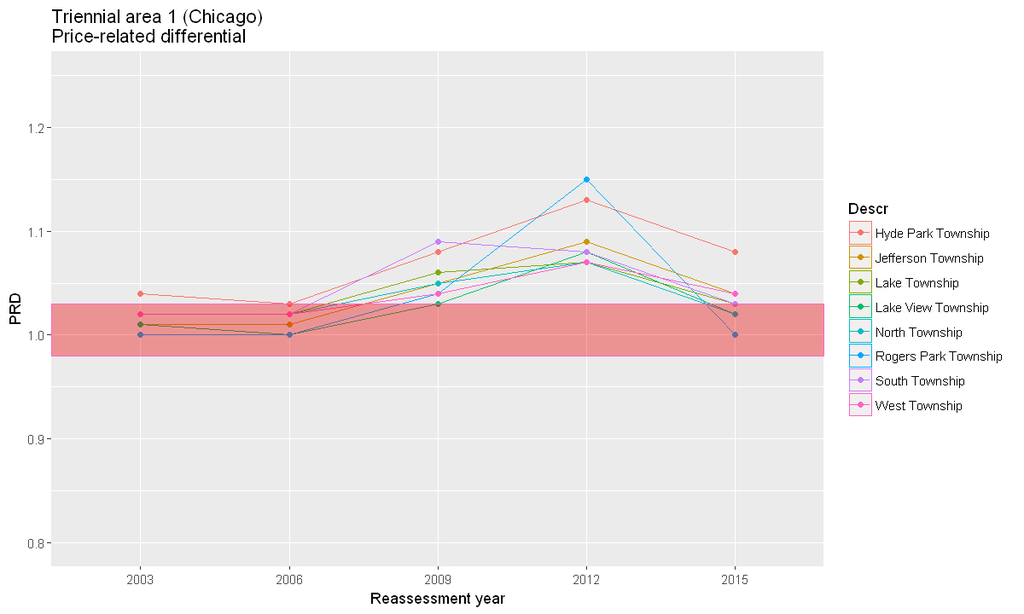

```r
# Fig. 8
source("C:/Users/jgrotto/Dropbox/PropTax/Data/Code/FINAL CODE/Results - Tri 1 PRD by Year and Township.r")
PRD_line
```

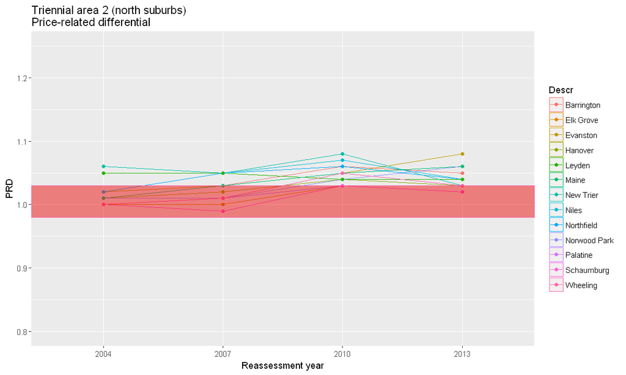

```r
# Fig. 9
source("C:/Users/jgrotto/Dropbox/PropTax/Data/Code/FINAL CODE/Results - Tri 2 PRD by Year and Township.r")
PRD_line
```

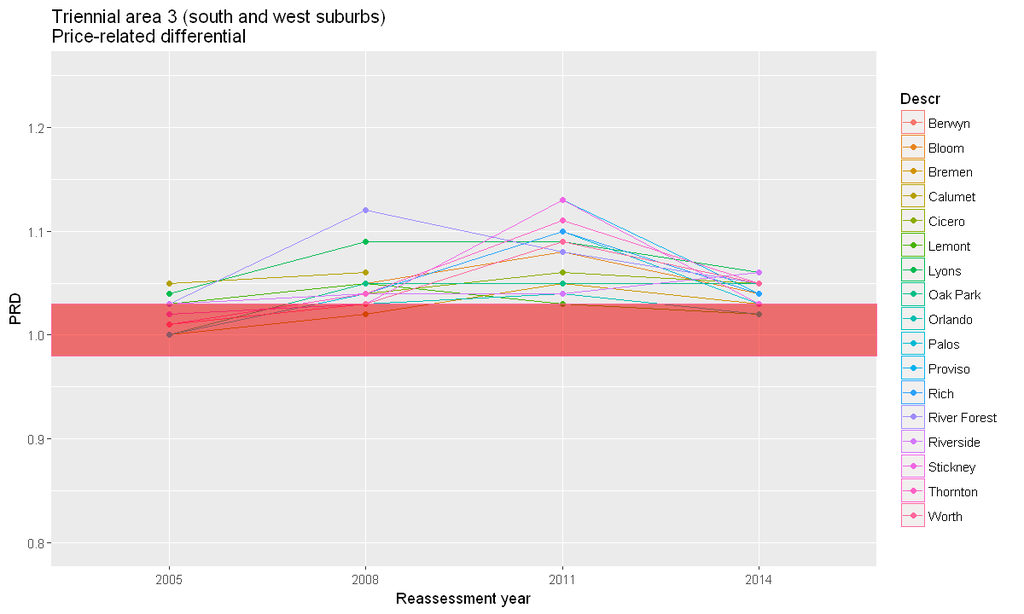

```r
# Fig. 10
source("C:/Users/jgrotto/Dropbox/PropTax/Data/Code/FINAL CODE/Results - Tri 3 PRD by Year and Township.r")
PRD_line
```

**Price-related bias**  
The results from the PRB analysis show that regressivity has been a significant problem, with coefficients as low as -0.072 in the City of Chicago in 2012 (Table 7), more than double what experts say is acceptable. The north and south/west suburban triennial areas also had high levels of regressivity, according to PRB scores. The worst regressivity measure occurred in the south and west suburban reassessment of 2011, where the coefficient was -0.074 (Table 8).

**City of Chicago, 2012 reassessment year**

```r
source("C:/Users/jgrotto/Dropbox/PropTax/Data/Code/FINAL CODE/PRB measures2.R")
```

```r
# Table 7 -- Below are full statistical results. Coefficient is under Log_val and Estimate.
summary(prb_cnty12_1)
```

```
Call:
lm(formula = PRB_pctdiff ~ Log_val, data = res12[which(res12$TRI ==
    "1"), ])

Residuals:
     Min       1Q   Median       3Q      Max
-1.03130 -0.15380 -0.01942  0.12817  1.06642

Coefficients:
             Estimate Std. Error t value Pr(>|t|)
(Intercept)  1.274391   0.044843   28.42   <2e-16 ***
Log_val     -0.072898   0.002484  -29.34   <2e-16 ***
---
Signif. codes:  0 '***' 0.001 '**' 0.01 '*' 0.05 '.' 0.1 ' ' 1

Residual standard error: 0.2732 on 12579 degrees of freedom
Multiple R-squared:  0.06407,	Adjusted R-squared:  0.06399
F-statistic: 861.1 on 1 and 12579 DF,  p-value: < 2.2e-16
```

```r
# Table 8 -- Below are full statistical results. Coefficient is under Log_val and Estimate.
summary(prb_cnty11_3)
```

```
Call:
lm(formula = PRB_pctdiff ~ Log_val, data = res11[which(res11$TRI ==
    "3"), ])

Residuals:
     Min       1Q   Median       3Q      Max
-1.12736 -0.15652 -0.01456  0.16490  1.00186

Coefficients:
             Estimate Std. Error t value Pr(>|t|)
(Intercept)  1.322010   0.088648   14.91   <2e-16 ***
Log_val     -0.074337   0.005104  -14.56   <2e-16 ***
---
Signif. codes:  0 '***' 0.001 '**' 0.01 '*' 0.05 '.' 0.1 ' ' 1

Residual standard error: 0.3219 on 4853 degrees of freedom
Multiple R-squared:  0.04188,	Adjusted R-squared:  0.04169
F-statistic: 212.1 on 1 and 4853 DF,  p-value: < 2.2e-16
```

The assessor's office reduced the amount of regressivity in the most recent reassessment for the city, in 2015. In fact, PRB scores for the city as a whole were in line with industry standards in 2015.

**(All of the coefficients produced below are statistically significant within p-values of at least .05.)**

```r
# Table 9 -- City of Chicago reassessment years, with condos
results_cnty_1
```

| tri1_year | prb_cnty_1 |
| --- | --- |
| 2015 | -0.01533379 |
| 2012 | -0.07289758 |
| 2009 | -0.03265732 |

```r
# Table 10 -- City of Chicago reassessment years, without condos
results_cnty_1_nocondo
```

| tri1_year | prb_cnty_1_nocondo |
| --- | --- |
| 2015 | -0.05405375 |
| 2012 | -0.08902271 |
| 2009 | -0.05990601 |

What’s more, PRB scores for individual townships in Chicago varied widely, showing regressivity remained a serious problem even as improvements were made. For example, Hyde Park township had a PRB score of -0.052 and the West township had a score of -0.034, even when condos are included in the analysis.

```r
# Table 11 -- City of Chicago townships, with condos
results_cnty_1_t
```

| townships_1 | prb_cnty_1_t |
| --- | --- |
| Hyde Park | -0.052649697 |
| Jefferson | -0.026097755 |
| Lake | -0.013639436 |
| Lake View | 0.006180640 |
| North | 0.001014958 |
| Rogers Park | 0.056849799 |
| South | 0.008077056 |
| West | -0.034168358 |

Regressivity became even more acute when condos were removed from the analysis. For example, the West township PRB score jumped to -0.083 while Hyde Park increased to -0.073. Townships that had good PRB scores with condos also became highly regressive when condos were removed. PRB scores for Jefferson township, for example, increased from -0.026 to -0.11, nearly four times higher than what is considered acceptable.

```r
# Table 12
results_cnty_1_nocondo_t
```

| townships_1_nocondo | prb_cnty_1_nocondo_t |
| --- | --- |
| Hyde Park | -0.07372864 |
| Jefferson | -0.11092830 |
| Lake | -0.01674362 |
| Lake View | -0.08337024 |
| North | -0.07569965 |
| Rogers Park | -0.15479028 |
| South | -0.01394570 |
| West | -0.08316915 |

## Discussion

One explanation for the decline in accuracy and the rise in regressivity is the 2008 housing market collapse. Because the assessor's office uses regression models that rely on the previous five years of data and did not adjust its methods in light of the housing crash, subsequent assessments did not reflect rapidly declining housing values. This problem is particularly evident in the stark differences between results for single-family homes, which are valued with regression models, and condominiums, which are not.

Issues with uniformity and regressivity can also be traced back to changes made in 2009 to county ordinances governing assessment levels. Prior to that law change, the CCAO routinely undervalued properties. Yet the values were uniform and there was very little regressivity. After the change, however, uniformity suffered and regressivity took hold.

One of the most glaring examples of this can be found in examining the Hyde Park township. Below are two scatter plots, one from the 2006 triennial reassessment (prior to the ordinance change) and the other from the 2009 (after the change).

Each dot represents the sales ratio for a single property. The dotted red line marks a sales ratio of one, representing a completely accurate valuation. Anything above one means the property was overvalued while results below one indicate the property was undervalued. The solid blue line is a regression line. If the line is flat, it means there is very little or no regressivity. A line that slopes downward from left to right, however, indicate that low-priced homes were overvalued while high-priced homes were undervalued.

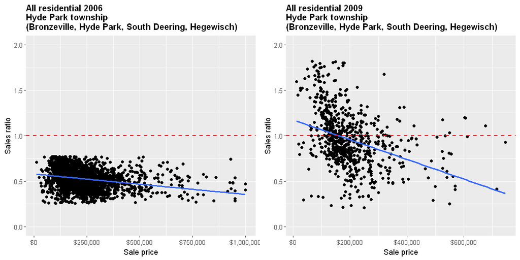

```r
# Fig. 11
source("C:/Users/jgrotto/Dropbox/PropTax/Data/Code/FINAL CODE/Results - NEW Tri 1 - Hyde Park - Township analysis by year.r")
```

Even though CCAO improved uniformity in the most recent reassessment, there were still serious issues at the neighborhood level. For example, here are six of the same types of scatter plots for Chicago's 2015 reassessment. They show that discrepancies remained between townships in the left-hand column and those in the right-hand column.

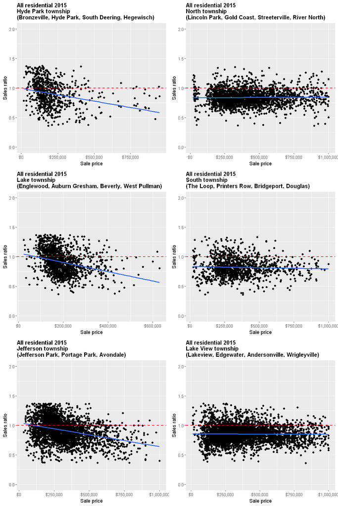

```r
# Fig. 12
source("C:/Users/jgrotto/Dropbox/PropTax/Data/Code/FINAL CODE/Results - NEW  Tri 1 Township Analysis.r")
```

Even within the same township, there appear to be continued issues with uniformity and regressivity. Take the West township in Chicago. A comparison of scatter plots showing sales ratios in Wicker Park and a similar number of sales in the less affluent neighborhoods of Austin, West Humboldt Park, Garfield Park, North Lawndale and Little Village illustrates the problem.

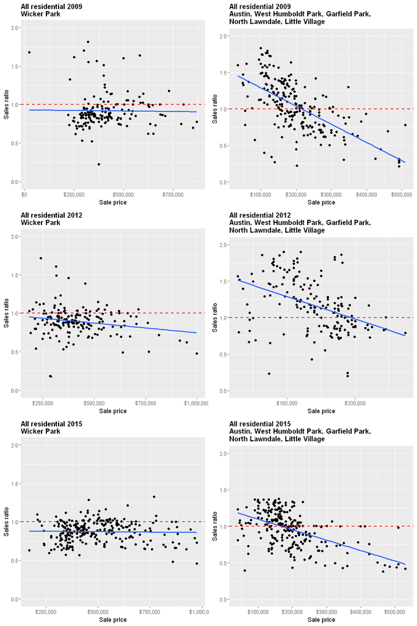

```r
# Fig. 13
source("C:/Users/jgrotto/Dropbox/PropTax/Data/Code/FINAL CODE/Results - New Tri 1 West Township Analysis.r")
```

The scatter plots below illustrate how the value of homes affects the fairness of assessments. The first plot depicts the far south suburb of Thornton, where values in the sample range from between \$20,000 to about \$250,000. The second plot depicts the more affluent New Trier township in the far north suburbs, where values in the sample range from \$170,000 to nearly \$4.5 million. The turquoise dots are small houses (classes 202 and 203) while the salmon-colored dots are big homes (classes 206, 208, 209 and 278).

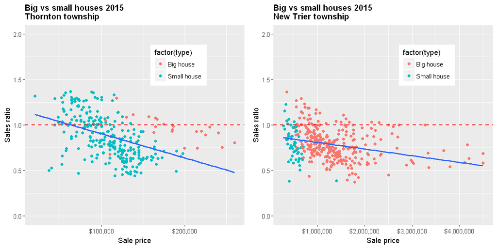

```r
# Fig. 14
source("C:/Users/jgrotto/Dropbox/PropTax/Data/Code/FINAL CODE/Results - Tri 2 and 3 Big Homes vs Small Homes.r")
```

## Appendix

### Full statistical results

Below are tables that include all the statistics calculated in the study by township for all years.

**2015** **Tri Area 1 (City of Chicago)**

```r
arrange(ddply(res15[which(res15$TRI == "1"),], "Town", function(y)
  c(N =  nrow(y),
  mv_sum = sum(y$bor_val_final),
  netcon = sum(y$NetConsideration),
  median_sales = round(median(y$bor_valratio), 3),
  median_ass = round(median(y$bor_assratio), 3),
  mad = round(mad(y$bor_valratio), 2),
  mean = round(mean(y$bor_valratio), 2),
  weighted = round(weighted.mean(y$bor_valratio, y$NetConsideration), 2),
  prd = round(mean(y$bor_valratio/weighted.mean(y$bor_valratio, y$NetConsideration)), 2),
  cod = round(((sum(abs((median(y$bor_valratio) - y$bor_valratio)))/nrow(y))/median(y$bor_valratio)) * 100)
)), desc(median_sales))
```

| Town | N | mv_sum | netcon | median_sales | median_ass | mad | mean | weighted | prd | cod |
| --- | --- | --- | --- | --- | --- | --- | --- | --- | --- | --- |
| 71 | 3344 | 940305075 | 1061925781 | 0.921 | 0.092 | 0.18 | 0.92 | 0.89 | 1.04 | 16 |
| 72 | 1510 | 259964190 | 292796439 | 0.905 | 0.090 | 0.22 | 0.91 | 0.89 | 1.03 | 18 |
| 70 | 741 | 145447865 | 174261592 | 0.892 | 0.089 | 0.24 | 0.90 | 0.83 | 1.08 | 21 |
| 77 | 2948 | 1061410480 | 1287133970 | 0.851 | 0.085 | 0.17 | 0.85 | 0.82 | 1.04 | 16 |
| 73 | 4059 | 1522709174 | 1834467589 | 0.846 | 0.085 | 0.13 | 0.85 | 0.83 | 1.02 | 13 |
| 74 | 2623 | 1247055572 | 1527088756 | 0.828 | 0.083 | 0.12 | 0.83 | 0.82 | 1.02 | 13 |
| 75 | 453 | 96076640 | 115364766 | 0.817 | 0.082 | 0.17 | 0.83 | 0.83 | 1.00 | 17 |
| 76 | 1290 | 418229225 | 527561863 | 0.804 | 0.080 | 0.15 | 0.82 | 0.79 | 1.03 | 16 |

**Tri Area 2 (north suburbs)**

```r
arrange(ddply(res15[which(res15$TRI == "2"),], "Town", function(y)
  c(N =  nrow(y),
  mv_sum = sum(y$bor_val_final),
  netcon = sum(y$NetConsideration),
  median_sales = round(median(y$bor_valratio), 3),
  median_ass = round(median(y$bor_assratio), 3),
  mad = round(mad(y$bor_valratio), 2),
  mean = round(mean(y$bor_valratio), 2),
  weighted = round(weighted.mean(y$bor_valratio, y$NetConsideration), 2),
  prd = round(mean(y$bor_valratio/weighted.mean(y$bor_valratio, y$NetConsideration)), 2),
  cod = round(((sum(abs((median(y$bor_valratio) - y$bor_valratio)))/nrow(y))/median(y$bor_valratio)) * 100)
)), desc(median_sales))
```

| Town | N | mv_sum | netcon | median_sales | median_ass | mad | mean | weighted | prd | cod |
| --- | --- | --- | --- | --- | --- | --- | --- | --- | --- | --- |
| 10 | 156 | 81423844 | 92606498 | 0.904 | 0.090 | 0.16 | 0.91 | 0.88 | 1.04 | 15 |
| 18 | 754 | 137042243 | 156042996 | 0.881 | 0.088 | 0.13 | 0.88 | 0.88 | 1.01 | 13 |
| 20 | 474 | 84347843 | 99263593 | 0.877 | 0.088 | 0.18 | 0.88 | 0.85 | 1.04 | 17 |
| 29 | 1018 | 259240346 | 302169362 | 0.848 | 0.085 | 0.15 | 0.85 | 0.86 | 0.99 | 14 |
| 16 | 673 | 135741951 | 162588421 | 0.834 | 0.083 | 0.16 | 0.83 | 0.83 | 1.00 | 15 |
| 35 | 1124 | 211450121 | 256736526 | 0.812 | 0.081 | 0.13 | 0.82 | 0.82 | 1.00 | 14 |
| 26 | 27 | 9087620 | 12053200 | 0.802 | 0.080 | 0.15 | 0.81 | 0.75 | 1.08 | 17 |
| 24 | 853 | 201889155 | 261213879 | 0.787 | 0.078 | 0.18 | 0.79 | 0.77 | 1.02 | 18 |
| 22 | 1111 | 265540708 | 339255844 | 0.785 | 0.078 | 0.16 | 0.80 | 0.78 | 1.02 | 17 |
| 38 | 1466 | 331037765 | 422513819 | 0.782 | 0.078 | 0.14 | 0.79 | 0.78 | 1.01 | 15 |
| 17 | 652 | 208034914 | 278568218 | 0.775 | 0.077 | 0.15 | 0.79 | 0.75 | 1.06 | 17 |
| 23 | 680 | 491061837 | 653813624 | 0.767 | 0.076 | 0.16 | 0.78 | 0.75 | 1.03 | 17 |
| 25 | 950 | 382578519 | 510842973 | 0.754 | 0.075 | 0.15 | 0.76 | 0.75 | 1.02 | 17 |

**Tri Area 3 (south and west suburbs)**

```r
arrange(ddply(res15[which(res15$TRI == "3"),], "Town", function(y)
  c(N =  nrow(y),
  mv_sum = sum(y$bor_val_final),
  netcon = sum(y$NetConsideration),
  median_sales = round(median(y$bor_valratio), 3),
  median_ass = round(median(y$bor_assratio), 3),
  mad = round(mad(y$bor_valratio), 2),
  mean = round(mean(y$bor_valratio), 2),
  weighted = round(weighted.mean(y$bor_valratio, y$NetConsideration), 2),
  prd = round(mean(y$bor_valratio/weighted.mean(y$bor_valratio, y$NetConsideration)), 2),
  cod = round(((sum(abs((median(y$bor_valratio) - y$bor_valratio)))/nrow(y))/median(y$bor_valratio)) * 100)
)), desc(median_sales))
```

| Town | N | mv_sum | netcon | median_sales | median_ass | mad | mean | weighted | prd | cod |
| --- | --- | --- | --- | --- | --- | --- | --- | --- | --- | --- |
| 12 | 340 | 43352278 | 46845973 | 0.962 | 0.096 | 0.18 | 0.95 | 0.93 | 1.02 | 15 |
| 14 | 38 | 3715381 | 4365052 | 0.927 | 0.093 | 0.24 | 0.90 | 0.85 | 1.06 | 18 |
| 32 | 366 | 51769347 | 57226118 | 0.916 | 0.092 | 0.16 | 0.93 | 0.90 | 1.02 | 15 |
| 39 | 933 | 136358759 | 155569495 | 0.911 | 0.091 | 0.18 | 0.91 | 0.88 | 1.04 | 16 |
| 13 | 611 | 81788609 | 92112673 | 0.906 | 0.091 | 0.17 | 0.91 | 0.89 | 1.03 | 16 |
| 28 | 901 | 200154679 | 225516210 | 0.903 | 0.090 | 0.12 | 0.91 | 0.89 | 1.02 | 11 |
| 30 | 426 | 89444495 | 101935468 | 0.884 | 0.088 | 0.14 | 0.90 | 0.88 | 1.03 | 14 |
| 19 | 176 | 57032213 | 65314879 | 0.873 | 0.087 | 0.13 | 0.89 | 0.87 | 1.01 | 12 |
| 37 | 504 | 52271676 | 61338173 | 0.873 | 0.087 | 0.23 | 0.88 | 0.85 | 1.04 | 20 |
| 36 | 198 | 29978540 | 35942635 | 0.850 | 0.085 | 0.16 | 0.86 | 0.83 | 1.03 | 17 |
| 31 | 869 | 157429813 | 195506538 | 0.826 | 0.082 | 0.18 | 0.84 | 0.81 | 1.04 | 18 |
| 21 | 764 | 246392860 | 310649569 | 0.823 | 0.082 | 0.17 | 0.84 | 0.79 | 1.06 | 18 |
| 27 | 511 | 145189420 | 184599338 | 0.806 | 0.081 | 0.18 | 0.83 | 0.79 | 1.05 | 18 |
| 34 | 132 | 33256587 | 42258240 | 0.801 | 0.080 | 0.20 | 0.83 | 0.79 | 1.05 | 19 |
| 33 | 121 | 49387751 | 64723761 | 0.785 | 0.078 | 0.13 | 0.80 | 0.76 | 1.05 | 18 |
| 11 | 309 | 46475793 | 62651441 | 0.756 | 0.075 | 0.20 | 0.79 | 0.74 | 1.06 | 21 |
| 15 | 192 | 21423069 | 29924710 | 0.720 | 0.071 | 0.16 | 0.75 | 0.72 | 1.05 | 21 |

**2014** **Tri Area 1 (City of Chicago)**

```r
arrange(ddply(res14[which(res14$TRI == "1"),], "Town", function(y)
  c(N =  nrow(y),
  mv_sum = sum(y$bor_val_final),
  netcon = sum(y$NetConsideration),
  median_sales = round(median(y$bor_valratio), 2),
  median_ass = round(median(y$bor_assratio), 2),
  mad = round(mad(y$bor_valratio), 2),
  mean = round(mean(y$bor_valratio), 2),
  weighted = round(weighted.mean(y$bor_valratio, y$NetConsideration), 2),
  prd = round(mean(y$bor_valratio/weighted.mean(y$bor_valratio, y$NetConsideration)), 2),
  cod = round(((sum(abs((median(y$bor_valratio) - y$bor_valratio)))/nrow(y))/median(y$bor_valratio)) * 100)
)), desc(median_sales))
```

| Town | N | mv_sum | netcon | median_sales | median_ass | mad | mean | weighted | prd | cod |
| --- | --- | --- | --- | --- | --- | --- | --- | --- | --- | --- |
| 72 | 1545 | 247203657 | 284031449 | 0.89 | 0.09 | 0.21 | 0.91 | 0.87 | 1.04 | 19 |
| 70 | 710 | 127964325 | 158244235 | 0.88 | 0.09 | 0.26 | 0.90 | 0.81 | 1.11 | 23 |
| 71 | 3136 | 809326981 | 964631921 | 0.88 | 0.09 | 0.19 | 0.89 | 0.84 | 1.06 | 18 |
| 75 | 422 | 82165408 | 101537070 | 0.83 | 0.08 | 0.18 | 0.85 | 0.81 | 1.05 | 19 |
| 73 | 4044 | 1380283495 | 1812029310 | 0.80 | 0.08 | 0.14 | 0.80 | 0.76 | 1.05 | 15 |
| 74 | 2757 | 1176259414 | 1655384696 | 0.74 | 0.07 | 0.13 | 0.74 | 0.71 | 1.04 | 15 |
| 76 | 1243 | 355915049 | 487001033 | 0.73 | 0.07 | 0.13 | 0.75 | 0.73 | 1.03 | 17 |
| 77 | 2878 | 854017337 | 1198199934 | 0.73 | 0.07 | 0.14 | 0.75 | 0.71 | 1.05 | 18 |

**Tri Area 2 (north suburbs)**

```r
arrange(ddply(res14[which(res14$TRI == "2"),], "Town", function(y)
  c(N =  nrow(y),
  mv_sum = sum(y$bor_val_final),
  netcon = sum(y$NetConsideration),
  median_sales = round(median(y$bor_valratio), 3),
  median_ass = round(median(y$bor_assratio), 3),
  mad = round(mad(y$bor_valratio), 2),
  mean = round(mean(y$bor_valratio), 2),
  weighted = round(weighted.mean(y$bor_valratio, y$NetConsideration), 2),
  prd = round(mean(y$bor_valratio/weighted.mean(y$bor_valratio, y$NetConsideration)), 2),
  cod = round(((sum(abs((median(y$bor_valratio) - y$bor_valratio)))/nrow(y))/median(y$bor_valratio)) * 100)
)), desc(median_sales))
```

| Town | N | mv_sum | netcon | median_sales | median_ass | mad | mean | weighted | prd | cod |
| --- | --- | --- | --- | --- | --- | --- | --- | --- | --- | --- |
| 20 | 405 | 70756615 | 76475405 | 0.955 | 0.095 | 0.19 | 0.96 | 0.93 | 1.03 | 16 |
| 18 | 612 | 113781835 | 124016552 | 0.926 | 0.092 | 0.15 | 0.93 | 0.92 | 1.01 | 14 |
| 10 | 156 | 96171620 | 112140119 | 0.901 | 0.090 | 0.17 | 0.89 | 0.86 | 1.04 | 16 |
| 16 | 575 | 113242577 | 129087834 | 0.887 | 0.089 | 0.15 | 0.89 | 0.88 | 1.01 | 15 |
| 29 | 971 | 259141880 | 293699683 | 0.887 | 0.089 | 0.15 | 0.89 | 0.88 | 1.01 | 14 |
| 35 | 1000 | 189008964 | 216576562 | 0.864 | 0.086 | 0.15 | 0.88 | 0.87 | 1.01 | 14 |
| 22 | 1114 | 269485030 | 331353157 | 0.829 | 0.083 | 0.17 | 0.84 | 0.81 | 1.04 | 17 |
| 38 | 1334 | 303906470 | 368596388 | 0.824 | 0.082 | 0.14 | 0.83 | 0.82 | 1.01 | 14 |
| 24 | 884 | 208061188 | 261227925 | 0.821 | 0.082 | 0.16 | 0.82 | 0.80 | 1.03 | 18 |
| 23 | 821 | 611042306 | 782408119 | 0.804 | 0.080 | 0.16 | 0.80 | 0.78 | 1.03 | 17 |
| 17 | 649 | 211397184 | 274050942 | 0.800 | 0.080 | 0.15 | 0.82 | 0.77 | 1.06 | 17 |
| 25 | 976 | 390585103 | 503615157 | 0.789 | 0.079 | 0.16 | 0.79 | 0.78 | 1.02 | 16 |
| 26 | 36 | 11550138 | 14374500 | 0.767 | 0.077 | 0.14 | 0.81 | 0.80 | 1.01 | 16 |

**Tri Area 3 (south and west suburbs)**

```r
arrange(ddply(res14[which(res14$TRI == "3"),], "Town", function(y)
  c(N =  nrow(y),
  mv_sum = sum(y$bor_val_final),
  netcon = sum(y$NetConsideration),
  median_sales = round(median(y$bor_valratio), 3),
  median_ass = round(median(y$bor_assratio), 3),
  mad = round(mad(y$bor_valratio), 2),
  mean = round(mean(y$bor_valratio), 2),
  weighted = round(weighted.mean(y$bor_valratio, y$NetConsideration), 2),
  prd = round(mean(y$bor_valratio/weighted.mean(y$bor_valratio, y$NetConsideration)), 2),
  cod = round(((sum(abs((median(y$bor_valratio) - y$bor_valratio)))/nrow(y))/median(y$bor_valratio)) * 100)
)), desc(median_sales))
```

| Town | N | mv_sum | netcon | median_sales | median_ass | mad | mean | weighted | prd | cod |
| --- | --- | --- | --- | --- | --- | --- | --- | --- | --- | --- |
| 32 | 361 | 50672025 | 54938448 | 0.962 | 0.096 | 0.19 | 0.96 | 0.92 | 1.04 | 15 |
| 12 | 351 | 45950605 | 49641274 | 0.950 | 0.095 | 0.19 | 0.96 | 0.93 | 1.04 | 16 |
| 28 | 873 | 189265605 | 203874370 | 0.944 | 0.094 | 0.11 | 0.95 | 0.93 | 1.02 | 11 |
| 39 | 946 | 141683156 | 155516088 | 0.944 | 0.094 | 0.18 | 0.95 | 0.91 | 1.05 | 17 |
| 37 | 543 | 55745873 | 62456510 | 0.940 | 0.094 | 0.23 | 0.94 | 0.89 | 1.05 | 19 |
| 13 | 627 | 85165672 | 92604380 | 0.937 | 0.094 | 0.16 | 0.94 | 0.92 | 1.03 | 15 |
| 30 | 416 | 80993562 | 88478650 | 0.930 | 0.093 | 0.15 | 0.94 | 0.92 | 1.03 | 14 |
| 19 | 163 | 53112453 | 58638707 | 0.927 | 0.093 | 0.14 | 0.93 | 0.91 | 1.02 | 12 |
| 36 | 207 | 29112037 | 33459231 | 0.902 | 0.090 | 0.18 | 0.89 | 0.87 | 1.03 | 17 |
| 31 | 825 | 150352396 | 172907555 | 0.901 | 0.090 | 0.21 | 0.91 | 0.87 | 1.04 | 18 |
| 14 | 35 | 3542908 | 3884125 | 0.900 | 0.090 | 0.20 | 0.94 | 0.91 | 1.03 | 16 |
| 34 | 144 | 37451578 | 44934600 | 0.881 | 0.088 | 0.17 | 0.88 | 0.83 | 1.06 | 16 |
| 21 | 836 | 265860582 | 320334103 | 0.868 | 0.087 | 0.18 | 0.88 | 0.83 | 1.06 | 17 |
| 27 | 481 | 155247334 | 187261378 | 0.846 | 0.084 | 0.17 | 0.87 | 0.83 | 1.05 | 17 |
| 11 | 292 | 44062244 | 54385445 | 0.828 | 0.082 | 0.20 | 0.85 | 0.81 | 1.05 | 19 |
| 33 | 98 | 45006529 | 56598050 | 0.826 | 0.083 | 0.12 | 0.84 | 0.80 | 1.05 | 14 |
| 15 | 229 | 25390084 | 31735752 | 0.796 | 0.080 | 0.21 | 0.84 | 0.80 | 1.05 | 21 |

**2013** **Tri Area 1 (City of Chicago)**

```r
arrange(ddply(res13[which(res13$TRI == "1"),], "Town", function(y)
  c(N =  nrow(y),
  mv_sum = sum(y$bor_val_final),
  netcon = sum(y$NetConsideration),
  median_sales = round(median(y$bor_valratio), 2),
  median_ass = round(median(y$bor_assratio), 2),
  mad = round(mad(y$bor_valratio), 2),
  mean = round(mean(y$bor_valratio), 2),
  weighted = round(weighted.mean(y$bor_valratio, y$NetConsideration), 2),
  prd = round(mean(y$bor_valratio/weighted.mean(y$bor_valratio, y$NetConsideration)), 2),
  cod = round(((sum(abs((median(y$bor_valratio) - y$bor_valratio)))/nrow(y))/median(y$bor_valratio)) * 100)
)), desc(median_sales))
```

| Town | N | mv_sum | netcon | median_sales | median_ass | mad | mean | weighted | prd | cod |
| --- | --- | --- | --- | --- | --- | --- | --- | --- | --- | --- |
| 75 | 464 | 95568690 | 102821772 | 0.99 | 0.10 | 0.25 | 1.00 | 0.93 | 1.08 | 20 |
| 71 | 3144 | 807271578 | 897141022 | 0.95 | 0.10 | 0.23 | 0.97 | 0.90 | 1.07 | 20 |
| 72 | 1672 | 262883651 | 295167126 | 0.94 | 0.09 | 0.25 | 0.94 | 0.89 | 1.05 | 21 |
| 70 | 736 | 137380368 | 172821731 | 0.90 | 0.09 | 0.28 | 0.91 | 0.79 | 1.14 | 26 |
| 73 | 4235 | 1537442980 | 1920830581 | 0.85 | 0.08 | 0.15 | 0.85 | 0.80 | 1.06 | 16 |
| 76 | 1169 | 344363506 | 453493654 | 0.78 | 0.08 | 0.15 | 0.80 | 0.76 | 1.05 | 18 |
| 77 | 2967 | 905679364 | 1204070797 | 0.78 | 0.08 | 0.16 | 0.79 | 0.75 | 1.06 | 19 |
| 74 | 2945 | 1191863076 | 1620339224 | 0.77 | 0.08 | 0.15 | 0.77 | 0.74 | 1.05 | 16 |

**Tri Area 2 (north suburbs)**

```r
arrange(ddply(res13[which(res13$TRI == "2"),], "Town", function(y)
  c(N =  nrow(y),
  mv_sum = sum(y$bor_val_final),
  netcon = sum(y$NetConsideration),
  median_sales = round(median(y$bor_valratio), 2),
  median_ass = round(median(y$bor_assratio), 2),
  mad = round(mad(y$bor_valratio), 2),
  mean = round(mean(y$bor_valratio), 2),
  weighted = round(weighted.mean(y$bor_valratio, y$NetConsideration), 2),
  prd = round(mean(y$bor_valratio/weighted.mean(y$bor_valratio, y$NetConsideration)), 2),
  cod = round(((sum(abs((median(y$bor_valratio) - y$bor_valratio)))/nrow(y))/median(y$bor_valratio)) * 100)
)), desc(median_sales))
```

| Town | N | mv_sum | netcon | median_sales | median_ass | mad | mean | weighted | prd | cod |
| --- | --- | --- | --- | --- | --- | --- | --- | --- | --- | --- |
| 20 | 567 | 102889170 | 105881026 | 1.02 | 0.10 | 0.19 | 1.03 | 0.97 | 1.06 | 18 |
| 18 | 768 | 146220952 | 149586792 | 1.00 | 0.10 | 0.15 | 1.00 | 0.98 | 1.03 | 14 |
| 16 | 735 | 154321771 | 163043380 | 0.96 | 0.10 | 0.17 | 0.97 | 0.95 | 1.03 | 16 |
| 29 | 1210 | 328900882 | 348424936 | 0.95 | 0.10 | 0.13 | 0.96 | 0.94 | 1.02 | 13 |
| 10 | 168 | 97189157 | 107173776 | 0.94 | 0.09 | 0.15 | 0.95 | 0.91 | 1.05 | 16 |
| 35 | 1065 | 213235438 | 228184812 | 0.94 | 0.09 | 0.14 | 0.96 | 0.93 | 1.02 | 13 |
| 38 | 1705 | 394310034 | 442277411 | 0.92 | 0.09 | 0.14 | 0.92 | 0.89 | 1.03 | 14 |
| 22 | 1264 | 304953298 | 349675440 | 0.91 | 0.09 | 0.18 | 0.92 | 0.87 | 1.06 | 18 |
| 24 | 1049 | 248452788 | 294790032 | 0.89 | 0.09 | 0.18 | 0.88 | 0.84 | 1.04 | 20 |
| 25 | 1157 | 485032093 | 575300842 | 0.87 | 0.09 | 0.16 | 0.87 | 0.84 | 1.04 | 16 |
| 23 | 929 | 687051837 | 827833091 | 0.86 | 0.09 | 0.18 | 0.86 | 0.83 | 1.03 | 18 |
| 17 | 750 | 259385908 | 320118819 | 0.85 | 0.09 | 0.19 | 0.88 | 0.81 | 1.08 | 18 |
| 26 | 43 | 12341096 | 15616800 | 0.82 | 0.08 | 0.15 | 0.82 | 0.79 | 1.04 | 18 |

**Tri Area 3 (south and west suburbs)**

```r
arrange(ddply(res13[which(res13$TRI == "3"),], "Town", function(y)
  c(N =  nrow(y),
  mv_sum = sum(y$bor_val_final),
  netcon = sum(y$NetConsideration),
  median_sales = round(median(y$bor_valratio), 2),
  median_ass = round(median(y$bor_assratio), 2),
  mad = round(mad(y$bor_valratio), 2),
  mean = round(mean(y$bor_valratio), 2),
  weighted = round(weighted.mean(y$bor_valratio, y$NetConsideration), 2),
  prd = round(mean(y$bor_valratio/weighted.mean(y$bor_valratio, y$NetConsideration)), 2),
  cod = round(((sum(abs((median(y$bor_valratio) - y$bor_valratio)))/nrow(y))/median(y$bor_valratio)) * 100)
)), desc(median_sales))
```

| Town | N | mv_sum | netcon | median_sales | median_ass | mad | mean | weighted | prd | cod |
| --- | --- | --- | --- | --- | --- | --- | --- | --- | --- | --- |
| 39 | 1051 | 174425667 | 173531489 | 1.06 | 0.11 | 0.23 | 1.05 | 1.01 | 1.05 | 19 |
| 13 | 604 | 95060659 | 91939507 | 1.05 | 0.11 | 0.20 | 1.06 | 1.03 | 1.02 | 17 |
| 28 | 952 | 220261428 | 220247963 | 1.04 | 0.10 | 0.14 | 1.04 | 1.00 | 1.04 | 13 |
| 11 | 288 | 47397109 | 46431935 | 1.03 | 0.10 | 0.26 | 1.06 | 1.02 | 1.03 | 20 |
| 14 | 28 | 3051518 | 2998790 | 1.03 | 0.10 | 0.26 | 1.02 | 1.02 | 1.00 | 20 |
| 30 | 414 | 89260178 | 93115761 | 1.03 | 0.10 | 0.20 | 1.03 | 0.96 | 1.08 | 17 |
| 32 | 473 | 73280554 | 72469402 | 1.03 | 0.10 | 0.24 | 1.05 | 1.01 | 1.04 | 18 |
| 12 | 389 | 51511395 | 53459345 | 1.00 | 0.10 | 0.22 | 0.99 | 0.96 | 1.03 | 20 |
| 19 | 176 | 59850920 | 64311469 | 1.00 | 0.10 | 0.16 | 0.96 | 0.93 | 1.03 | 17 |
| 31 | 951 | 188868493 | 198858793 | 1.00 | 0.10 | 0.22 | 1.01 | 0.95 | 1.07 | 19 |
| 34 | 183 | 51111337 | 53483308 | 1.00 | 0.10 | 0.21 | 1.01 | 0.96 | 1.06 | 18 |
| 36 | 221 | 33312106 | 34858803 | 1.00 | 0.10 | 0.25 | 1.00 | 0.96 | 1.04 | 22 |
| 37 | 564 | 58866688 | 63287756 | 1.00 | 0.10 | 0.30 | 1.00 | 0.93 | 1.08 | 24 |
| 15 | 176 | 21379058 | 22307004 | 0.99 | 0.10 | 0.25 | 1.01 | 0.96 | 1.05 | 21 |
| 21 | 922 | 308527825 | 357066735 | 0.94 | 0.09 | 0.22 | 0.95 | 0.86 | 1.09 | 21 |
| 27 | 555 | 177812412 | 199792255 | 0.92 | 0.09 | 0.17 | 0.94 | 0.89 | 1.06 | 17 |
| 33 | 170 | 84329268 | 99422913 | 0.92 | 0.09 | 0.18 | 0.91 | 0.85 | 1.08 | 18 |

**2012** **Tri Area 1 (City of Chicago)**

```r
arrange(ddply(res12[which(res12$TRI == "1"),], "Town", function(y)
  c(N =  nrow(y),
  mv_sum = sum(y$bor_val_final),
  netcon = sum(y$NetConsideration),
  median_sales = round(median(y$bor_valratio), 2),
  median_ass = round(median(y$bor_assratio), 2),
  mad = round(mad(y$bor_valratio), 2),
  mean = round(mean(y$bor_valratio), 2),
  weighted = round(weighted.mean(y$bor_valratio, y$NetConsideration), 2),
  prd = round(mean(y$bor_valratio/weighted.mean(y$bor_valratio, y$NetConsideration)), 2),
  cod = round(((sum(abs((median(y$bor_valratio) - y$bor_valratio)))/nrow(y))/median(y$bor_valratio)) * 100)
)), desc(median_sales))
```

| Town | N | mv_sum | netcon | median_sales | median_ass | mad | mean | weighted | prd | cod |
| --- | --- | --- | --- | --- | --- | --- | --- | --- | --- | --- |
| 71 | 2291 | 596264518 | 587468812 | 1.07 | 0.11 | 0.30 | 1.11 | 1.01 | 1.09 | 23 |
| 75 | 283 | 56375951 | 58743574 | 1.06 | 0.11 | 0.35 | 1.11 | 0.96 | 1.15 | 28 |
| 72 | 1355 | 210945775 | 222670282 | 0.99 | 0.10 | 0.29 | 1.02 | 0.95 | 1.07 | 25 |
| 73 | 2934 | 1104972529 | 1258411607 | 0.94 | 0.09 | 0.16 | 0.94 | 0.88 | 1.08 | 17 |
| 70 | 571 | 103203749 | 121013792 | 0.92 | 0.09 | 0.32 | 0.96 | 0.85 | 1.13 | 31 |
| 77 | 1924 | 594265830 | 697987585 | 0.88 | 0.09 | 0.17 | 0.91 | 0.85 | 1.07 | 21 |
| 74 | 2233 | 997796390 | 1223562400 | 0.87 | 0.09 | 0.15 | 0.87 | 0.82 | 1.07 | 16 |
| 76 | 990 | 301068705 | 377173384 | 0.85 | 0.09 | 0.17 | 0.86 | 0.80 | 1.08 | 20 |

**Tri Area 2 (north suburbs)**

```r
arrange(ddply(res12[which(res12$TRI == "2"),], "Town", function(y)
  c(N =  nrow(y),
  mv_sum = sum(y$bor_val_final),
  netcon = sum(y$NetConsideration),
  median_sales = round(median(y$bor_valratio), 2),
  median_ass = round(median(y$bor_assratio), 2),
  mad = round(mad(y$bor_valratio), 2),
  mean = round(mean(y$bor_valratio), 2),
  weighted = round(weighted.mean(y$bor_valratio, y$NetConsideration), 2),
  prd = round(mean(y$bor_valratio/weighted.mean(y$bor_valratio, y$NetConsideration)), 2),
  cod = round(((sum(abs((median(y$bor_valratio) - y$bor_valratio)))/nrow(y))/median(y$bor_valratio)) * 100)
)), desc(median_sales))
```

| Town | N | mv_sum | netcon | median_sales | median_ass | mad | mean | weighted | prd | cod |
| --- | --- | --- | --- | --- | --- | --- | --- | --- | --- | --- |
| 20 | 339 | 69973148 | 59426941 | 1.27 | 0.13 | 0.32 | 1.27 | 1.18 | 1.08 | 20 |
| 16 | 494 | 124806419 | 104844160 | 1.24 | 0.12 | 0.24 | 1.25 | 1.19 | 1.05 | 15 |
| 18 | 467 | 98921292 | 86385734 | 1.19 | 0.12 | 0.22 | 1.20 | 1.15 | 1.05 | 16 |
| 22 | 949 | 268599006 | 243563294 | 1.18 | 0.12 | 0.31 | 1.19 | 1.10 | 1.08 | 22 |
| 26 | 39 | 16111385 | 14949350 | 1.15 | 0.11 | 0.26 | 1.13 | 1.08 | 1.05 | 19 |
| 35 | 756 | 169328926 | 152785668 | 1.14 | 0.11 | 0.21 | 1.17 | 1.11 | 1.05 | 16 |
| 29 | 859 | 251560971 | 232499340 | 1.13 | 0.11 | 0.22 | 1.15 | 1.08 | 1.07 | 18 |
| 38 | 1245 | 329279516 | 310568436 | 1.11 | 0.11 | 0.21 | 1.14 | 1.06 | 1.07 | 17 |
| 24 | 838 | 216267637 | 213296375 | 1.07 | 0.11 | 0.28 | 1.09 | 1.01 | 1.08 | 23 |
| 10 | 156 | 100840192 | 105842016 | 1.06 | 0.11 | 0.23 | 1.08 | 0.95 | 1.14 | 21 |
| 17 | 546 | 240480778 | 252083809 | 1.00 | 0.10 | 0.22 | 1.05 | 0.95 | 1.10 | 21 |
| 25 | 926 | 416950810 | 438903527 | 1.00 | 0.10 | 0.21 | 1.03 | 0.95 | 1.08 | 19 |
| 23 | 777 | 577701508 | 647573937 | 0.97 | 0.10 | 0.19 | 0.97 | 0.89 | 1.08 | 20 |

**Tri Area 3 (south and west suburbs)**

```r
arrange(ddply(res12[which(res12$TRI == "3"),], "Town", function(y)
  c(N =  nrow(y),
  mv_sum = sum(y$bor_val_final),
  netcon = sum(y$NetConsideration),
  median_sales = round(median(y$bor_valratio), 2),
  median_ass = round(median(y$bor_assratio), 2),
  mad = round(mad(y$bor_valratio), 2),
  mean = round(mean(y$bor_valratio), 2),
  weighted = round(weighted.mean(y$bor_valratio, y$NetConsideration), 2),
  prd = round(mean(y$bor_valratio/weighted.mean(y$bor_valratio, y$NetConsideration)), 2),
  cod = round(((sum(abs((median(y$bor_valratio) - y$bor_valratio)))/nrow(y))/median(y$bor_valratio)) * 100)
)), desc(median_sales))
```

| Town | N | mv_sum | netcon | median_sales | median_ass | mad | mean | weighted | prd | cod |
| --- | --- | --- | --- | --- | --- | --- | --- | --- | --- | --- |
| 14 | 31 | 3308915 | 2997877 | 1.23 | 0.12 | 0.42 | 1.24 | 1.10 | 1.12 | 24 |
| 11 | 214 | 35811074 | 33232875 | 1.19 | 0.12 | 0.31 | 1.16 | 1.08 | 1.08 | 22 |
| 15 | 130 | 15991817 | 15428200 | 1.12 | 0.11 | 0.28 | 1.14 | 1.04 | 1.10 | 24 |
| 36 | 166 | 25338772 | 24116572 | 1.12 | 0.11 | 0.33 | 1.10 | 1.05 | 1.05 | 26 |
| 39 | 804 | 127858454 | 120899943 | 1.12 | 0.11 | 0.28 | 1.13 | 1.06 | 1.07 | 23 |
| 12 | 273 | 37582706 | 35334797 | 1.09 | 0.11 | 0.26 | 1.12 | 1.06 | 1.05 | 21 |
| 30 | 346 | 79357801 | 77391579 | 1.09 | 0.11 | 0.21 | 1.11 | 1.03 | 1.08 | 19 |
| 31 | 691 | 139119382 | 133804502 | 1.09 | 0.11 | 0.31 | 1.12 | 1.04 | 1.07 | 24 |
| 13 | 436 | 69230319 | 65512445 | 1.08 | 0.11 | 0.22 | 1.11 | 1.06 | 1.05 | 19 |
| 28 | 672 | 155055016 | 148769279 | 1.08 | 0.11 | 0.16 | 1.10 | 1.04 | 1.05 | 14 |
| 32 | 385 | 59764470 | 58194137 | 1.06 | 0.11 | 0.28 | 1.10 | 1.03 | 1.07 | 22 |
| 34 | 127 | 35210357 | 34347221 | 1.04 | 0.10 | 0.24 | 1.09 | 1.03 | 1.07 | 21 |
| 19 | 119 | 40743755 | 39684194 | 1.03 | 0.10 | 0.16 | 1.05 | 1.03 | 1.02 | 16 |
| 21 | 728 | 253054751 | 270285320 | 1.03 | 0.10 | 0.26 | 1.04 | 0.94 | 1.11 | 22 |
| 37 | 406 | 45868920 | 45993290 | 1.02 | 0.10 | 0.34 | 1.08 | 1.00 | 1.08 | 28 |
| 33 | 117 | 53939046 | 59336250 | 0.98 | 0.10 | 0.21 | 1.00 | 0.91 | 1.10 | 19 |
| 27 | 390 | 138720826 | 148882082 | 0.97 | 0.10 | 0.24 | 1.02 | 0.93 | 1.09 | 23 |

**2011** **Tri Area 1 (City of Chicago)**

```r
arrange(ddply(res11[which(res11$TRI == "1"),], "Town", function(y)
  c(N =  nrow(y),
  mv_sum = sum(y$bor_val_final),
  netcon = sum(y$NetConsideration),
  median_sales = round(median(y$bor_valratio), 2),
  median_ass = round(median(y$bor_assratio), 2),
  mad = round(mad(y$bor_valratio), 2),
  mean = round(mean(y$bor_valratio), 2),
  weighted = round(weighted.mean(y$bor_valratio, y$NetConsideration), 2),
  prd = round(mean(y$bor_valratio/weighted.mean(y$bor_valratio, y$NetConsideration)), 2),
  cod = round(((sum(abs((median(y$bor_valratio) - y$bor_valratio)))/nrow(y))/median(y$bor_valratio)) * 100)
)), desc(median_sales))
```

| Town | N | mv_sum | netcon | median_sales | median_ass | mad | mean | weighted | prd | cod |
| --- | --- | --- | --- | --- | --- | --- | --- | --- | --- | --- |
| 75 | 223 | 57070555 | 48732888 | 1.32 | 0.13 | 0.43 | 1.30 | 1.17 | 1.11 | 26 |
| 71 | 1892 | 562537118 | 487171505 | 1.28 | 0.13 | 0.40 | 1.29 | 1.15 | 1.12 | 25 |
| 72 | 1327 | 252901310 | 225785470 | 1.19 | 0.12 | 0.42 | 1.22 | 1.12 | 1.09 | 28 |
| 73 | 2077 | 884060625 | 934836846 | 1.03 | 0.10 | 0.21 | 1.04 | 0.95 | 1.10 | 20 |
| 70 | 531 | 105458560 | 111878496 | 1.02 | 0.10 | 0.32 | 1.08 | 0.94 | 1.15 | 30 |
| 77 | 1475 | 512392308 | 569706549 | 0.98 | 0.10 | 0.23 | 1.02 | 0.90 | 1.13 | 26 |
| 76 | 800 | 223229423 | 267053084 | 0.91 | 0.09 | 0.23 | 0.91 | 0.84 | 1.09 | 28 |
| 74 | 1552 | 711170945 | 888903673 | 0.90 | 0.09 | 0.18 | 0.88 | 0.80 | 1.10 | 21 |

**Tri Area 2 (north suburbs)**

```r
arrange(ddply(res11[which(res11$TRI == "2"),], "Town", function(y)
  c(N =  nrow(y),
  mv_sum = sum(y$bor_val_final),
  netcon = sum(y$NetConsideration),
  median_sales = round(median(y$bor_valratio), 2),
  median_ass = round(median(y$bor_assratio), 2),
  mad = round(mad(y$bor_valratio), 2),
  mean = round(mean(y$bor_valratio), 2),
  weighted = round(weighted.mean(y$bor_valratio, y$NetConsideration), 2),
  prd = round(mean(y$bor_valratio/weighted.mean(y$bor_valratio, y$NetConsideration)), 2),
  cod = round(((sum(abs((median(y$bor_valratio) - y$bor_valratio)))/nrow(y))/median(y$bor_valratio)) * 100)
)), desc(median_sales))
```

| Town | N | mv_sum | netcon | median_sales | median_ass | mad | mean | weighted | prd | cod |
| --- | --- | --- | --- | --- | --- | --- | --- | --- | --- | --- |
| 20 | 349 | 72018501 | 61334394 | 1.27 | 0.13 | 0.35 | 1.27 | 1.17 | 1.08 | 23 |
| 16 | 355 | 81474607 | 69973658 | 1.19 | 0.12 | 0.26 | 1.24 | 1.16 | 1.06 | 18 |
| 18 | 427 | 89841820 | 79636901 | 1.19 | 0.12 | 0.25 | 1.22 | 1.13 | 1.08 | 20 |
| 22 | 705 | 205485096 | 186972300 | 1.19 | 0.12 | 0.29 | 1.20 | 1.10 | 1.09 | 21 |
| 29 | 533 | 152776610 | 141735390 | 1.11 | 0.11 | 0.22 | 1.14 | 1.08 | 1.06 | 18 |
| 35 | 502 | 109135691 | 99915099 | 1.10 | 0.11 | 0.19 | 1.15 | 1.09 | 1.06 | 18 |
| 38 | 786 | 198345339 | 192490370 | 1.09 | 0.11 | 0.22 | 1.14 | 1.03 | 1.10 | 19 |
| 24 | 649 | 166119015 | 170543950 | 1.07 | 0.11 | 0.33 | 1.06 | 0.97 | 1.09 | 26 |
| 10 | 108 | 69465701 | 67945399 | 1.03 | 0.10 | 0.27 | 1.10 | 1.02 | 1.08 | 21 |
| 17 | 434 | 177830288 | 179853000 | 1.02 | 0.10 | 0.21 | 1.07 | 0.99 | 1.08 | 20 |
| 26 | 21 | 7759024 | 7431852 | 1.01 | 0.10 | 0.23 | 1.10 | 1.04 | 1.05 | 23 |
| 25 | 713 | 326561035 | 338957997 | 1.00 | 0.10 | 0.21 | 1.05 | 0.96 | 1.09 | 20 |
| 23 | 597 | 496630207 | 553677640 | 0.99 | 0.10 | 0.20 | 0.99 | 0.90 | 1.11 | 21 |

**Tri Area 3 (south and west suburbs)**

```r
arrange(ddply(res11[which(res11$TRI == "3"),], "Town", function(y)
  c(N =  nrow(y),
  mv_sum = sum(y$bor_val_final),
  netcon = sum(y$NetConsideration),
  median_sales = round(median(y$bor_valratio), 2),
  median_ass = round(median(y$bor_assratio), 2),
  mad = round(mad(y$bor_valratio), 2),
  mean = round(mean(y$bor_valratio), 2),
  weighted = round(weighted.mean(y$bor_valratio, y$NetConsideration), 2),
  prd = round(mean(y$bor_valratio/weighted.mean(y$bor_valratio, y$NetConsideration)), 2),
  cod = round(((sum(abs((median(y$bor_valratio) - y$bor_valratio)))/nrow(y))/median(y$bor_valratio)) * 100)
)), desc(median_sales))
```

| Town | N | mv_sum | netcon | median_sales | median_ass | mad | mean | weighted | prd | cod |
| --- | --- | --- | --- | --- | --- | --- | --- | --- | --- | --- |
| 15 | 169 | 20932350 | 18034115 | 1.19 | 0.12 | 0.35 | 1.24 | 1.16 | 1.06 | 24 |
| 11 | 223 | 37385699 | 33649020 | 1.17 | 0.12 | 0.36 | 1.21 | 1.11 | 1.09 | 27 |
| 12 | 241 | 31443497 | 30686556 | 1.12 | 0.11 | 0.27 | 1.11 | 1.02 | 1.08 | 26 |
| 14 | 26 | 3008069 | 3592300 | 1.12 | 0.11 | 0.30 | 1.10 | 0.84 | 1.31 | 30 |
| 36 | 155 | 25014298 | 25434098 | 1.11 | 0.11 | 0.30 | 1.11 | 0.98 | 1.13 | 26 |
| 39 | 641 | 102783053 | 99980998 | 1.09 | 0.11 | 0.27 | 1.12 | 1.03 | 1.09 | 24 |
| 31 | 507 | 97390166 | 99403216 | 1.08 | 0.11 | 0.30 | 1.10 | 0.98 | 1.13 | 25 |
| 13 | 381 | 56875557 | 54081656 | 1.07 | 0.11 | 0.27 | 1.10 | 1.05 | 1.05 | 24 |
| 37 | 393 | 40691506 | 39984524 | 1.07 | 0.11 | 0.36 | 1.13 | 1.02 | 1.11 | 29 |
| 32 | 294 | 50654700 | 50156200 | 1.06 | 0.11 | 0.26 | 1.11 | 1.01 | 1.10 | 23 |
| 30 | 256 | 53017679 | 54891077 | 1.03 | 0.10 | 0.18 | 1.06 | 0.97 | 1.10 | 20 |
| 34 | 80 | 21989359 | 21588000 | 1.02 | 0.10 | 0.22 | 1.06 | 1.02 | 1.04 | 20 |
| 19 | 87 | 33374639 | 33665400 | 1.01 | 0.10 | 0.14 | 1.02 | 0.99 | 1.03 | 15 |
| 28 | 503 | 119849575 | 122643200 | 1.01 | 0.10 | 0.14 | 1.02 | 0.98 | 1.04 | 15 |
| 21 | 509 | 182674265 | 194495600 | 1.00 | 0.10 | 0.26 | 1.02 | 0.94 | 1.09 | 24 |
| 33 | 81 | 40730726 | 43019250 | 1.00 | 0.10 | 0.22 | 1.02 | 0.95 | 1.08 | 18 |
| 27 | 309 | 96799006 | 102877943 | 0.97 | 0.10 | 0.20 | 0.99 | 0.94 | 1.05 | 21 |

**2010** **Tri Area 1 (City of Chicago)**

```r
arrange(ddply(res10[which(res10$TRI == "1"),], "Town", function(y)
  c(N =  nrow(y),
  mv_sum = sum(y$bor_val_final),
  netcon = sum(y$NetConsideration),
  median_sales = round(median(y$bor_valratio), 2),
  median_ass = round(median(y$bor_assratio), 2),
  mad = round(mad(y$bor_valratio), 2),
  mean = round(mean(y$bor_valratio), 2),
  weighted = round(weighted.mean(y$bor_valratio, y$NetConsideration), 2),
  prd = round(mean(y$bor_valratio/weighted.mean(y$bor_valratio, y$NetConsideration)), 2),
  cod = round(((sum(abs((median(y$bor_valratio) - y$bor_valratio)))/nrow(y))/median(y$bor_valratio)) * 100)
)), desc(median_sales))
```

| Town | N | mv_sum | netcon | median_sales | median_ass | mad | mean | weighted | prd | cod |
| --- | --- | --- | --- | --- | --- | --- | --- | --- | --- | --- |
| 71 | 2294 | 693951640 | 623009979 | 1.17 | 0.12 | 0.32 | 1.19 | 1.11 | 1.07 | 23 |
| 75 | 328 | 79273542 | 78910338 | 1.11 | 0.11 | 0.34 | 1.11 | 1.00 | 1.11 | 26 |
| 72 | 1576 | 292677682 | 281633670 | 1.08 | 0.11 | 0.33 | 1.11 | 1.04 | 1.07 | 26 |
| 73 | 2533 | 973075306 | 1034397117 | 0.99 | 0.10 | 0.16 | 0.99 | 0.94 | 1.05 | 17 |
| 70 | 721 | 140524872 | 152588983 | 0.98 | 0.10 | 0.29 | 1.02 | 0.92 | 1.11 | 27 |
| 77 | 1704 | 554240969 | 615423512 | 0.92 | 0.09 | 0.19 | 0.97 | 0.90 | 1.08 | 24 |
| 74 | 1727 | 751864141 | 933247825 | 0.88 | 0.09 | 0.17 | 0.87 | 0.81 | 1.08 | 18 |
| 76 | 776 | 231222184 | 278789223 | 0.87 | 0.09 | 0.21 | 0.89 | 0.83 | 1.07 | 24 |

**Tri Area 2 (north suburbs)**

```r
arrange(ddply(res10[which(res10$TRI == "2"),], "Town", function(y)
  c(N =  nrow(y),
  mv_sum = sum(y$bor_val_final),
  netcon = sum(y$NetConsideration),
  median_sales = round(median(y$bor_valratio), 2),
  median_ass = round(median(y$bor_assratio), 2),
  mad = round(mad(y$bor_valratio), 2),
  mean = round(mean(y$bor_valratio), 2),
  weighted = round(weighted.mean(y$bor_valratio, y$NetConsideration), 2),
  prd = round(mean(y$bor_valratio/weighted.mean(y$bor_valratio, y$NetConsideration)), 2),
  cod = round(((sum(abs((median(y$bor_valratio) - y$bor_valratio)))/nrow(y))/median(y$bor_valratio)) * 100)
)), desc(median_sales))
```

| Town | N | mv_sum | netcon | median_sales | median_ass | mad | mean | weighted | prd | cod |
| --- | --- | --- | --- | --- | --- | --- | --- | --- | --- | --- |
| 20 | 420 | 82361297 | 76453275 | 1.11 | 0.11 | 0.28 | 1.12 | 1.08 | 1.04 | 22 |
| 22 | 802 | 231046861 | 222320700 | 1.05 | 0.10 | 0.22 | 1.09 | 1.04 | 1.05 | 20 |
| 16 | 451 | 104689213 | 98474800 | 1.04 | 0.10 | 0.19 | 1.09 | 1.06 | 1.03 | 17 |
| 10 | 122 | 78504527 | 80097210 | 1.00 | 0.10 | 0.21 | 1.04 | 0.98 | 1.06 | 18 |
| 18 | 505 | 110304156 | 108675045 | 1.00 | 0.10 | 0.17 | 1.06 | 1.01 | 1.04 | 16 |
| 24 | 706 | 197241655 | 208986006 | 1.00 | 0.10 | 0.22 | 1.01 | 0.94 | 1.07 | 20 |
| 25 | 712 | 335039489 | 356767427 | 1.00 | 0.10 | 0.15 | 1.00 | 0.94 | 1.06 | 16 |
| 26 | 31 | 11567413 | 12022500 | 1.00 | 0.10 | 0.26 | 1.00 | 0.96 | 1.04 | 16 |
| 29 | 691 | 194300473 | 199431971 | 1.00 | 0.10 | 0.14 | 1.00 | 0.97 | 1.03 | 15 |
| 38 | 925 | 242782857 | 248642800 | 1.00 | 0.10 | 0.16 | 1.02 | 0.98 | 1.05 | 16 |
| 17 | 546 | 209387404 | 225613775 | 0.98 | 0.10 | 0.16 | 0.97 | 0.93 | 1.05 | 18 |
| 35 | 631 | 137212699 | 141152300 | 0.98 | 0.10 | 0.15 | 1.00 | 0.97 | 1.03 | 14 |
| 23 | 655 | 546505739 | 626005638 | 0.96 | 0.10 | 0.16 | 0.94 | 0.87 | 1.08 | 20 |

**Tri Area 3 (south and west suburbs)**

```r
arrange(ddply(res10[which(res10$TRI == "3"),], "Town", function(y)
  c(N =  nrow(y),
  mv_sum = sum(y$bor_val_final),
  netcon = sum(y$NetConsideration),
  median_sales = round(median(y$bor_valratio), 2),
  median_ass = round(median(y$bor_assratio), 2),
  mad = round(mad(y$bor_valratio), 2),
  mean = round(mean(y$bor_valratio), 2),
  weighted = round(weighted.mean(y$bor_valratio, y$NetConsideration), 2),
  prd = round(mean(y$bor_valratio/weighted.mean(y$bor_valratio, y$NetConsideration)), 2),
  cod = round(((sum(abs((median(y$bor_valratio) - y$bor_valratio)))/nrow(y))/median(y$bor_valratio)) * 100)
)), desc(median_sales))
```

| Town | N | mv_sum | netcon | median_sales | median_ass | mad | mean | weighted | prd | cod |
| --- | --- | --- | --- | --- | --- | --- | --- | --- | --- | --- |
| 15 | 148 | 27734484 | 20046700 | 1.38 | 0.14 | 0.22 | 1.41 | 1.38 | 1.02 | 14 |
| 11 | 187 | 40338539 | 32732500 | 1.28 | 0.13 | 0.28 | 1.28 | 1.23 | 1.04 | 18 |
| 36 | 168 | 36933987 | 32374273 | 1.22 | 0.12 | 0.28 | 1.21 | 1.14 | 1.06 | 20 |
| 31 | 557 | 133979938 | 119227804 | 1.18 | 0.12 | 0.30 | 1.20 | 1.12 | 1.07 | 22 |
| 30 | 279 | 70963619 | 63113550 | 1.16 | 0.12 | 0.23 | 1.15 | 1.12 | 1.02 | 20 |
| 12 | 332 | 51037333 | 48460690 | 1.13 | 0.11 | 0.25 | 1.13 | 1.05 | 1.07 | 22 |
| 13 | 412 | 71512187 | 65191923 | 1.11 | 0.11 | 0.21 | 1.12 | 1.10 | 1.02 | 19 |
| 32 | 358 | 68222429 | 62439824 | 1.11 | 0.11 | 0.23 | 1.16 | 1.09 | 1.06 | 20 |
| 37 | 490 | 60994648 | 59648801 | 1.11 | 0.11 | 0.31 | 1.12 | 1.02 | 1.09 | 26 |
| 39 | 775 | 147475667 | 137209732 | 1.10 | 0.11 | 0.24 | 1.12 | 1.07 | 1.04 | 22 |
| 14 | 36 | 4330026 | 4622665 | 1.07 | 0.11 | 0.29 | 1.04 | 0.94 | 1.11 | 29 |
| 21 | 583 | 229713108 | 222328076 | 1.07 | 0.11 | 0.23 | 1.13 | 1.03 | 1.09 | 21 |
| 28 | 612 | 167225608 | 159535839 | 1.07 | 0.11 | 0.14 | 1.09 | 1.05 | 1.04 | 12 |
| 19 | 97 | 38308601 | 38399000 | 1.05 | 0.10 | 0.18 | 1.07 | 1.00 | 1.07 | 19 |
| 34 | 105 | 35376797 | 35746900 | 1.02 | 0.10 | 0.24 | 1.06 | 0.99 | 1.07 | 19 |
| 27 | 388 | 137777979 | 140989676 | 1.01 | 0.10 | 0.23 | 1.04 | 0.98 | 1.07 | 20 |
| 33 | 96 | 49597604 | 50899150 | 1.01 | 0.10 | 0.18 | 1.05 | 0.97 | 1.08 | 19 |

**2009** **Tri Area 1 (City of Chicago)**

```r
arrange(ddply(res09[which(res09$TRI == "1"),], "Town", function(y)
  c(N =  nrow(y),
  mv_sum = sum(y$bor_val_final),
  netcon = sum(y$NetConsideration),
  median_sales = round(median(y$bor_valratio), 2),
  median_ass = round(median(y$bor_assratio), 2),
  mad = round(mad(y$bor_valratio), 2),
  mean = round(mean(y$bor_valratio), 2),
  weighted = round(weighted.mean(y$bor_valratio, y$NetConsideration), 2),
  prd = round(mean(y$bor_valratio/weighted.mean(y$bor_valratio, y$NetConsideration)), 2),
  cod = round(((sum(abs((median(y$bor_valratio) - y$bor_valratio)))/nrow(y))/median(y$bor_valratio)) * 100)
)), desc(median_sales))
```

| Town | N | mv_sum | netcon | median_sales | median_ass | mad | mean | weighted | prd | cod |
| --- | --- | --- | --- | --- | --- | --- | --- | --- | --- | --- |
| 71 | 2219 | 660658585 | 612427857 | 1.12 | 0.11 | 0.26 | 1.13 | 1.08 | 1.05 | 21 |
| 75 | 394 | 93635362 | 92471270 | 1.05 | 0.11 | 0.24 | 1.05 | 1.01 | 1.04 | 22 |
| 72 | 1432 | 273173785 | 277683483 | 1.03 | 0.10 | 0.29 | 1.05 | 0.98 | 1.06 | 24 |
| 73 | 2688 | 994672302 | 1088642924 | 0.95 | 0.10 | 0.15 | 0.95 | 0.91 | 1.03 | 16 |
| 70 | 727 | 134207585 | 151076386 | 0.93 | 0.09 | 0.26 | 0.96 | 0.89 | 1.08 | 25 |
| 74 | 1816 | 767184374 | 940250381 | 0.88 | 0.09 | 0.15 | 0.86 | 0.82 | 1.05 | 17 |
| 77 | 1843 | 586399355 | 681804126 | 0.87 | 0.09 | 0.18 | 0.90 | 0.86 | 1.04 | 22 |
| 76 | 920 | 275413595 | 368699250 | 0.82 | 0.08 | 0.18 | 0.82 | 0.75 | 1.09 | 22 |

**Tri Area 2 (north suburbs)**

```r
arrange(ddply(res09[which(res09$TRI == "2"),], "Town", function(y)
  c(N =  nrow(y),
  mv_sum = sum(y$bor_val_final),
  netcon = sum(y$NetConsideration),
  median_sales = round(median(y$bor_valratio), 2),
  median_ass = round(median(y$bor_assratio), 2),
  mad = round(mad(y$bor_valratio), 2),
  mean = round(mean(y$bor_valratio), 2),
  weighted = round(weighted.mean(y$bor_valratio, y$NetConsideration), 2),
  prd = round(mean(y$bor_valratio/weighted.mean(y$bor_valratio, y$NetConsideration)), 2),
  cod = round(((sum(abs((median(y$bor_valratio) - y$bor_valratio)))/nrow(y))/median(y$bor_valratio)) * 100)
)), desc(median_sales))
```

| Town | N | mv_sum | netcon | median_sales | median_ass | mad | mean | weighted | prd | cod |
| --- | --- | --- | --- | --- | --- | --- | --- | --- | --- | --- |
| 20 | 355 | 87827578 | 78416203 | 1.18 | 0.12 | 0.27 | 1.18 | 1.12 | 1.05 | 20 |
| 22 | 698 | 220746778 | 204046266 | 1.12 | 0.11 | 0.24 | 1.14 | 1.08 | 1.05 | 18 |
| 24 | 628 | 198535153 | 192843428 | 1.12 | 0.11 | 0.28 | 1.09 | 1.03 | 1.06 | 22 |
| 26 | 30 | 12322448 | 12395750 | 1.12 | 0.11 | 0.33 | 1.10 | 0.99 | 1.10 | 23 |
| 16 | 414 | 114860137 | 105121398 | 1.11 | 0.11 | 0.21 | 1.13 | 1.09 | 1.03 | 16 |
| 18 | 565 | 131662790 | 123581700 | 1.09 | 0.11 | 0.17 | 1.11 | 1.07 | 1.04 | 16 |
| 25 | 539 | 277869180 | 274020517 | 1.08 | 0.11 | 0.22 | 1.09 | 1.01 | 1.08 | 19 |
| 35 | 797 | 201476003 | 183782953 | 1.08 | 0.11 | 0.17 | 1.11 | 1.10 | 1.02 | 14 |
| 38 | 938 | 284494013 | 269242181 | 1.08 | 0.11 | 0.20 | 1.10 | 1.06 | 1.05 | 16 |
| 29 | 764 | 243425781 | 229659851 | 1.06 | 0.11 | 0.17 | 1.09 | 1.06 | 1.03 | 16 |
| 23 | 467 | 455649866 | 468770975 | 1.03 | 0.10 | 0.21 | 1.05 | 0.97 | 1.08 | 20 |
| 10 | 100 | 69530881 | 73195999 | 1.01 | 0.10 | 0.13 | 1.05 | 0.95 | 1.10 | 16 |
| 17 | 464 | 188500749 | 191180763 | 1.01 | 0.10 | 0.17 | 1.03 | 0.99 | 1.05 | 17 |

**Tri Area 3 (south and west suburbs)**

```r
arrange(ddply(res09[which(res09$TRI == "3"),], "Town", function(y)
  c(N =  nrow(y),
  mv_sum = sum(y$bor_val_final),
  netcon = sum(y$NetConsideration),
  median_sales = round(median(y$bor_valratio), 2),
  median_ass = round(median(y$bor_assratio), 2),
  mad = round(mad(y$bor_valratio), 2),
  mean = round(mean(y$bor_valratio), 2),
  weighted = round(weighted.mean(y$bor_valratio, y$NetConsideration), 2),
  prd = round(mean(y$bor_valratio/weighted.mean(y$bor_valratio, y$NetConsideration)), 2),
  cod = round(((sum(abs((median(y$bor_valratio) - y$bor_valratio)))/nrow(y))/median(y$bor_valratio)) * 100)
)), desc(median_sales))
```

| Town | N | mv_sum | netcon | median_sales | median_ass | mad | mean | weighted | prd | cod |
| --- | --- | --- | --- | --- | --- | --- | --- | --- | --- | --- |
| 15 | 110 | 19812558 | 16933349 | 1.27 | 0.13 | 0.27 | 1.26 | 1.17 | 1.08 | 19 |
| 11 | 231 | 48435910 | 44006185 | 1.16 | 0.12 | 0.31 | 1.16 | 1.10 | 1.05 | 21 |
| 36 | 183 | 37678276 | 35601500 | 1.14 | 0.11 | 0.27 | 1.11 | 1.06 | 1.05 | 22 |
| 31 | 569 | 137618556 | 129437092 | 1.11 | 0.11 | 0.23 | 1.12 | 1.06 | 1.05 | 19 |
| 30 | 248 | 67940455 | 64314766 | 1.10 | 0.11 | 0.18 | 1.10 | 1.06 | 1.04 | 16 |
| 39 | 818 | 157478966 | 151722822 | 1.09 | 0.11 | 0.23 | 1.07 | 1.04 | 1.04 | 20 |
| 21 | 543 | 206050784 | 206626139 | 1.08 | 0.11 | 0.23 | 1.09 | 1.00 | 1.10 | 20 |
| 37 | 459 | 58181692 | 57218095 | 1.06 | 0.11 | 0.23 | 1.06 | 1.02 | 1.04 | 21 |
| 12 | 307 | 47545070 | 47630939 | 1.05 | 0.10 | 0.23 | 1.03 | 1.00 | 1.04 | 20 |
| 13 | 454 | 81482395 | 78514328 | 1.05 | 0.11 | 0.17 | 1.06 | 1.04 | 1.02 | 16 |
| 14 | 29 | 3410463 | 3311000 | 1.05 | 0.11 | 0.34 | 1.09 | 1.03 | 1.06 | 27 |
| 19 | 102 | 39812474 | 39036785 | 1.05 | 0.10 | 0.18 | 1.04 | 1.02 | 1.02 | 18 |
| 28 | 666 | 177667827 | 169655711 | 1.05 | 0.10 | 0.13 | 1.06 | 1.05 | 1.02 | 12 |
| 32 | 335 | 63238336 | 62630392 | 1.05 | 0.10 | 0.24 | 1.06 | 1.01 | 1.05 | 20 |
| 27 | 394 | 137755155 | 142480161 | 1.00 | 0.10 | 0.17 | 1.01 | 0.97 | 1.04 | 17 |
| 33 | 77 | 42252297 | 43381924 | 1.00 | 0.10 | 0.16 | 1.06 | 0.97 | 1.08 | 16 |
| 34 | 76 | 24484693 | 25234390 | 1.00 | 0.10 | 0.18 | 1.01 | 0.97 | 1.04 | 19 |

**2008** **Tri Area 1 (City of Chicago)**

```r
arrange(ddply(res08[which(res08$TRI == "1"),], "Town", function(y)
  c(N =  nrow(y),
  mv_sum = sum(y$bor_val_final),
  netcon = sum(y$NetConsideration),
  median_sales = round(median(y$bor_valratio), 2),
  median_ass = round(median(y$bor_assratio), 2),
  mad = round(mad(y$bor_valratio), 2),
  mean = round(mean(y$bor_valratio), 2),
  weighted = round(weighted.mean(y$bor_valratio, y$NetConsideration), 2),
  prd = round(mean(y$bor_valratio/weighted.mean(y$bor_valratio, y$NetConsideration)), 2),
  cod = round(((sum(abs((median(y$bor_valratio) - y$bor_valratio)))/nrow(y))/median(y$bor_valratio)) * 100)
)), desc(median_sales))
```

| Town | N | mv_sum | netcon | median_sales | median_ass | mad | mean | weighted | prd | cod |
| --- | --- | --- | --- | --- | --- | --- | --- | --- | --- | --- |
| 71 | 1982 | 414949949 | 654757165 | 0.65 | 0.10 | 0.14 | 0.66 | 0.63 | 1.04 | 18 |
| 72 | 1599 | 205549275 | 347149514 | 0.62 | 0.10 | 0.16 | 0.62 | 0.59 | 1.05 | 22 |
| 75 | 428 | 67931169 | 113027253 | 0.61 | 0.10 | 0.12 | 0.61 | 0.60 | 1.01 | 18 |
| 73 | 3162 | 765952072 | 1388089004 | 0.57 | 0.09 | 0.08 | 0.57 | 0.55 | 1.03 | 14 |
| 70 | 1014 | 125904899 | 237757943 | 0.56 | 0.09 | 0.15 | 0.57 | 0.53 | 1.07 | 24 |
| 77 | 2186 | 470289043 | 898904327 | 0.53 | 0.09 | 0.10 | 0.54 | 0.52 | 1.04 | 19 |
| 74 | 2079 | 599567531 | 1244218387 | 0.52 | 0.08 | 0.09 | 0.52 | 0.48 | 1.07 | 15 |
| 76 | 1034 | 202424557 | 431485596 | 0.50 | 0.08 | 0.10 | 0.50 | 0.47 | 1.07 | 18 |

**Tri Area 2 (north suburbs)**

```r
arrange(ddply(res08[which(res08$TRI == "2"),], "Town", function(y)
  c(N =  nrow(y),
  mv_sum = sum(y$bor_val_final),
  netcon = sum(y$NetConsideration),
  median_sales = round(median(y$bor_valratio), 2),
  median_ass = round(median(y$bor_assratio), 2),
  mad = round(mad(y$bor_valratio), 2),
  mean = round(mean(y$bor_valratio), 2),
  weighted = round(weighted.mean(y$bor_valratio, y$NetConsideration), 2),
  prd = round(mean(y$bor_valratio/weighted.mean(y$bor_valratio, y$NetConsideration)), 2),
  cod = round(((sum(abs((median(y$bor_valratio) - y$bor_valratio)))/nrow(y))/median(y$bor_valratio)) * 100)
)), desc(median_sales))
```

| Town | N | mv_sum | netcon | median_sales | median_ass | mad | mean | weighted | prd | cod |
| --- | --- | --- | --- | --- | --- | --- | --- | --- | --- | --- |
| 20 | 325 | 56381691 | 80295513 | 0.72 | 0.12 | 0.14 | 0.72 | 0.70 | 1.03 | 17 |
| 26 | 29 | 9818597 | 15040000 | 0.71 | 0.11 | 0.18 | 0.70 | 0.65 | 1.07 | 18 |
| 16 | 470 | 84028107 | 126085100 | 0.67 | 0.11 | 0.10 | 0.67 | 0.67 | 1.01 | 13 |
| 22 | 720 | 153747796 | 239824014 | 0.67 | 0.11 | 0.12 | 0.68 | 0.64 | 1.05 | 17 |
| 24 | 653 | 146839729 | 240040434 | 0.67 | 0.11 | 0.17 | 0.64 | 0.61 | 1.05 | 22 |
| 18 | 746 | 123599958 | 196007006 | 0.66 | 0.11 | 0.10 | 0.66 | 0.63 | 1.05 | 14 |
| 38 | 1036 | 206368121 | 319259722 | 0.66 | 0.11 | 0.09 | 0.66 | 0.65 | 1.02 | 14 |
| 25 | 632 | 229141856 | 397652960 | 0.64 | 0.10 | 0.11 | 0.63 | 0.58 | 1.10 | 17 |
| 29 | 763 | 160184374 | 249849407 | 0.64 | 0.10 | 0.09 | 0.65 | 0.64 | 1.02 | 13 |
| 35 | 1020 | 153588038 | 234454740 | 0.64 | 0.10 | 0.09 | 0.67 | 0.66 | 1.02 | 13 |
| 10 | 109 | 48072698 | 85772221 | 0.62 | 0.10 | 0.11 | 0.62 | 0.56 | 1.10 | 16 |
| 17 | 599 | 167082721 | 273687662 | 0.62 | 0.10 | 0.09 | 0.63 | 0.61 | 1.03 | 14 |
| 23 | 504 | 326373472 | 576567326 | 0.62 | 0.10 | 0.12 | 0.63 | 0.57 | 1.11 | 19 |

**Tri Area 3 (south and west suburbs)**

```r
arrange(ddply(res08[which(res08$TRI == "3"),], "Town", function(y)
  c(N =  nrow(y),
  mv_sum = sum(y$bor_val_final),
  netcon = sum(y$NetConsideration),
  median_sales = round(median(y$bor_valratio), 2),
  median_ass = round(median(y$bor_assratio), 2),
  mad = round(mad(y$bor_valratio), 2),
  mean = round(mean(y$bor_valratio), 2),
  weighted = round(weighted.mean(y$bor_valratio, y$NetConsideration), 2),
  prd = round(mean(y$bor_valratio/weighted.mean(y$bor_valratio, y$NetConsideration)), 2),
  cod = round(((sum(abs((median(y$bor_valratio) - y$bor_valratio)))/nrow(y))/median(y$bor_valratio)) * 100)
)), desc(median_sales))
```

| Town | N | mv_sum | netcon | median_sales | median_ass | mad | mean | weighted | prd | cod |
| --- | --- | --- | --- | --- | --- | --- | --- | --- | --- | --- |
| 15 | 96 | 12771863 | 18328850 | 0.74 | 0.12 | 0.19 | 0.73 | 0.70 | 1.04 | 18 |
| 11 | 202 | 30922135 | 44728919 | 0.71 | 0.11 | 0.14 | 0.71 | 0.69 | 1.03 | 16 |
| 36 | 151 | 24140407 | 37673071 | 0.66 | 0.11 | 0.13 | 0.66 | 0.64 | 1.03 | 18 |
| 34 | 104 | 22539920 | 37012025 | 0.65 | 0.10 | 0.15 | 0.63 | 0.61 | 1.04 | 19 |
| 21 | 608 | 160952360 | 273010936 | 0.64 | 0.10 | 0.13 | 0.64 | 0.59 | 1.09 | 19 |
| 28 | 669 | 120947645 | 191811879 | 0.64 | 0.10 | 0.07 | 0.65 | 0.63 | 1.03 | 11 |
| 30 | 302 | 50490939 | 81302840 | 0.64 | 0.10 | 0.09 | 0.65 | 0.62 | 1.04 | 15 |
| 39 | 934 | 116373758 | 189206746 | 0.64 | 0.10 | 0.11 | 0.63 | 0.62 | 1.03 | 18 |
| 19 | 95 | 24080207 | 41141627 | 0.63 | 0.10 | 0.09 | 0.61 | 0.59 | 1.05 | 17 |
| 31 | 629 | 96438952 | 158823949 | 0.63 | 0.10 | 0.13 | 0.63 | 0.61 | 1.03 | 19 |
| 13 | 599 | 66163238 | 108768577 | 0.62 | 0.10 | 0.09 | 0.62 | 0.61 | 1.02 | 16 |
| 27 | 461 | 109862197 | 181957261 | 0.62 | 0.10 | 0.10 | 0.64 | 0.60 | 1.05 | 16 |
| 33 | 98 | 32168945 | 57350807 | 0.62 | 0.10 | 0.12 | 0.63 | 0.56 | 1.12 | 16 |
| 14 | 65 | 5263172 | 9211500 | 0.59 | 0.09 | 0.12 | 0.60 | 0.57 | 1.06 | 22 |
| 32 | 476 | 55670488 | 94476785 | 0.59 | 0.09 | 0.10 | 0.62 | 0.59 | 1.04 | 19 |
| 37 | 733 | 59657568 | 103459448 | 0.59 | 0.09 | 0.12 | 0.60 | 0.58 | 1.04 | 20 |
| 12 | 439 | 41311902 | 74509729 | 0.58 | 0.09 | 0.13 | 0.58 | 0.55 | 1.05 | 20 |

**2007** **Tri Area 1 (City of Chicago)**

```r
arrange(ddply(res07[which(res07$TRI == "1"),], "Town", function(y)
  c(N =  nrow(y),
  mv_sum = sum(y$bor_val_final),
  netcon = sum(y$NetConsideration),
  median_sales = round(median(y$bor_valratio), 2),
  median_ass = round(median(y$bor_assratio), 2),
  mad = round(mad(y$bor_valratio), 2),
  mean = round(mean(y$bor_valratio), 2),
  weighted = round(weighted.mean(y$bor_valratio, y$NetConsideration), 2),
  prd = round(mean(y$bor_valratio/weighted.mean(y$bor_valratio, y$NetConsideration)), 2),
  cod = round(((sum(abs((median(y$bor_valratio) - y$bor_valratio)))/nrow(y))/median(y$bor_valratio)) * 100)
)), desc(median_sales))
```

| Town | N | mv_sum | netcon | median_sales | median_ass | mad | mean | weighted | prd | cod |
| --- | --- | --- | --- | --- | --- | --- | --- | --- | --- | --- |
| 71 | 3635 | 731028680 | 1271565192 | 0.59 | 0.09 | 0.10 | 0.58 | 0.57 | 1.02 | 14 |
| 75 | 771 | 115548679 | 207438910 | 0.57 | 0.09 | 0.08 | 0.56 | 0.56 | 1.01 | 13 |
| 72 | 3271 | 404635831 | 743741179 | 0.56 | 0.09 | 0.11 | 0.56 | 0.54 | 1.03 | 17 |
| 73 | 4650 | 1067578749 | 1969259201 | 0.55 | 0.09 | 0.08 | 0.55 | 0.54 | 1.02 | 12 |
| 70 | 2048 | 239556946 | 471975603 | 0.53 | 0.08 | 0.13 | 0.54 | 0.51 | 1.05 | 20 |
| 77 | 3697 | 754508086 | 1461506408 | 0.52 | 0.08 | 0.10 | 0.53 | 0.52 | 1.02 | 16 |
| 74 | 3078 | 822809943 | 1647873897 | 0.51 | 0.08 | 0.08 | 0.51 | 0.50 | 1.03 | 14 |
| 76 | 1440 | 268413892 | 540265931 | 0.50 | 0.08 | 0.09 | 0.51 | 0.50 | 1.02 | 15 |

**Tri Area 2 (north suburbs)**

```r
arrange(ddply(res07[which(res07$TRI == "2"),], "Town", function(y)
  c(N =  nrow(y),
  mv_sum = sum(y$bor_val_final),
  netcon = sum(y$NetConsideration),
  median_sales = round(median(y$bor_valratio), 2),
  median_ass = round(median(y$bor_assratio), 2),
  mad = round(mad(y$bor_valratio), 2),
  mean = round(mean(y$bor_valratio), 2),
  weighted = round(weighted.mean(y$bor_valratio, y$NetConsideration), 2),
  prd = round(mean(y$bor_valratio/weighted.mean(y$bor_valratio, y$NetConsideration)), 2),
  cod = round(((sum(abs((median(y$bor_valratio) - y$bor_valratio)))/nrow(y))/median(y$bor_valratio)) * 100)
)), desc(median_sales))
```

| Town | N | mv_sum | netcon | median_sales | median_ass | mad | mean | weighted | prd | cod |
| --- | --- | --- | --- | --- | --- | --- | --- | --- | --- | --- |
| 26 | 27 | 8227540 | 13585750 | 0.66 | 0.1 | 0.11 | 0.63 | 0.61 | 1.05 | 13 |
| 22 | 1132 | 245249001 | 406566010 | 0.63 | 0.1 | 0.08 | 0.62 | 0.60 | 1.03 | 12 |
| 18 | 1238 | 196955808 | 327064435 | 0.62 | 0.1 | 0.06 | 0.61 | 0.60 | 1.02 | 9 |
| 20 | 634 | 104604532 | 173180009 | 0.62 | 0.1 | 0.10 | 0.61 | 0.60 | 1.01 | 14 |
| 23 | 762 | 528333500 | 912906839 | 0.62 | 0.1 | 0.09 | 0.61 | 0.58 | 1.05 | 13 |
| 24 | 925 | 212603037 | 375531094 | 0.62 | 0.1 | 0.11 | 0.59 | 0.57 | 1.05 | 17 |
| 25 | 913 | 319697760 | 563694502 | 0.62 | 0.1 | 0.08 | 0.59 | 0.57 | 1.05 | 13 |
| 10 | 160 | 69740871 | 118955828 | 0.61 | 0.1 | 0.10 | 0.61 | 0.59 | 1.03 | 14 |
| 16 | 857 | 139803482 | 228261146 | 0.61 | 0.1 | 0.07 | 0.61 | 0.61 | 1.00 | 10 |
| 29 | 1356 | 255281390 | 424394812 | 0.61 | 0.1 | 0.07 | 0.61 | 0.60 | 1.01 | 11 |
| 38 | 1672 | 318829438 | 527192581 | 0.61 | 0.1 | 0.07 | 0.61 | 0.60 | 1.01 | 10 |
| 17 | 822 | 215951849 | 373200805 | 0.60 | 0.1 | 0.08 | 0.60 | 0.58 | 1.03 | 12 |
| 35 | 1455 | 217891781 | 361332260 | 0.60 | 0.1 | 0.07 | 0.60 | 0.60 | 0.99 | 9 |

**Tri Area 3 (south and west suburbs)**

```r
arrange(ddply(res07[which(res07$TRI == "3"),], "Town", function(y)
  c(N =  nrow(y),
  mv_sum = sum(y$bor_val_final),
  netcon = sum(y$NetConsideration),
  median_sales = round(median(y$bor_valratio), 2),
  median_ass = round(median(y$bor_assratio), 2),
  mad = round(mad(y$bor_valratio), 2),
  mean = round(mean(y$bor_valratio), 2),
  weighted = round(weighted.mean(y$bor_valratio, y$NetConsideration), 2),
  prd = round(mean(y$bor_valratio/weighted.mean(y$bor_valratio, y$NetConsideration)), 2),
  cod = round(((sum(abs((median(y$bor_valratio) - y$bor_valratio)))/nrow(y))/median(y$bor_valratio)) * 100)
)), desc(median_sales))
```

| Town | N | mv_sum | netcon | median_sales | median_ass | mad | mean | weighted | prd | cod |
| --- | --- | --- | --- | --- | --- | --- | --- | --- | --- | --- |
| 11 | 361 | 50063131 | 95743841 | 0.54 | 0.09 | 0.08 | 0.54 | 0.52 | 1.03 | 13 |
| 36 | 287 | 39255154 | 77293335 | 0.54 | 0.09 | 0.09 | 0.52 | 0.51 | 1.03 | 16 |
| 19 | 172 | 40043489 | 78341303 | 0.53 | 0.09 | 0.09 | 0.53 | 0.51 | 1.04 | 15 |
| 27 | 691 | 138728984 | 270545970 | 0.53 | 0.08 | 0.09 | 0.53 | 0.51 | 1.03 | 14 |
| 31 | 1290 | 174061512 | 333736171 | 0.53 | 0.08 | 0.09 | 0.53 | 0.52 | 1.02 | 14 |
| 32 | 909 | 97248507 | 186919595 | 0.53 | 0.08 | 0.08 | 0.54 | 0.52 | 1.04 | 14 |
| 34 | 165 | 33885146 | 65735108 | 0.53 | 0.09 | 0.08 | 0.54 | 0.52 | 1.04 | 14 |
| 15 | 321 | 37218577 | 72463263 | 0.52 | 0.08 | 0.08 | 0.53 | 0.51 | 1.02 | 15 |
| 37 | 1594 | 121062075 | 235106648 | 0.52 | 0.08 | 0.10 | 0.53 | 0.51 | 1.02 | 17 |
| 21 | 979 | 208966800 | 421468453 | 0.51 | 0.08 | 0.09 | 0.51 | 0.50 | 1.03 | 16 |
| 28 | 992 | 146152544 | 287266156 | 0.51 | 0.08 | 0.06 | 0.51 | 0.51 | 1.00 | 11 |
| 12 | 884 | 71892832 | 144855899 | 0.50 | 0.08 | 0.09 | 0.51 | 0.50 | 1.03 | 17 |
| 13 | 1081 | 103336583 | 204200396 | 0.50 | 0.08 | 0.08 | 0.51 | 0.51 | 1.01 | 15 |
| 33 | 132 | 40168630 | 85854591 | 0.50 | 0.08 | 0.09 | 0.50 | 0.47 | 1.07 | 15 |
| 14 | 115 | 8045974 | 16383843 | 0.49 | 0.08 | 0.09 | 0.51 | 0.49 | 1.03 | 18 |
| 30 | 547 | 73130873 | 145600130 | 0.49 | 0.08 | 0.08 | 0.49 | 0.50 | 0.98 | 14 |
| 39 | 1478 | 150810898 | 312624289 | 0.49 | 0.08 | 0.09 | 0.48 | 0.48 | 1.00 | 15 |

**2006** **Tri Area 1 (City of Chicago)**

```r
arrange(ddply(res06[which(res06$TRI == "1"),], "Town", function(y)
  c(N =  nrow(y),
  mv_sum = sum(y$bor_val_final),
  netcon = sum(y$NetConsideration),
  median_sales = round(median(y$bor_valratio), 2),
  median_ass = round(median(y$bor_assratio), 2),
  mad = round(mad(y$bor_valratio), 2),
  mean = round(mean(y$bor_valratio), 2),
  weighted = round(weighted.mean(y$bor_valratio, y$NetConsideration), 2),
  prd = round(mean(y$bor_valratio/weighted.mean(y$bor_valratio, y$NetConsideration)), 2),
  cod = round(((sum(abs((median(y$bor_valratio) - y$bor_valratio)))/nrow(y))/median(y$bor_valratio)) * 100)
)), desc(median_sales))
```

| Town | N | mv_sum | netcon | median_sales | median_ass | mad | mean | weighted | prd | cod |
| --- | --- | --- | --- | --- | --- | --- | --- | --- | --- | --- |
| 71 | 5153 | 1042137418 | 1874318792 | 0.57 | 0.09 | 0.08 | 0.56 | 0.56 | 1.01 | 12 |
| 72 | 5374 | 667339809 | 1236122390 | 0.55 | 0.09 | 0.09 | 0.55 | 0.54 | 1.02 | 14 |
| 73 | 4852 | 1109241424 | 2027605010 | 0.55 | 0.09 | 0.07 | 0.55 | 0.55 | 1.00 | 11 |
| 75 | 908 | 139196644 | 255912546 | 0.55 | 0.09 | 0.08 | 0.54 | 0.54 | 1.00 | 12 |
| 70 | 2858 | 337158951 | 659239084 | 0.53 | 0.08 | 0.11 | 0.53 | 0.51 | 1.03 | 16 |
| 74 | 2949 | 789963125 | 1565907546 | 0.52 | 0.08 | 0.08 | 0.52 | 0.50 | 1.02 | 13 |
| 77 | 4390 | 861085754 | 1668240682 | 0.52 | 0.08 | 0.09 | 0.52 | 0.52 | 1.02 | 15 |
| 76 | 1383 | 247174797 | 499999042 | 0.50 | 0.08 | 0.08 | 0.51 | 0.49 | 1.02 | 14 |

**Tri Area 2 (north suburbs)**

```r
arrange(ddply(res06[which(res06$TRI == "2"),], "Town", function(y)
  c(N =  nrow(y),
  mv_sum = sum(y$bor_val_final),
  netcon = sum(y$NetConsideration),
  median_sales = round(median(y$bor_valratio), 2),
  median_ass = round(median(y$bor_assratio), 2),
  mad = round(mad(y$bor_valratio), 2),
  mean = round(mean(y$bor_valratio), 2),
  weighted = round(weighted.mean(y$bor_valratio, y$NetConsideration), 2),
  prd = round(mean(y$bor_valratio/weighted.mean(y$bor_valratio, y$NetConsideration)), 2),
  cod = round(((sum(abs((median(y$bor_valratio) - y$bor_valratio)))/nrow(y))/median(y$bor_valratio)) * 100)
)), desc(median_sales))
```

| Town | N | mv_sum | netcon | median_sales | median_ass | mad | mean | weighted | prd | cod |
| --- | --- | --- | --- | --- | --- | --- | --- | --- | --- | --- |
| 10 | 174 | 64002273 | 127580550 | 0.52 | 0.08 | 0.09 | 0.51 | 0.50 | 1.02 | 15 |
| 18 | 1801 | 237698262 | 479769406 | 0.50 | 0.08 | 0.05 | 0.50 | 0.50 | 1.01 | 9 |
| 23 | 765 | 365454829 | 757361487 | 0.50 | 0.08 | 0.09 | 0.50 | 0.48 | 1.04 | 15 |
| 17 | 1032 | 213772468 | 442066258 | 0.49 | 0.08 | 0.08 | 0.49 | 0.48 | 1.02 | 13 |
| 22 | 1713 | 287362207 | 601218346 | 0.49 | 0.08 | 0.06 | 0.49 | 0.48 | 1.02 | 11 |
| 29 | 1891 | 282048816 | 582306257 | 0.49 | 0.08 | 0.07 | 0.49 | 0.48 | 1.01 | 12 |
| 35 | 2039 | 258403064 | 529347998 | 0.49 | 0.08 | 0.05 | 0.49 | 0.49 | 1.00 | 9 |
| 38 | 2239 | 329460224 | 676257257 | 0.49 | 0.08 | 0.05 | 0.49 | 0.49 | 1.01 | 10 |
| 16 | 1059 | 138593720 | 288367925 | 0.48 | 0.08 | 0.05 | 0.48 | 0.48 | 1.00 | 9 |
| 26 | 54 | 13347278 | 27609500 | 0.48 | 0.08 | 0.06 | 0.49 | 0.48 | 1.02 | 12 |
| 20 | 1084 | 142827890 | 302711989 | 0.47 | 0.08 | 0.06 | 0.48 | 0.47 | 1.01 | 11 |
| 24 | 1155 | 214080334 | 472784692 | 0.47 | 0.08 | 0.07 | 0.47 | 0.45 | 1.03 | 12 |
| 25 | 1049 | 284950229 | 611810840 | 0.47 | 0.08 | 0.07 | 0.48 | 0.47 | 1.02 | 12 |

**Tri Area 3 (south and west suburbs)**

```r
arrange(ddply(res06[which(res06$TRI == "3"),], "Town", function(y)
  c(N =  nrow(y),
  mv_sum = sum(y$bor_val_final),
  netcon = sum(y$NetConsideration),
  median_sales = round(median(y$bor_valratio), 2),
  median_ass = round(median(y$bor_assratio), 2),
  mad = round(mad(y$bor_valratio), 2),
  mean = round(mean(y$bor_valratio), 2),
  weighted = round(weighted.mean(y$bor_valratio, y$NetConsideration), 2),
  prd = round(mean(y$bor_valratio/weighted.mean(y$bor_valratio, y$NetConsideration)), 2),
  cod = round(((sum(abs((median(y$bor_valratio) - y$bor_valratio)))/nrow(y))/median(y$bor_valratio)) * 100)
)), desc(median_sales))
```

| Town | N | mv_sum | netcon | median_sales | median_ass | mad | mean | weighted | prd | cod |
| --- | --- | --- | --- | --- | --- | --- | --- | --- | --- | --- |
| 11 | 639 | 90518242 | 172994196 | 0.53 | 0.08 | 0.06 | 0.53 | 0.52 | 1.01 | 10 |
| 32 | 1305 | 138264507 | 264153937 | 0.53 | 0.08 | 0.07 | 0.53 | 0.52 | 1.02 | 12 |
| 34 | 175 | 37530674 | 72707150 | 0.53 | 0.08 | 0.08 | 0.53 | 0.52 | 1.03 | 13 |
| 19 | 207 | 47856111 | 96227069 | 0.52 | 0.08 | 0.07 | 0.51 | 0.50 | 1.03 | 12 |
| 27 | 793 | 151269875 | 293104234 | 0.52 | 0.08 | 0.08 | 0.52 | 0.52 | 1.01 | 13 |
| 31 | 1847 | 242196514 | 472763946 | 0.52 | 0.08 | 0.08 | 0.52 | 0.51 | 1.01 | 13 |
| 12 | 1259 | 104475098 | 208734628 | 0.51 | 0.08 | 0.08 | 0.51 | 0.50 | 1.02 | 14 |
| 13 | 1589 | 152985744 | 299676864 | 0.51 | 0.08 | 0.07 | 0.51 | 0.51 | 1.00 | 12 |
| 14 | 194 | 13678307 | 27403937 | 0.51 | 0.08 | 0.08 | 0.51 | 0.50 | 1.02 | 14 |
| 21 | 1339 | 263549474 | 524152560 | 0.51 | 0.08 | 0.09 | 0.51 | 0.50 | 1.01 | 15 |
| 28 | 1265 | 192910476 | 378164634 | 0.51 | 0.08 | 0.07 | 0.51 | 0.51 | 1.00 | 10 |
| 36 | 477 | 60637130 | 123469169 | 0.51 | 0.08 | 0.08 | 0.50 | 0.49 | 1.02 | 15 |
| 37 | 2503 | 182331628 | 360728661 | 0.51 | 0.08 | 0.08 | 0.51 | 0.51 | 1.01 | 14 |
| 15 | 673 | 80953704 | 162873191 | 0.50 | 0.08 | 0.07 | 0.50 | 0.50 | 1.01 | 11 |
| 30 | 692 | 99061144 | 198714586 | 0.50 | 0.08 | 0.07 | 0.50 | 0.50 | 1.00 | 12 |
| 33 | 161 | 44559654 | 93945122 | 0.50 | 0.08 | 0.08 | 0.50 | 0.47 | 1.05 | 14 |
| 39 | 2042 | 211482493 | 434338889 | 0.49 | 0.08 | 0.07 | 0.49 | 0.49 | 1.00 | 12 |

**2005** **Tri Area 1 (City of Chicago)**

```r
arrange(ddply(res05[which(res05$TRI == "1"),], "Town", function(y)
  c(N =  nrow(y),
  mv_sum = sum(y$bor_val_final),
  netcon = sum(y$NetConsideration),
  median_sales = round(median(y$bor_valratio), 2),
  median_ass = round(median(y$bor_assratio), 2),
  mad = round(mad(y$bor_valratio), 2),
  mean = round(mean(y$bor_valratio), 2),
  weighted = round(weighted.mean(y$bor_valratio, y$NetConsideration), 2),
  prd = round(mean(y$bor_valratio/weighted.mean(y$bor_valratio, y$NetConsideration)), 2),
  cod = round(((sum(abs((median(y$bor_valratio) - y$bor_valratio)))/nrow(y))/median(y$bor_valratio)) * 100)
)), desc(median_sales))
```

| Town | N | mv_sum | netcon | median_sales | median_ass | mad | mean | weighted | prd | cod |
| --- | --- | --- | --- | --- | --- | --- | --- | --- | --- | --- |
| 74 | 3438 | 767641412 | 1607673235 | 0.49 | 0.08 | 0.08 | 0.49 | 0.48 | 1.02 | 14 |
| 73 | 5904 | 1102413437 | 2389819833 | 0.48 | 0.08 | 0.08 | 0.48 | 0.46 | 1.03 | 14 |
| 75 | 1097 | 137510181 | 313602610 | 0.44 | 0.07 | 0.09 | 0.45 | 0.44 | 1.03 | 16 |
| 76 | 1904 | 287435015 | 679269424 | 0.44 | 0.07 | 0.09 | 0.44 | 0.42 | 1.03 | 17 |
| 71 | 6650 | 1015348003 | 2363139590 | 0.43 | 0.07 | 0.07 | 0.44 | 0.43 | 1.02 | 14 |
| 77 | 5619 | 836778335 | 1968262674 | 0.43 | 0.07 | 0.11 | 0.44 | 0.43 | 1.02 | 20 |
| 70 | 3137 | 258708975 | 631823245 | 0.42 | 0.07 | 0.11 | 0.43 | 0.41 | 1.05 | 22 |
| 72 | 7347 | 611475055 | 1531847029 | 0.41 | 0.07 | 0.08 | 0.41 | 0.40 | 1.04 | 18 |

**Tri Area 2 (north suburbs)**

```r
arrange(ddply(res05[which(res05$TRI == "2"),], "Town", function(y)
  c(N =  nrow(y),
  mv_sum = sum(y$bor_val_final),
  netcon = sum(y$NetConsideration),
  median_sales = round(median(y$bor_valratio), 2),
  median_ass = round(median(y$bor_assratio), 2),
  mad = round(mad(y$bor_valratio), 2),
  mean = round(mean(y$bor_valratio), 2),
  weighted = round(weighted.mean(y$bor_valratio, y$NetConsideration), 2),
  prd = round(mean(y$bor_valratio/weighted.mean(y$bor_valratio, y$NetConsideration)), 2),
  cod = round(((sum(abs((median(y$bor_valratio) - y$bor_valratio)))/nrow(y))/median(y$bor_valratio)) * 100)
)), desc(median_sales))
```

| Town | N | mv_sum | netcon | median_sales | median_ass | mad | mean | weighted | prd | cod |
| --- | --- | --- | --- | --- | --- | --- | --- | --- | --- | --- |
| 18 | 2281 | 296501311 | 585867503 | 0.52 | 0.08 | 0.06 | 0.51 | 0.51 | 1.02 | 10 |
| 23 | 970 | 470163224 | 1001939752 | 0.52 | 0.08 | 0.10 | 0.50 | 0.47 | 1.06 | 17 |
| 10 | 241 | 95137761 | 195632810 | 0.51 | 0.08 | 0.11 | 0.51 | 0.49 | 1.04 | 18 |
| 29 | 2099 | 319198687 | 631339913 | 0.51 | 0.08 | 0.06 | 0.51 | 0.51 | 1.00 | 10 |
| 35 | 2570 | 312123624 | 613738258 | 0.51 | 0.08 | 0.05 | 0.51 | 0.51 | 1.00 | 9 |
| 16 | 1410 | 175268203 | 353773156 | 0.50 | 0.08 | 0.06 | 0.50 | 0.50 | 1.00 | 10 |
| 17 | 1181 | 244115095 | 497265116 | 0.50 | 0.08 | 0.08 | 0.50 | 0.49 | 1.02 | 13 |
| 22 | 2168 | 358389563 | 748482677 | 0.50 | 0.08 | 0.06 | 0.49 | 0.48 | 1.03 | 12 |
| 25 | 1558 | 418783743 | 877029554 | 0.50 | 0.08 | 0.07 | 0.49 | 0.48 | 1.03 | 13 |
| 26 | 61 | 14987897 | 30604950 | 0.50 | 0.08 | 0.07 | 0.50 | 0.49 | 1.03 | 14 |
| 38 | 2864 | 418056160 | 838840693 | 0.50 | 0.08 | 0.06 | 0.50 | 0.50 | 1.01 | 10 |
| 20 | 1330 | 179068915 | 374430973 | 0.49 | 0.08 | 0.06 | 0.48 | 0.48 | 1.01 | 12 |
| 24 | 1574 | 271191540 | 617326426 | 0.48 | 0.08 | 0.07 | 0.46 | 0.44 | 1.04 | 16 |

**Tri Area 3 (south and west suburbs)**

```r
arrange(ddply(res05[which(res05$TRI == "3"),], "Town", function(y)
  c(N =  nrow(y),
  mv_sum = sum(y$bor_val_final),
  netcon = sum(y$NetConsideration),
  median_sales = round(median(y$bor_valratio), 2),
  median_ass = round(median(y$bor_assratio), 2),
  mad = round(mad(y$bor_valratio), 2),
  mean = round(mean(y$bor_valratio), 2),
  weighted = round(weighted.mean(y$bor_valratio, y$NetConsideration), 2),
  prd = round(mean(y$bor_valratio/weighted.mean(y$bor_valratio, y$NetConsideration)), 2),
  cod = round(((sum(abs((median(y$bor_valratio) - y$bor_valratio)))/nrow(y))/median(y$bor_valratio)) * 100)
)), desc(median_sales))
```

| Town | N | mv_sum | netcon | median_sales | median_ass | mad | mean | weighted | prd | cod |
| --- | --- | --- | --- | --- | --- | --- | --- | --- | --- | --- |
| 19 | 257 | 57643032 | 109551279 | 0.56 | 0.09 | 0.08 | 0.54 | 0.53 | 1.03 | 13 |
| 32 | 1387 | 144672061 | 269479139 | 0.56 | 0.09 | 0.08 | 0.55 | 0.54 | 1.03 | 13 |
| 11 | 853 | 122286838 | 224564919 | 0.55 | 0.09 | 0.06 | 0.55 | 0.54 | 1.01 | 10 |
| 34 | 235 | 48470593 | 91545313 | 0.55 | 0.09 | 0.08 | 0.54 | 0.53 | 1.03 | 13 |
| 12 | 1359 | 111828735 | 213179005 | 0.54 | 0.09 | 0.08 | 0.53 | 0.52 | 1.00 | 14 |
| 14 | 246 | 17108382 | 33847263 | 0.54 | 0.09 | 0.11 | 0.53 | 0.51 | 1.05 | 16 |
| 27 | 963 | 184532404 | 342236950 | 0.54 | 0.09 | 0.08 | 0.54 | 0.54 | 1.00 | 12 |
| 28 | 1557 | 243717372 | 461188868 | 0.54 | 0.09 | 0.07 | 0.53 | 0.53 | 1.01 | 12 |
| 31 | 2315 | 300963675 | 570887211 | 0.54 | 0.09 | 0.08 | 0.54 | 0.53 | 1.02 | 13 |
| 36 | 667 | 80551174 | 160497344 | 0.54 | 0.09 | 0.09 | 0.51 | 0.50 | 1.02 | 17 |
| 37 | 2831 | 203986776 | 391884582 | 0.54 | 0.09 | 0.09 | 0.53 | 0.52 | 1.01 | 15 |
| 13 | 1784 | 170783908 | 324032660 | 0.53 | 0.09 | 0.07 | 0.53 | 0.53 | 1.00 | 12 |
| 15 | 866 | 103236127 | 196560083 | 0.53 | 0.08 | 0.07 | 0.53 | 0.53 | 1.01 | 11 |
| 21 | 1556 | 293791312 | 580506105 | 0.53 | 0.08 | 0.09 | 0.52 | 0.51 | 1.04 | 15 |
| 30 | 848 | 121237936 | 234591992 | 0.52 | 0.08 | 0.07 | 0.52 | 0.52 | 1.00 | 12 |
| 33 | 210 | 55319987 | 108010884 | 0.52 | 0.08 | 0.08 | 0.53 | 0.51 | 1.03 | 13 |
| 39 | 2439 | 247305054 | 494862511 | 0.52 | 0.08 | 0.08 | 0.50 | 0.50 | 1.01 | 14 |

**2004** **Tri Area 1 (City of Chicago)**

```r
arrange(ddply(res04[which(res04$TRI == "1"),], "Town", function(y)
  c(N =  nrow(y),
  mv_sum = sum(y$bor_val_final),
  netcon = sum(y$NetConsideration),
  median_sales = round(median(y$bor_valratio), 2),
  median_ass = round(median(y$bor_assratio), 2),
  mad = round(mad(y$bor_valratio), 2),
  mean = round(mean(y$bor_valratio), 2),
  weighted = round(weighted.mean(y$bor_valratio, y$NetConsideration), 2),
  prd = round(mean(y$bor_valratio/weighted.mean(y$bor_valratio, y$NetConsideration)), 2),
  cod = round(((sum(abs((median(y$bor_valratio) - y$bor_valratio)))/nrow(y))/median(y$bor_valratio)) * 100)
)), desc(median_sales))
```

| Town | N | mv_sum | netcon | median_sales | median_ass | mad | mean | weighted | prd | cod |
| --- | --- | --- | --- | --- | --- | --- | --- | --- | --- | --- |
| 74 | 3522 | 786167624 | 1562792010 | 0.52 | 0.08 | 0.08 | 0.51 | 0.50 | 1.02 | 14 |
| 73 | 5448 | 1010577608 | 2050872837 | 0.51 | 0.08 | 0.08 | 0.50 | 0.49 | 1.02 | 13 |
| 71 | 6453 | 992286870 | 2088151478 | 0.48 | 0.08 | 0.07 | 0.48 | 0.48 | 1.02 | 13 |
| 77 | 5132 | 749571190 | 1609686356 | 0.48 | 0.08 | 0.10 | 0.48 | 0.47 | 1.02 | 17 |
| 70 | 2604 | 219547026 | 487093701 | 0.47 | 0.07 | 0.12 | 0.47 | 0.45 | 1.05 | 20 |
| 75 | 1013 | 126162279 | 273158598 | 0.47 | 0.07 | 0.08 | 0.47 | 0.46 | 1.01 | 14 |
| 76 | 1467 | 195788557 | 425182949 | 0.47 | 0.08 | 0.09 | 0.47 | 0.46 | 1.02 | 16 |
| 72 | 6677 | 563301112 | 1244792655 | 0.46 | 0.07 | 0.08 | 0.47 | 0.45 | 1.03 | 16 |

**Tri Area 2 (north suburbs)**

```r
arrange(ddply(res04[which(res04$TRI == "2"),], "Town", function(y)
  c(N =  nrow(y),
  mv_sum = sum(y$bor_val_final),
  netcon = sum(y$NetConsideration),
  median_sales = round(median(y$bor_valratio), 2),
  median_ass = round(median(y$bor_assratio), 2),
  mad = round(mad(y$bor_valratio), 2),
  mean = round(mean(y$bor_valratio), 2),
  weighted = round(weighted.mean(y$bor_valratio, y$NetConsideration), 2),
  prd = round(mean(y$bor_valratio/weighted.mean(y$bor_valratio, y$NetConsideration)), 2),
  cod = round(((sum(abs((median(y$bor_valratio) - y$bor_valratio)))/nrow(y))/median(y$bor_valratio)) * 100)
)), desc(median_sales))
```

| Town | N | mv_sum | netcon | median_sales | median_ass | mad | mean | weighted | prd | cod |
| --- | --- | --- | --- | --- | --- | --- | --- | --- | --- | --- |
| 10 | 238 | 90101244 | 162063581 | 0.58 | 0.09 | 0.09 | 0.57 | 0.56 | 1.02 | 13 |
| 26 | 59 | 14340587 | 27494400 | 0.57 | 0.09 | 0.06 | 0.55 | 0.52 | 1.05 | 13 |
| 18 | 2371 | 293111538 | 532313916 | 0.56 | 0.09 | 0.06 | 0.56 | 0.55 | 1.01 | 9 |
| 23 | 973 | 447481545 | 866436199 | 0.56 | 0.09 | 0.09 | 0.55 | 0.52 | 1.06 | 15 |
| 22 | 2315 | 379481061 | 712153252 | 0.55 | 0.09 | 0.07 | 0.54 | 0.53 | 1.01 | 11 |
| 25 | 1368 | 360916593 | 675855631 | 0.55 | 0.09 | 0.07 | 0.54 | 0.53 | 1.02 | 11 |
| 35 | 2695 | 330983824 | 600506484 | 0.55 | 0.09 | 0.06 | 0.55 | 0.55 | 1.00 | 9 |
| 16 | 1637 | 204062408 | 378231356 | 0.54 | 0.09 | 0.06 | 0.54 | 0.54 | 1.00 | 9 |
| 17 | 1170 | 242002519 | 459269142 | 0.54 | 0.09 | 0.08 | 0.54 | 0.53 | 1.02 | 13 |
| 29 | 2127 | 328355488 | 603626995 | 0.54 | 0.09 | 0.06 | 0.54 | 0.54 | 1.00 | 10 |
| 38 | 3017 | 448744769 | 830364265 | 0.54 | 0.09 | 0.06 | 0.54 | 0.54 | 1.00 | 10 |
| 20 | 1317 | 172086902 | 327362436 | 0.53 | 0.08 | 0.07 | 0.53 | 0.53 | 1.01 | 12 |
| 24 | 1705 | 302060369 | 604053698 | 0.53 | 0.09 | 0.07 | 0.51 | 0.50 | 1.02 | 14 |

**Tri Area 3 (south and west suburbs)**

```r
arrange(ddply(res04[which(res04$TRI == "3"),], "Town", function(y)
  c(N =  nrow(y),
  mv_sum = sum(y$bor_val_final),
  netcon = sum(y$NetConsideration),
  median_sales = round(median(y$bor_valratio), 2),
  median_ass = round(median(y$bor_assratio), 2),
  mad = round(mad(y$bor_valratio), 2),
  mean = round(mean(y$bor_valratio), 2),
  weighted = round(weighted.mean(y$bor_valratio, y$NetConsideration), 2),
  prd = round(mean(y$bor_valratio/weighted.mean(y$bor_valratio, y$NetConsideration)), 2),
  cod = round(((sum(abs((median(y$bor_valratio) - y$bor_valratio)))/nrow(y))/median(y$bor_valratio)) * 100)
)), desc(median_sales))
```

| Town | N | mv_sum | netcon | median_sales | median_ass | mad | mean | weighted | prd | cod |
| --- | --- | --- | --- | --- | --- | --- | --- | --- | --- | --- |
| 32 | 1378 | 122478866 | 241754848 | 0.52 | 0.08 | 0.07 | 0.52 | 0.51 | 1.03 | 12 |
| 12 | 1327 | 93796502 | 190290050 | 0.51 | 0.08 | 0.08 | 0.50 | 0.49 | 1.02 | 15 |
| 37 | 2642 | 164232408 | 337893055 | 0.50 | 0.08 | 0.08 | 0.49 | 0.49 | 1.01 | 15 |
| 14 | 193 | 11400713 | 23648916 | 0.49 | 0.08 | 0.09 | 0.50 | 0.48 | 1.03 | 17 |
| 13 | 1723 | 136418720 | 285464833 | 0.48 | 0.08 | 0.06 | 0.49 | 0.48 | 1.02 | 12 |
| 28 | 1545 | 192391875 | 408961118 | 0.48 | 0.08 | 0.05 | 0.48 | 0.47 | 1.01 | 10 |
| 19 | 230 | 40751508 | 86053267 | 0.47 | 0.08 | 0.06 | 0.48 | 0.47 | 1.01 | 11 |
| 30 | 801 | 93750324 | 199894251 | 0.47 | 0.07 | 0.06 | 0.47 | 0.47 | 1.01 | 12 |
| 21 | 1587 | 237693161 | 530367553 | 0.46 | 0.07 | 0.07 | 0.46 | 0.45 | 1.02 | 14 |
| 34 | 237 | 37321911 | 83962176 | 0.46 | 0.07 | 0.08 | 0.46 | 0.44 | 1.03 | 14 |
| 39 | 2364 | 193474937 | 428397077 | 0.46 | 0.07 | 0.06 | 0.46 | 0.45 | 1.01 | 12 |
| 31 | 2292 | 228844938 | 516684998 | 0.45 | 0.07 | 0.07 | 0.45 | 0.44 | 1.02 | 14 |
| 33 | 204 | 43353120 | 93659323 | 0.45 | 0.07 | 0.11 | 0.46 | 0.46 | 1.00 | 17 |
| 11 | 833 | 86196990 | 199587590 | 0.44 | 0.07 | 0.06 | 0.44 | 0.43 | 1.02 | 11 |
| 27 | 951 | 145902862 | 332337963 | 0.44 | 0.07 | 0.08 | 0.45 | 0.44 | 1.01 | 16 |
| 36 | 589 | 53098010 | 127167821 | 0.43 | 0.07 | 0.06 | 0.42 | 0.42 | 1.01 | 14 |
| 15 | 890 | 74126443 | 180552760 | 0.41 | 0.07 | 0.05 | 0.42 | 0.41 | 1.02 | 12 |

**2003** **Tri Area 1 (City of Chicago)**

```r
arrange(ddply(res03[which(res03$TRI == "1"),], "Town", function(y)
  c(N =  nrow(y),
  mv_sum = sum(y$bor_val_final),
  netcon = sum(y$NetConsideration),
  median_sales = round(median(y$bor_valratio), 2),
  median_ass = round(median(y$bor_assratio), 2),
  mad = round(mad(y$bor_valratio), 2),
  mean = round(mean(y$bor_valratio), 2),
  weighted = round(weighted.mean(y$bor_valratio, y$NetConsideration), 2),
  prd = round(mean(y$bor_valratio/weighted.mean(y$bor_valratio, y$NetConsideration)), 2),
  cod = round(((sum(abs((median(y$bor_valratio) - y$bor_valratio)))/nrow(y))/median(y$bor_valratio)) * 100)
)), desc(median_sales))
```

| Town | N | mv_sum | netcon | median_sales | median_ass | mad | mean | weighted | prd | cod |
| --- | --- | --- | --- | --- | --- | --- | --- | --- | --- | --- |
| 73 | 5379 | 974500466 | 1847771555 | 0.54 | 0.09 | 0.08 | 0.53 | 0.53 | 1.01 | 12 |
| 74 | 3244 | 674694210 | 1281103896 | 0.54 | 0.09 | 0.09 | 0.53 | 0.53 | 1.02 | 13 |
| 71 | 6141 | 929447997 | 1775492231 | 0.53 | 0.08 | 0.08 | 0.53 | 0.52 | 1.01 | 13 |
| 72 | 5789 | 505693842 | 996341620 | 0.52 | 0.08 | 0.08 | 0.52 | 0.51 | 1.02 | 14 |
| 77 | 4200 | 632736613 | 1261105219 | 0.52 | 0.08 | 0.10 | 0.51 | 0.50 | 1.02 | 16 |
| 70 | 2226 | 186339725 | 376100261 | 0.51 | 0.08 | 0.12 | 0.51 | 0.50 | 1.04 | 18 |
| 75 | 954 | 114404690 | 227127793 | 0.51 | 0.08 | 0.08 | 0.50 | 0.50 | 1.00 | 14 |
| 76 | 1398 | 187915345 | 386863958 | 0.49 | 0.08 | 0.09 | 0.49 | 0.49 | 1.02 | 15 |

**Tri Area 2 (north suburbs)**

```r
arrange(ddply(res03[which(res03$TRI == "2"),], "Town", function(y)
  c(N =  nrow(y),
  mv_sum = sum(y$bor_val_final),
  netcon = sum(y$NetConsideration),
  median_sales = round(median(y$bor_valratio), 2),
  median_ass = round(median(y$bor_assratio), 2),
  mad = round(mad(y$bor_valratio), 2),
  mean = round(mean(y$bor_valratio), 2),
  weighted = round(weighted.mean(y$bor_valratio, y$NetConsideration), 2),
  prd = round(mean(y$bor_valratio/weighted.mean(y$bor_valratio, y$NetConsideration)), 2),
  cod = round(((sum(abs((median(y$bor_valratio) - y$bor_valratio)))/nrow(y))/median(y$bor_valratio)) * 100)
)), desc(median_sales))
```

| Town | N | mv_sum | netcon | median_sales | median_ass | mad | mean | weighted | prd | cod |
| --- | --- | --- | --- | --- | --- | --- | --- | --- | --- | --- |
| 10 | 233 | 73177826 | 146660912 | 0.50 | 0.08 | 0.07 | 0.50 | 0.50 | 1.01 | 13 |
| 18 | 2042 | 204203362 | 418931428 | 0.49 | 0.08 | 0.05 | 0.49 | 0.49 | 1.00 | 8 |
| 26 | 63 | 11604761 | 24999225 | 0.48 | 0.08 | 0.07 | 0.47 | 0.46 | 1.02 | 12 |
| 23 | 1066 | 379845047 | 848408827 | 0.47 | 0.08 | 0.08 | 0.47 | 0.45 | 1.05 | 14 |
| 25 | 1411 | 305755757 | 665660660 | 0.47 | 0.07 | 0.07 | 0.47 | 0.46 | 1.02 | 13 |
| 29 | 2251 | 273841691 | 580094855 | 0.47 | 0.07 | 0.07 | 0.47 | 0.47 | 1.00 | 12 |
| 16 | 1403 | 153863500 | 331100981 | 0.46 | 0.07 | 0.07 | 0.46 | 0.46 | 0.99 | 11 |
| 35 | 2804 | 269350569 | 575875479 | 0.46 | 0.07 | 0.05 | 0.46 | 0.47 | 0.99 | 9 |
| 17 | 1218 | 196793645 | 437411766 | 0.45 | 0.07 | 0.09 | 0.45 | 0.45 | 1.01 | 16 |
| 22 | 2264 | 289804646 | 636319011 | 0.45 | 0.07 | 0.07 | 0.45 | 0.46 | 0.99 | 12 |
| 38 | 2822 | 324012504 | 712011480 | 0.45 | 0.07 | 0.06 | 0.45 | 0.46 | 0.99 | 11 |
| 20 | 1333 | 131678189 | 295288849 | 0.44 | 0.07 | 0.06 | 0.45 | 0.45 | 1.01 | 12 |
| 24 | 1462 | 199818439 | 469478462 | 0.43 | 0.07 | 0.05 | 0.43 | 0.43 | 1.01 | 13 |

**Tri Area 3 (south and west suburbs)**

```r
arrange(ddply(res03[which(res03$TRI == "3"),], "Town", function(y)
  c(N =  nrow(y),
  mv_sum = sum(y$bor_val_final),
  netcon = sum(y$NetConsideration),
  median_sales = round(median(y$bor_valratio), 2),
  median_ass = round(median(y$bor_assratio), 2),
  mad = round(mad(y$bor_valratio), 2),
  mean = round(mean(y$bor_valratio), 2),
  weighted = round(weighted.mean(y$bor_valratio, y$NetConsideration), 2),
  prd = round(mean(y$bor_valratio/weighted.mean(y$bor_valratio, y$NetConsideration)), 2),
  cod = round(((sum(abs((median(y$bor_valratio) - y$bor_valratio)))/nrow(y))/median(y$bor_valratio)) * 100)
)), desc(median_sales))
```

| Town | N | mv_sum | netcon | median_sales | median_ass | mad | mean | weighted | prd | cod |
| --- | --- | --- | --- | --- | --- | --- | --- | --- | --- | --- |
| 32 | 1176 | 107805358 | 198631131 | 0.56 | 0.09 | 0.07 | 0.56 | 0.54 | 1.03 | 11 |
| 12 | 1173 | 85344583 | 160121675 | 0.55 | 0.09 | 0.08 | 0.54 | 0.53 | 1.01 | 13 |
| 37 | 2260 | 144715763 | 275063969 | 0.54 | 0.09 | 0.08 | 0.53 | 0.53 | 1.02 | 14 |
| 13 | 1730 | 135865449 | 261830542 | 0.53 | 0.08 | 0.06 | 0.52 | 0.52 | 1.01 | 11 |
| 14 | 181 | 10841816 | 21567476 | 0.52 | 0.08 | 0.10 | 0.52 | 0.50 | 1.04 | 15 |
| 19 | 221 | 37610993 | 74105161 | 0.52 | 0.08 | 0.07 | 0.51 | 0.51 | 1.01 | 12 |
| 28 | 1537 | 184704290 | 364076410 | 0.52 | 0.08 | 0.06 | 0.52 | 0.51 | 1.02 | 10 |
| 30 | 832 | 96658637 | 188051682 | 0.52 | 0.08 | 0.06 | 0.52 | 0.51 | 1.01 | 10 |
| 39 | 2396 | 201367008 | 408989490 | 0.51 | 0.08 | 0.06 | 0.50 | 0.49 | 1.02 | 12 |
| 21 | 1577 | 236192868 | 485455476 | 0.50 | 0.08 | 0.08 | 0.50 | 0.49 | 1.02 | 14 |
| 31 | 2096 | 211241909 | 435949463 | 0.49 | 0.08 | 0.07 | 0.49 | 0.48 | 1.02 | 13 |
| 33 | 192 | 41071636 | 83563525 | 0.49 | 0.08 | 0.10 | 0.49 | 0.49 | 1.00 | 16 |
| 34 | 221 | 35635199 | 74243250 | 0.49 | 0.08 | 0.07 | 0.50 | 0.48 | 1.03 | 13 |
| 11 | 802 | 81002705 | 174030422 | 0.48 | 0.08 | 0.07 | 0.47 | 0.47 | 1.02 | 12 |
| 27 | 872 | 130213330 | 270984729 | 0.48 | 0.08 | 0.08 | 0.48 | 0.48 | 1.00 | 15 |
| 36 | 662 | 58948532 | 127135940 | 0.48 | 0.08 | 0.07 | 0.47 | 0.46 | 1.01 | 14 |
| 15 | 813 | 67214382 | 147168388 | 0.46 | 0.07 | 0.06 | 0.46 | 0.46 | 1.02 | 11 |

**2002** **Tri Area 1 (City of Chicago)**

```r
arrange(ddply(res02[which(res02$TRI == "1"),], "Town", function(y)
  c(N =  nrow(y),
  mv_sum = sum(y$bor_val_final),
  netcon = sum(y$NetConsideration),
  median_sales = round(median(y$bor_valratio), 2),
  median_ass = round(median(y$bor_assratio), 2),
  mad = round(mad(y$bor_valratio), 2),
  mean = round(mean(y$bor_valratio), 2),
  weighted = round(weighted.mean(y$bor_valratio, y$NetConsideration), 2),
  prd = round(mean(y$bor_valratio/weighted.mean(y$bor_valratio, y$NetConsideration)), 2),
  cod = round(((sum(abs((median(y$bor_valratio) - y$bor_valratio)))/nrow(y))/median(y$bor_valratio)) * 100)
)), desc(median_sales))
```

| Town | N | mv_sum | netcon | median_sales | median_ass | mad | mean | weighted | prd | cod |
| --- | --- | --- | --- | --- | --- | --- | --- | --- | --- | --- |
| 70 | 2205 | 143557781 | 328309641 | 0.47 | 0.07 | 0.12 | 0.47 | 0.44 | 1.08 | 21 |
| 72 | 5869 | 396267466 | 885417159 | 0.46 | 0.07 | 0.08 | 0.46 | 0.45 | 1.03 | 17 |
| 71 | 6386 | 711341175 | 1673375420 | 0.43 | 0.07 | 0.07 | 0.44 | 0.43 | 1.02 | 14 |
| 76 | 1242 | 136265462 | 316860890 | 0.43 | 0.07 | 0.09 | 0.43 | 0.43 | 1.01 | 18 |
| 77 | 3962 | 452432242 | 1077658305 | 0.43 | 0.07 | 0.11 | 0.43 | 0.42 | 1.03 | 21 |
| 73 | 5271 | 715697960 | 1687370073 | 0.42 | 0.07 | 0.12 | 0.42 | 0.42 | 0.99 | 22 |
| 74 | 2870 | 462473876 | 1156450501 | 0.40 | 0.06 | 0.08 | 0.41 | 0.40 | 1.02 | 16 |
| 75 | 957 | 85275257 | 208383157 | 0.40 | 0.06 | 0.09 | 0.41 | 0.41 | 1.00 | 20 |

**Tri Area 2 (north suburbs)**

```r
arrange(ddply(res02[which(res02$TRI == "2"),], "Town", function(y)
  c(N =  nrow(y),
  mv_sum = sum(y$bor_val_final),
  netcon = sum(y$NetConsideration),
  median_sales = round(median(y$bor_valratio), 2),
  median_ass = round(median(y$bor_assratio), 2),
  mad = round(mad(y$bor_valratio), 2),
  mean = round(mean(y$bor_valratio), 2),
  weighted = round(weighted.mean(y$bor_valratio, y$NetConsideration), 2),
  prd = round(mean(y$bor_valratio/weighted.mean(y$bor_valratio, y$NetConsideration)), 2),
  cod = round(((sum(abs((median(y$bor_valratio) - y$bor_valratio)))/nrow(y))/median(y$bor_valratio)) * 100)
)), desc(median_sales))
```

| Town | N | mv_sum | netcon | median_sales | median_ass | mad | mean | weighted | prd | cod |
| --- | --- | --- | --- | --- | --- | --- | --- | --- | --- | --- |
| 10 | 236 | 64051336 | 123685004 | 0.53 | 0.08 | 0.08 | 0.53 | 0.52 | 1.03 | 13 |
| 18 | 2086 | 211012402 | 408958167 | 0.52 | 0.08 | 0.05 | 0.52 | 0.52 | 1.00 | 9 |
| 26 | 58 | 10328102 | 20872500 | 0.51 | 0.08 | 0.07 | 0.51 | 0.49 | 1.02 | 12 |
| 16 | 1295 | 144693135 | 289808783 | 0.50 | 0.08 | 0.06 | 0.50 | 0.50 | 0.99 | 11 |
| 29 | 2161 | 270232272 | 548022952 | 0.50 | 0.08 | 0.07 | 0.49 | 0.49 | 1.00 | 12 |
| 35 | 2597 | 248397336 | 495639579 | 0.50 | 0.08 | 0.06 | 0.50 | 0.50 | 0.99 | 9 |
| 22 | 2126 | 266902288 | 557301173 | 0.49 | 0.08 | 0.07 | 0.48 | 0.48 | 1.00 | 13 |
| 23 | 1027 | 363772841 | 797979528 | 0.49 | 0.08 | 0.09 | 0.49 | 0.46 | 1.08 | 17 |
| 25 | 1544 | 315958135 | 688530416 | 0.49 | 0.08 | 0.09 | 0.48 | 0.46 | 1.04 | 16 |
| 17 | 1161 | 188919247 | 399475168 | 0.48 | 0.08 | 0.08 | 0.48 | 0.47 | 1.02 | 15 |
| 20 | 1230 | 121889734 | 254208624 | 0.48 | 0.08 | 0.07 | 0.48 | 0.48 | 1.01 | 12 |
| 38 | 2920 | 331265352 | 679801786 | 0.48 | 0.08 | 0.07 | 0.48 | 0.49 | 0.99 | 11 |
| 24 | 1539 | 196545147 | 466371905 | 0.45 | 0.07 | 0.06 | 0.43 | 0.42 | 1.02 | 16 |

**Tri Area 3 (south and west suburbs)**

```r
arrange(ddply(res02[which(res02$TRI == "3"),], "Town", function(y)
  c(N =  nrow(y),
  mv_sum = sum(y$bor_val_final),
  netcon = sum(y$NetConsideration),
  median_sales = round(median(y$bor_valratio), 2),
  median_ass = round(median(y$bor_assratio), 2),
  mad = round(mad(y$bor_valratio), 2),
  mean = round(mean(y$bor_valratio), 2),
  weighted = round(weighted.mean(y$bor_valratio, y$NetConsideration), 2),
  prd = round(mean(y$bor_valratio/weighted.mean(y$bor_valratio, y$NetConsideration)), 2),
  cod = round(((sum(abs((median(y$bor_valratio) - y$bor_valratio)))/nrow(y))/median(y$bor_valratio)) * 100)
)), desc(median_sales))
```

| Town | N | mv_sum | netcon | median_sales | median_ass | mad | mean | weighted | prd | cod |
| --- | --- | --- | --- | --- | --- | --- | --- | --- | --- | --- |
| 32 | 1145 | 101372676 | 180087075 | 0.59 | 0.09 | 0.07 | 0.58 | 0.56 | 1.02 | 11 |
| 12 | 1122 | 80516564 | 147202320 | 0.57 | 0.09 | 0.08 | 0.56 | 0.55 | 1.02 | 14 |
| 13 | 1673 | 134318060 | 238887068 | 0.57 | 0.09 | 0.06 | 0.57 | 0.56 | 1.01 | 11 |
| 14 | 157 | 8809934 | 15803673 | 0.57 | 0.09 | 0.07 | 0.57 | 0.56 | 1.02 | 10 |
| 19 | 214 | 35654371 | 66042048 | 0.56 | 0.09 | 0.08 | 0.56 | 0.54 | 1.03 | 13 |
| 28 | 1624 | 197866542 | 375331821 | 0.56 | 0.09 | 0.07 | 0.55 | 0.53 | 1.03 | 12 |
| 30 | 706 | 81200637 | 146708433 | 0.56 | 0.09 | 0.06 | 0.56 | 0.55 | 1.01 | 10 |
| 37 | 2221 | 140605346 | 262284625 | 0.56 | 0.09 | 0.09 | 0.55 | 0.54 | 1.02 | 15 |
| 21 | 1666 | 241297164 | 464010925 | 0.55 | 0.09 | 0.08 | 0.53 | 0.52 | 1.03 | 15 |
| 39 | 2410 | 193840024 | 378847615 | 0.55 | 0.09 | 0.07 | 0.53 | 0.51 | 1.04 | 14 |
| 31 | 2006 | 198763902 | 381532421 | 0.54 | 0.09 | 0.08 | 0.53 | 0.52 | 1.02 | 13 |
| 11 | 794 | 80432468 | 152869625 | 0.53 | 0.09 | 0.07 | 0.53 | 0.53 | 1.01 | 11 |
| 34 | 229 | 36143979 | 71338655 | 0.53 | 0.08 | 0.08 | 0.53 | 0.51 | 1.04 | 13 |
| 36 | 566 | 49230859 | 96351335 | 0.53 | 0.09 | 0.07 | 0.51 | 0.51 | 1.01 | 15 |
| 15 | 760 | 61788782 | 119186598 | 0.52 | 0.08 | 0.07 | 0.52 | 0.52 | 1.01 | 12 |
| 27 | 871 | 130084300 | 249055725 | 0.52 | 0.08 | 0.09 | 0.53 | 0.52 | 1.01 | 14 |
| 33 | 190 | 41740346 | 80590375 | 0.52 | 0.08 | 0.09 | 0.52 | 0.52 | 1.01 | 15 |

### VII. Confidence intervals

Below are confidence intervals by reassessment year and township. All are within the confidence interval of .95.

**Triennial Area 1 (reassesment years)** **2015**

```r
by(res15_1, res15_1$Town, function(x) ci.median(x$bor_valratio, conf=.95))
```

```
res15_1$Town: 70

95% Confidence interval for population median
Estimate     2.5%    97.5%
  0.8915   0.8653   0.9156

------------------------------------------------------------
res15_1$Town: 71

95% Confidence interval for population median
Estimate     2.5%    97.5%
 0.92085  0.91270  0.92880

------------------------------------------------------------
res15_1$Town: 72

95% Confidence interval for population median
Estimate     2.5%    97.5%
  0.9047   0.8897   0.9178

------------------------------------------------------------
res15_1$Town: 73

95% Confidence interval for population median
Estimate     2.5%    97.5%
  0.8464   0.8410   0.8510

------------------------------------------------------------
res15_1$Town: 74

95% Confidence interval for population median
Estimate     2.5%    97.5%
  0.8284   0.8230   0.8345

------------------------------------------------------------
res15_1$Town: 75

95% Confidence interval for population median
Estimate     2.5%    97.5%
  0.8166   0.7979   0.8419

------------------------------------------------------------
res15_1$Town: 76

95% Confidence interval for population median
Estimate     2.5%    97.5%
  0.8039   0.7912   0.8144

------------------------------------------------------------
res15_1$Town: 77

95% Confidence interval for population median
Estimate     2.5%    97.5%
  0.8509   0.8435   0.8589
```

**2012**

```r
by(res12_1, res12_1$Town, function(x) ci.median(x$bor_valratio, conf=.95))
```

```
res12_1$Town: 70

95% Confidence interval for population median
Estimate     2.5%    97.5%
  0.9210   0.8868   0.9555

------------------------------------------------------------
res12_1$Town: 71

95% Confidence interval for population median
Estimate     2.5%    97.5%
  1.0654   1.0498   1.0815

------------------------------------------------------------
res12_1$Town: 72

95% Confidence interval for population median
Estimate     2.5%    97.5%
  0.9870   0.9717   1.0053

------------------------------------------------------------
res12_1$Town: 73

95% Confidence interval for population median
Estimate     2.5%    97.5%
  0.9409   0.9337   0.9474

------------------------------------------------------------
res12_1$Town: 74

95% Confidence interval for population median
Estimate     2.5%    97.5%
  0.8709   0.8627   0.8804

------------------------------------------------------------
res12_1$Town: 75

95% Confidence interval for population median
Estimate     2.5%    97.5%
  1.0608   1.0033   1.1339

------------------------------------------------------------
res12_1$Town: 76

95% Confidence interval for population median
Estimate     2.5%    97.5%
 0.85035  0.83870  0.86030

------------------------------------------------------------
res12_1$Town: 77

95% Confidence interval for population median
Estimate     2.5%    97.5%
 0.87815  0.87120  0.88280
```

**2009**

```r
by(res09_1, res09_1$Town, function(x) ci.median(x$bor_valratio, conf=.95))
```

```
res09_1$Town: 70

95% Confidence interval for population median
Estimate     2.5%    97.5%
  0.9329   0.9074   0.9531

------------------------------------------------------------
res09_1$Town: 71

95% Confidence interval for population median
Estimate     2.5%    97.5%
  1.1239   1.1108   1.1381

------------------------------------------------------------
res09_1$Town: 72

95% Confidence interval for population median
Estimate     2.5%    97.5%
  1.0287   1.0137   1.0457

------------------------------------------------------------
res09_1$Town: 73

95% Confidence interval for population median
Estimate     2.5%    97.5%
  0.9500   0.9452   0.9561

------------------------------------------------------------
res09_1$Town: 74

95% Confidence interval for population median
Estimate     2.5%    97.5%
  0.8756   0.8665   0.8827

------------------------------------------------------------
res09_1$Town: 75

95% Confidence interval for population median
Estimate     2.5%    97.5%
  1.0534   1.0321   1.0869

------------------------------------------------------------
res09_1$Town: 76

95% Confidence interval for population median
Estimate     2.5%    97.5%
  0.8237   0.8087   0.8384

------------------------------------------------------------
res09_1$Town: 77

95% Confidence interval for population median
Estimate     2.5%    97.5%
  0.8706   0.8601   0.8800
```

**2006**

```r
by(res06_1, res06_1$Town, function(x) ci.median(x$bor_valratio, conf=.95))
```

```
res06_1$Town: 70

95% Confidence interval for population median
Estimate     2.5%    97.5%
 0.52975  0.52520  0.53380

------------------------------------------------------------
res06_1$Town: 71

95% Confidence interval for population median
Estimate     2.5%    97.5%
  0.5664   0.5630   0.5685

------------------------------------------------------------
res06_1$Town: 72

95% Confidence interval for population median
Estimate     2.5%    97.5%
 0.55195  0.54900  0.55510

------------------------------------------------------------
res06_1$Town: 73

95% Confidence interval for population median
Estimate     2.5%    97.5%
  0.5515   0.5492   0.5541

------------------------------------------------------------
res06_1$Town: 74

95% Confidence interval for population median
Estimate     2.5%    97.5%
  0.5194   0.5153   0.5226

------------------------------------------------------------
res06_1$Town: 75

95% Confidence interval for population median
Estimate     2.5%    97.5%
 0.54755  0.54200  0.55370

------------------------------------------------------------
res06_1$Town: 76

95% Confidence interval for population median
Estimate     2.5%    97.5%
  0.5025   0.4969   0.5084

------------------------------------------------------------
res06_1$Town: 77

95% Confidence interval for population median
Estimate     2.5%    97.5%
 0.52155  0.51840  0.52450
```

**2003**

```r
by(res03_1, res03_1$Town, function(x) ci.median(x$bor_valratio, conf=.95))
```

```
res03_1$Town: 70

95% Confidence interval for population median
Estimate     2.5%    97.5%
  0.5139   0.5081   0.5191

------------------------------------------------------------
res03_1$Town: 71

95% Confidence interval for population median
Estimate     2.5%    97.5%
  0.5296   0.5273   0.5321

------------------------------------------------------------
res03_1$Town: 72

95% Confidence interval for population median
Estimate     2.5%    97.5%
  0.5178   0.5150   0.5204

------------------------------------------------------------
res03_1$Town: 73

95% Confidence interval for population median
Estimate     2.5%    97.5%
  0.5366   0.5339   0.5389

------------------------------------------------------------
res03_1$Town: 74

95% Confidence interval for population median
Estimate     2.5%    97.5%
  0.5408   0.5363   0.5450

------------------------------------------------------------
res03_1$Town: 75

95% Confidence interval for population median
Estimate     2.5%    97.5%
 0.51105  0.50170  0.51570

------------------------------------------------------------
res03_1$Town: 76

95% Confidence interval for population median
Estimate     2.5%    97.5%
 0.49425  0.48950  0.50010

------------------------------------------------------------
res03_1$Town: 77

95% Confidence interval for population median
Estimate     2.5%    97.5%
 0.51895  0.51500  0.52190
```

**Triennial Area 2 (reassesment years)** **2013**

```r
by(res13_2, res13_2$Town, function(x) ci.median(x$bor_valratio, conf=.95))
```

```
res13_2$Town: 10

95% Confidence interval for population median
Estimate     2.5%    97.5%
 0.94395  0.92250  0.97950

------------------------------------------------------------
res13_2$Town: 16

95% Confidence interval for population median
Estimate     2.5%    97.5%
  0.9637   0.9499   0.9795

------------------------------------------------------------
res13_2$Town: 17

95% Confidence interval for population median
Estimate     2.5%    97.5%
 0.85355  0.83830  0.86840

------------------------------------------------------------
res13_2$Town: 18

95% Confidence interval for population median
Estimate     2.5%    97.5%
  0.9977   0.9874   1.0005

------------------------------------------------------------
res13_2$Town: 20

95% Confidence interval for population median
Estimate     2.5%    97.5%
  1.0209   1.0035   1.0450

------------------------------------------------------------
res13_2$Town: 22

95% Confidence interval for population median
Estimate     2.5%    97.5%
  0.9052   0.8914   0.9140
```

[output cut: 34 more lines]

```
 0.95305  0.94330  0.96380

------------------------------------------------------------
res13_2$Town: 35

95% Confidence interval for population median
Estimate     2.5%    97.5%
  0.9387   0.9262   0.9505

------------------------------------------------------------
res13_2$Town: 38

95% Confidence interval for population median
Estimate     2.5%    97.5%
  0.9172   0.9058   0.9247
```

**2010**

```r
by(res10_2, res10_2$Town, function(x) ci.median(x$bor_valratio, conf=.95))
```

```
res10_2$Town: 10

95% Confidence interval for population median
Estimate     2.5%    97.5%
  1.0000   0.9855   1.0232

------------------------------------------------------------
res10_2$Town: 16

95% Confidence interval for population median
Estimate     2.5%    97.5%
  1.0383   1.0206   1.0759

------------------------------------------------------------
res10_2$Town: 17

95% Confidence interval for population median
Estimate     2.5%    97.5%
 0.97605  0.95670  0.99390

------------------------------------------------------------
res10_2$Town: 18

95% Confidence interval for population median
Estimate     2.5%    97.5%
  1.0048   1.0000   1.0263

------------------------------------------------------------
res10_2$Town: 20

95% Confidence interval for population median
Estimate     2.5%    97.5%
  1.1058   1.0756   1.1495

------------------------------------------------------------
res10_2$Town: 22

95% Confidence interval for population median
Estimate     2.5%    97.5%
  1.0460   1.0261   1.0730
```

[output cut: 34 more lines]

```
  1.0000   0.9883   1.0000

------------------------------------------------------------
res10_2$Town: 35

95% Confidence interval for population median
Estimate     2.5%    97.5%
  0.9777   0.9635   0.9919

------------------------------------------------------------
res10_2$Town: 38

95% Confidence interval for population median
Estimate     2.5%    97.5%
  1.0000   0.9973   1.0000
```

**2007**

```r
by(res07_2, res07_2$Town, function(x) ci.median(x$bor_valratio, conf=.95))
```

```
res07_2$Town: 10

95% Confidence interval for population median
Estimate     2.5%    97.5%
 0.61215  0.59080  0.62500

------------------------------------------------------------
res07_2$Town: 16

95% Confidence interval for population median
Estimate     2.5%    97.5%
  0.6114   0.6025   0.6164

------------------------------------------------------------
res07_2$Town: 17

95% Confidence interval for population median
Estimate     2.5%    97.5%
  0.5992   0.5930   0.6056

------------------------------------------------------------
res07_2$Town: 18

95% Confidence interval for population median
Estimate     2.5%    97.5%
 0.62075  0.61620  0.62430

------------------------------------------------------------
res07_2$Town: 20

95% Confidence interval for population median
Estimate     2.5%    97.5%
  0.6247   0.6144   0.6305

------------------------------------------------------------
res07_2$Town: 22

95% Confidence interval for population median
Estimate     2.5%    97.5%
 0.62935  0.62500  0.63320
```

[output cut: 34 more lines]

```
 0.60905  0.60320  0.61470

------------------------------------------------------------
res07_2$Town: 35

95% Confidence interval for population median
Estimate     2.5%    97.5%
  0.5979   0.5932   0.6026

------------------------------------------------------------
res07_2$Town: 38

95% Confidence interval for population median
Estimate     2.5%    97.5%
  0.6142   0.6103   0.6189
```

**2004**

```r
by(res04_2, res04_2$Town, function(x) ci.median(x$bor_valratio, conf=.95))
```

```
res04_2$Town: 10

95% Confidence interval for population median
Estimate     2.5%    97.5%
  0.5786   0.5679   0.5927

------------------------------------------------------------
res04_2$Town: 16

95% Confidence interval for population median
Estimate     2.5%    97.5%
  0.5404   0.5363   0.5435

------------------------------------------------------------
res04_2$Town: 17

95% Confidence interval for population median
Estimate     2.5%    97.5%
 0.53895  0.53350  0.54520

------------------------------------------------------------
res04_2$Town: 18

95% Confidence interval for population median
Estimate     2.5%    97.5%
  0.5611   0.5580   0.5640

------------------------------------------------------------
res04_2$Town: 20

95% Confidence interval for population median
Estimate     2.5%    97.5%
  0.5311   0.5248   0.5377

------------------------------------------------------------
res04_2$Town: 22

95% Confidence interval for population median
Estimate     2.5%    97.5%
  0.5504   0.5479   0.5536
```

[output cut: 34 more lines]

```
  0.5434   0.5408   0.5472

------------------------------------------------------------
res04_2$Town: 35

95% Confidence interval for population median
Estimate     2.5%    97.5%
  0.5473   0.5451   0.5498

------------------------------------------------------------
res04_2$Town: 38

95% Confidence interval for population median
Estimate     2.5%    97.5%
  0.5445   0.5422   0.5477
```

**Triennial Area 3 (reassesment years)** **2014**

```r
by(res14_3, res14_3$Town, function(x) ci.median(x$bor_valratio, conf=.95))
```

```
res14_3$Town: 11

95% Confidence interval for population median
Estimate     2.5%    97.5%
 0.82795  0.79960  0.86910

------------------------------------------------------------
res14_3$Town: 12

95% Confidence interval for population median
Estimate     2.5%    97.5%
  0.9500   0.9364   0.9815

------------------------------------------------------------
res14_3$Town: 13

95% Confidence interval for population median
Estimate     2.5%    97.5%
  0.9369   0.9182   0.9566

------------------------------------------------------------
res14_3$Town: 14

95% Confidence interval for population median
Estimate     2.5%    97.5%
  0.9002   0.8424   1.0515

------------------------------------------------------------
res14_3$Town: 15

95% Confidence interval for population median
Estimate     2.5%    97.5%
  0.7958   0.7745   0.8232

------------------------------------------------------------
res14_3$Town: 19

95% Confidence interval for population median
Estimate     2.5%    97.5%
  0.9267   0.9091   0.9531
```

[output cut: 62 more lines]

```
  0.9018   0.8709   0.9312

------------------------------------------------------------
res14_3$Town: 37

95% Confidence interval for population median
Estimate     2.5%    97.5%
  0.9404   0.9135   0.9571

------------------------------------------------------------
res14_3$Town: 39

95% Confidence interval for population median
Estimate     2.5%    97.5%
  0.9436   0.9328   0.9590
```

**2011**

```r
by(res11_3, res11_3$Town, function(x) ci.median(x$bor_valratio, conf=.95))
```

```
res11_3$Town: 11

95% Confidence interval for population median
Estimate     2.5%    97.5%
  1.1707   1.0998   1.2444

------------------------------------------------------------
res11_3$Town: 12

95% Confidence interval for population median
Estimate     2.5%    97.5%
  1.1217   1.0668   1.1563

------------------------------------------------------------
res11_3$Town: 13

95% Confidence interval for population median
Estimate     2.5%    97.5%
  1.0713   1.0316   1.1196

------------------------------------------------------------
res11_3$Town: 14

95% Confidence interval for population median
Estimate     2.5%    97.5%
  1.1238   0.8931   1.2550

------------------------------------------------------------
res11_3$Town: 15

95% Confidence interval for population median
Estimate     2.5%    97.5%
  1.1867   1.1223   1.2614

------------------------------------------------------------
res11_3$Town: 19

95% Confidence interval for population median
Estimate     2.5%    97.5%
  1.0060   0.9862   1.0709
```

[output cut: 62 more lines]

```
  1.1098   1.0617   1.1488

------------------------------------------------------------
res11_3$Town: 37

95% Confidence interval for population median
Estimate     2.5%    97.5%
  1.0750   1.0424   1.1198

------------------------------------------------------------
res11_3$Town: 39

95% Confidence interval for population median
Estimate     2.5%    97.5%
  1.0928   1.0639   1.1145
```

**2008**

```r
by(res08_3, res08_3$Town, function(x) ci.median(x$bor_valratio, conf=.95))
```

```
res08_3$Town: 11

95% Confidence interval for population median
Estimate     2.5%    97.5%
  0.7144   0.6815   0.7412

------------------------------------------------------------
res08_3$Town: 12

95% Confidence interval for population median
Estimate     2.5%    97.5%
  0.5826   0.5722   0.5938

------------------------------------------------------------
res08_3$Town: 13

95% Confidence interval for population median
Estimate     2.5%    97.5%
  0.6219   0.6141   0.6275

------------------------------------------------------------
res08_3$Town: 14

95% Confidence interval for population median
Estimate     2.5%    97.5%
  0.5919   0.5495   0.6329

------------------------------------------------------------
res08_3$Town: 15

95% Confidence interval for population median
Estimate     2.5%    97.5%
  0.7368   0.6912   0.8003

------------------------------------------------------------
res08_3$Town: 19

95% Confidence interval for population median
Estimate     2.5%    97.5%
  0.6326   0.6160   0.6497
```

[output cut: 62 more lines]

```
  0.6581   0.6296   0.6946

------------------------------------------------------------
res08_3$Town: 37

95% Confidence interval for population median
Estimate     2.5%    97.5%
  0.5896   0.5803   0.5982

------------------------------------------------------------
res08_3$Town: 39

95% Confidence interval for population median
Estimate     2.5%    97.5%
 0.63665  0.62810  0.64490
```

**2005**

```r
by(res05_3, res05_3$Town, function(x) ci.median(x$bor_valratio, conf=.95))
```

```
res05_3$Town: 11

95% Confidence interval for population median
Estimate     2.5%    97.5%
  0.5471   0.5428   0.5510

------------------------------------------------------------
res05_3$Town: 12

95% Confidence interval for population median
Estimate     2.5%    97.5%
  0.5375   0.5322   0.5423

------------------------------------------------------------
res05_3$Town: 13

95% Confidence interval for population median
Estimate     2.5%    97.5%
 0.53455  0.53020  0.53810

------------------------------------------------------------
res05_3$Town: 14

95% Confidence interval for population median
Estimate     2.5%    97.5%
  0.5383   0.5217   0.5552

------------------------------------------------------------
res05_3$Town: 15

95% Confidence interval for population median
Estimate     2.5%    97.5%
 0.52975  0.52480  0.53460

------------------------------------------------------------
res05_3$Town: 19

95% Confidence interval for population median
Estimate     2.5%    97.5%
  0.5570   0.5435   0.5703
```

[output cut: 62 more lines]

```
  0.5357   0.5297   0.5432

------------------------------------------------------------
res05_3$Town: 37

95% Confidence interval for population median
Estimate     2.5%    97.5%
  0.5400   0.5367   0.5439

------------------------------------------------------------
res05_3$Town: 39

95% Confidence interval for population median
Estimate     2.5%    97.5%
  0.5156   0.5115   0.5190
```

**2002**

```r
by(res02_3, res02_3$Town, function(x) ci.median(x$bor_valratio, conf=.95))
```

[output not shown]

[output cut: 62 more lines]

[output not shown]